## students:

Guy Yehezkel  
Aviv Lugasi

# Table of content

1. Data
2. Libraries
3. Utils functions
4. Section A - Data Exploration , Visualization and Pre-Processing
1. Data Exploration , Visualization and Pre-Processing for Section B
2. Data Exploration , Visualization and Pre-Processing for Section C
3. Data Exploration , Visualization and Pre-Processing for Section D
4. Data Exploration , Visualization and Pre-Processing for Section E
5. Section B - Dimensionality Reduction and Clustering
1. T-SNE Algorithm
2. PCA Algorithm
3. Similar states
4. Checking the effectiveness of the features in dividing the data into clusters
5. Goodness of the clusters by silhouette coefficient
6. Section C - (Regression) house vote turnouts predictions
1. Task
2. Checking different Models
3. Comparing models results
4. Improve prediction for two states
7. Section D - (Classification) house majority party prediction
1. Task
2. Checking different Models
3. Summery
8. Section E - (Classification) Senate 2022 elections majority party predictions
1. Task
2. Checking different Models
3. testing best model on estimated 2022 samples
4. Summery

## Data

We have been provided with data regarding US elections, general county information, life expectancies, economic data and more.

## Libraries

Importing libraries for data visualizations and exploration, pre-processing,  
predictions, clustering and evaluation.

```python
# 1 -disable warnings
import warnings

import numpy

warnings.filterwarnings('ignore')

# 2 - data and visualization
import pandas as pd
import numpy as np
import matplotlib.pyplot as plt
import seaborn as sns
from scipy import stats
from mpl_toolkits.mplot3d import Axes3D
from sklearn.datasets import make_blobs

# 3 - pre-processing
from sklearn.impute import KNNImputer
from sklearn.preprocessing import StandardScaler

# 4 - predictions model building
from sklearn.model_selection import train_test_split, GridSearchCV
from sklearn.ensemble import AdaBoostRegressor
from sklearn.ensemble import GradientBoostingRegressor
from sklearn.ensemble import RandomForestClassifier
from sklearn.ensemble import GradientBoostingClassifier
from sklearn.neighbors import KNeighborsClassifier
from sklearn import tree
from sklearn.tree import DecisionTreeClassifier, DecisionTreeRegressor
from sklearn.ensemble import  RandomForestRegressor
from sklearn.neural_network import MLPClassifier

# 5 - clustering model building
from sklearn.cluster import MeanShift
from sklearn.cluster import KMeans
from scipy.spatial.distance import cdist
from sklearn.mixture import GaussianMixture

# 6 - Dimensionality Reduction
from sklearn.decomposition import PCA

# 7 - model evaluation
#metrics check
from sklearn import metrics
from sklearn.metrics import accuracy_score
from sklearn.metrics import plot_confusion_matrix
from sklearn.metrics import r2_score
from sklearn.metrics import accuracy_score, mean_squared_error
from sklearn import metrics as met
from sklearn.metrics import plot_confusion_matrix
from sklearn.metrics import confusion_matrix
#runtime check
import time

# 8 - for log's calculations
import math
from math import e
from math import e

# seed
RSEED = 10

#saving models as plk files
from joblib import Parallel, delayed
import joblib

#print float number with 6 digit after the decimal point
pd.set_option('display.float_format', lambda x: '%.6f' % x)
```

### Utils Functions

```python
#This Function get two dataset as input, one - of feature to impute by KNN, second - of feature not to impute.
#the output is an integrated dataset, contains both datasets after KNN impution.
def knn_imput(to_impute,not_for_impute):
    knn_df = to_impute.copy(deep=True)

    # use KNN to impute missing values
    imputer = KNNImputer(n_neighbors=5, weights="distance")
    imputed = imputer.fit_transform(knn_df)

    # replace values in the dataset with new imputed values
    knn_df[knn_df.columns] = imputed
    #merge the imputed dataset with the stations and dates dataset
    imputed_joined_df = pd.concat([not_for_impute, knn_df] , axis=1)
    return imputed_joined_df
```

```python
#This function get a dataframe as input, runs k-means with some different values of number of clusters,
# and show plot of general variance for each run with different cluster number
def elbow_met(df):

    # k means determine k
    distortions = []
    K = range(1,10)
    for k in K:
        kmeanModel = KMeans(n_clusters=k).fit(df)
        kmeanModel.fit(df)
        distortions.append(sum(np.min(cdist(df, kmeanModel.cluster_centers_, 'euclidean'), axis=1)) / df.shape[0])

    # Plot the elbow
    plt.plot(K, distortions, 'bx-')
    plt.xlabel('k')
    plt.ylabel('Within groups sum of squares')
    plt.title('The Elbow Method showing the optimal k')
    plt.show()
```

```python
#This function gets a year and return the matched eligible_voters column from the grouped merged section c df
def return_column_name(year):
    if year == 2002:
        return 'eligible_voters_2002'
    if year == 2004:
        return 'eligible_voters_2004'
    if year == 2006:
        return 'eligible_voters_2006'
    if year == 2008:
        return 'eligible_voters_2008'
    if year == 2010:
        return 'eligible_voters_2010'
    return 'eligible_voters_2012'
```

```python
# This function get dataframe and list of feature names that we need to impute.
# The output is the same dataset after imputation
def encoding_features(df,feat_to_encod_list):
    # get categorical variables after dropping observations
    categorical_features = df[feat_to_encod_list]
    # one-hot encoding
    encoded = pd.get_dummies(categorical_features, drop_first=True)
    # drop categorical variables
    df.drop(feat_to_encod_list, axis=1, inplace=True)
    # add new encoded variables to the dataframe
    return pd.concat([df, encoded], axis=1)
```

```python
#this function get ml model and train data and print plot of importance for each feature and return a feature importance df
def feat_importance(grid_search, train_x, train_y):
    # get feature importance
    imp = pd.DataFrame(grid_search.best_estimator_.fit(train_x, train_y).feature_importances_,
                       index=train_x.columns, columns=['Importance']).sort_values('Importance')
    greater_then_0 = imp.loc[imp['Importance'] > 0.002]
    # plot feature importance
    plt.figure(figsize=(10, 10))
    plt.barh(range(0, len(greater_then_0)), greater_then_0['Importance'], color='#9ecae1')
    plt.grid(axis='x', alpha=0.5, color='lightgrey')
    plt.yticks(range(0, len(greater_then_0)), greater_then_0.index)
    plt.title('Feature Importance', fontsize=14)
    plt.show()
    return imp
```

```python
#this function return a list of most important features for a given  model features important dataframe(imp)
def important_feaures(imp):
    feat_list = reversed(imp.index)
    impo_feats = list()
    for feat_impo in feat_list:
        if imp.loc[imp.index == feat_impo].values[0][0] > 0:
            impo_feats.append(feat_impo)
    return impo_feats
```

```python
#return exp with base e of a given number
def exp(num):

    #because we used log transformation on our train data this is possible to get an not a whole prediction for the #sale, we rounded the result in order to get a valid prediction

    if num > 0:#if num > 0(if we would try to return e^0 we will receive 1 and that an error )
        return round(e**num)
    return 0#if num is 0
```

```python
# define function to calculate metrics
def get_metrics(grid_search,y_test, y_pred):

    actual_pos = y_test == 0
    actual_neg = y_test == 1
    #get confusion matrix
    mat = metrics.confusion_matrix(y_test, y_pred)
    tp, fn, fp, tn = mat.ravel()
    #calculate sensitivity and specificity
    eval_Df = {"sensitivity": tp/(tp+fn), "specificity": tn/(tn+fp)}
    pd.DataFrame(data=eval_Df, index=[0])

    return tp/(tp+fn), tn/(tn+fp)
```

### Section A - Data Exploration , Visualization and Pre-Processing

#### Data Exploration , Visualization and Pre-Processing for Section B

```python
# import dataset
county_data_df = pd.read_csv('data/CountyData/5296US_landarea.csv')
general_demog_df = pd.read_csv('data/GeneralDemographicData/county_complete.csv')
life_expec_df = pd.read_csv('data/LifeExpectancyData/IHME_USA_LIFE_EXPECTANCY_1987_2007_Y2011M06D16.csv')
```

#### Exploring County Data Data Frame

```python
# look at 5 random observations
county_data_df.head()
```

|  | FIPS | State | County | Land Area |
| --- | --- | --- | --- | --- |
| 0 | 1001 | Alabama | Autauga | 1543.700000 |
| 1 | 1003 | Alabama | Baldwin | 4135.000000 |
| 2 | 1005 | Alabama | Barbour | 2292.100000 |
| 3 | 1007 | Alabama | Bibb | 1611.900000 |
| 4 | 1009 | Alabama | Blount | 1672.300000 |

```python
# data shape (rows, columns)
county_data_df.shape
```

```
(3111, 4)
```

```python
# variables data types
county_data_df.dtypes
```

```
FIPS           int64
State         object
County        object
Land Area    float64
dtype: object
```

```python
# missing values by variable
county_data_df.isnull().sum()
```

```
FIPS         0
State        0
County       0
Land Area    0
dtype: int64
```

```python
# Change store_nbr data and item_nbr type to category and date to date
county_data_df[['State','County', 'FIPS']] = county_data_df[['State','County', 'FIPS']].astype('category')

# variables data types after the converting
county_data_df.dtypes
```

```
FIPS         category
State        category
County       category
Land Area     float64
dtype: object
```

```python
mask = county_data_df['State'].isin(['California','Florida','South Dakota','Wyoming'])
county_data_df = county_data_df[mask] #All samples which that their state is in the requested states list
county_data_df
```

|  | FIPS | State | County | Land Area |
| --- | --- | --- | --- | --- |
| 157 | 6001 | California | Alameda | 1910.100000 |
| 158 | 6003 | California | Alpine | 1913.100000 |
| 159 | 6005 | California | Amador | 1534.700000 |
| 160 | 6007 | California | Butte | 4246.600000 |
| 161 | 6009 | California | Calaveras | 2642.300000 |
| ... | ... | ... | ... | ... |
| 3106 | 56037 | Wyoming | Sweetwater | 27003.000000 |
| 3107 | 56039 | Wyoming | Teton | 10380.600000 |
| 3108 | 56041 | Wyoming | Uinta | 5391.700000 |
| 3109 | 56043 | Wyoming | Washakie | 5802.000000 |
| 3110 | 56045 | Wyoming | Weston | 6210.600000 |

214 rows × 4 columns

#### General Demographic Data - Data Frame

```python
# look at 5 random observations
general_demog_df.head()
```

|  | fips | state | name | pop2000 | pop2010 | pop2011 | pop2012 | pop2013 | pop2014 | pop2015 | ... | poverty_under_18_2019 | two_plus_races_2019 | unemployment_rate_2019 | uninsured_2019 | uninsured_65_and_older_2019 | uninsured_under_19_2019 | uninsured_under_6_2019 | veterans_2019 | white_2019 | white_not_hispanic_2019 |
| --- | --- | --- | --- | --- | --- | --- | --- | --- | --- | --- | --- | --- | --- | --- | --- | --- | --- | --- | --- | --- | --- |
| 0 | 1001 | Alabama | Autauga County | 43671.000000 | 54571 | 55199.000000 | 54927.000000 | 54695.000000 | 54864.000000 | 54838.000000 | ... | 23.200000 | 2.200000 | 3.500000 | 7.100000 | 0.000000 | 1.700000 | 1.700000 | 12.600000 | 76.800000 | 74.600000 |
| 1 | 1003 | Alabama | Baldwin County | 140415.000000 | 182265 | 186534.000000 | 190048.000000 | 194736.000000 | 199064.000000 | 202863.000000 | ... | 13.400000 | 1.700000 | 4.000000 | 8.900000 | 0.300000 | 3.800000 | 2.200000 | 11.800000 | 86.200000 | 83.100000 |
| 2 | 1005 | Alabama | Barbour County | 29038.000000 | 27457 | 27351.000000 | 27175.000000 | 26947.000000 | 26749.000000 | 26264.000000 | ... | 50.100000 | 1.200000 | 9.400000 | 11.300000 | 0.300000 | 3.300000 | 3.400000 | 6.600000 | 46.800000 | 45.800000 |
| 3 | 1007 | Alabama | Bibb County | 20826.000000 | 22915 | 22745.000000 | 22658.000000 | 22503.000000 | 22533.000000 | 22561.000000 | ... | NaN | 0.600000 | 7.000000 | 10.700000 | 0.000000 | 2.000000 | 4.500000 | 8.000000 | 76.800000 | 74.500000 |
| 4 | 1009 | Alabama | Blount County | 51024.000000 | 57322 | 57562.000000 | 57595.000000 | 57623.000000 | 57546.000000 | 57590.000000 | ... | 18.400000 | 1.600000 | 3.100000 | 10.800000 | 0.200000 | 5.900000 | 6.100000 | 7.700000 | 95.500000 | 86.900000 |

5 rows × 188 columns

```python
# data shape (rows, columns)
general_demog_df.shape
```

```
(3142, 188)
```

```python
# variables data types
general_demog_df.dtypes
```

```
fips                         int64
state                       object
name                        object
pop2000                    float64
pop2010                      int64
                            ...
uninsured_under_19_2019    float64
uninsured_under_6_2019     float64
veterans_2019              float64
white_2019                 float64
white_not_hispanic_2019    float64
Length: 188, dtype: object
```

Dropping features which we don't want to deal with

```python
general_demog_df.drop(['uninsured_age_under_6_2017','smoking_ban_2010',],axis=1,inplace=True)
```

```python
# missing values by variable
general_demog_df.isnull().sum()
```

```
fips                       0
state                      0
name                       0
pop2000                    3
pop2010                    0
                          ..
uninsured_under_19_2019    0
uninsured_under_6_2019     0
veterans_2019              0
white_2019                 0
white_not_hispanic_2019    0
Length: 186, dtype: int64
```

Now we will filter the dataset only according to the countries we were asked to explore in Section B

```python
mask = general_demog_df['state'].isin(['California','Florida','South Dakota','Wyoming'])
gen_demog_section_b_df = general_demog_df[mask] #All samples which that their state is in the requested states list
gen_demog_section_b_df
```

|  | fips | state | name | pop2000 | pop2010 | pop2011 | pop2012 | pop2013 | pop2014 | pop2015 | ... | poverty_under_18_2019 | two_plus_races_2019 | unemployment_rate_2019 | uninsured_2019 | uninsured_65_and_older_2019 | uninsured_under_19_2019 | uninsured_under_6_2019 | veterans_2019 | white_2019 | white_not_hispanic_2019 |
| --- | --- | --- | --- | --- | --- | --- | --- | --- | --- | --- | --- | --- | --- | --- | --- | --- | --- | --- | --- | --- | --- |
| 186 | 6001 | California | Alameda County | 1443741.000000 | 1510271 | 1532215.000000 | 1556648.000000 | 1582936.000000 | 1611572.000000 | 1637141.000000 | ... | 11.300000 | 6.500000 | 4.400000 | 4.400000 | 1.000000 | 2.100000 | 1.900000 | 3.700000 | 40.500000 | 31.400000 |
| 187 | 6003 | California | Alpine County | 1208.000000 | 1175 | 1093.000000 | 1110.000000 | 1127.000000 | 1084.000000 | 1088.000000 | ... | NaN | 5.100000 | 15.600000 | 8.900000 | 0.000000 | 3.700000 | 0.000000 | 9.400000 | 57.700000 | 53.000000 |
| 188 | 6005 | California | Amador County | 35100.000000 | 38091 | 37539.000000 | 37112.000000 | 36635.000000 | 36748.000000 | 37047.000000 | ... | NaN | 4.800000 | 6.600000 | 4.700000 | 0.000000 | 3.400000 | 5.100000 | 11.700000 | 86.700000 | 78.200000 |
| 189 | 6007 | California | Butte County | 203171.000000 | 220000 | 220003.000000 | 220969.000000 | 221768.000000 | 223629.000000 | 224818.000000 | ... | 19.600000 | 6.100000 | 7.700000 | 6.200000 | 0.300000 | 3.200000 | 3.300000 | 7.900000 | 81.600000 | 72.000000 |
| 190 | 6009 | California | Calaveras County | 40554.000000 | 45578 | 45163.000000 | 44826.000000 | 44667.000000 | 44677.000000 | 44954.000000 | ... | NaN | 5.200000 | 6.600000 | 4.400000 | 0.100000 | 0.700000 | 0.000000 | 11.900000 | 90.500000 | 80.900000 |
| ... | ... | ... | ... | ... | ... | ... | ... | ... | ... | ... | ... | ... | ... | ... | ... | ... | ... | ... | ... | ... | ... |
| 3137 | 56037 | Wyoming | Sweetwater County | 37613.000000 | 43806 | 44013.000000 | 45042.000000 | 45145.000000 | 44981.000000 | 44732.000000 | ... | NaN | 2.300000 | 5.700000 | 11.300000 | 0.500000 | 9.200000 | 13.800000 | 8.600000 | 93.400000 | 79.600000 |
| 3138 | 56039 | Wyoming | Teton County | 18251.000000 | 21294 | 21476.000000 | 21709.000000 | 22326.000000 | 22817.000000 | 23029.000000 | ... | NaN | 0.700000 | 0.700000 | 12.700000 | 0.000000 | 10.100000 | 5.900000 | 5.300000 | 89.300000 | 81.300000 |
| 3139 | 56041 | Wyoming | Uinta County | 19742.000000 | 21118 | 20899.000000 | 20999.000000 | 20960.000000 | 20845.000000 | 20780.000000 | ... | NaN | 3.500000 | 5.500000 | 11.200000 | 0.600000 | 6.800000 | 1.800000 | 7.400000 | 93.400000 | 87.500000 |
| 3140 | 56043 | Wyoming | Washakie County | 8289.000000 | 8533 | 8460.000000 | 8421.000000 | 8427.000000 | 8288.000000 | 8296.000000 | ... | NaN | 3.800000 | 4.100000 | 15.000000 | 1.500000 | 7.000000 | 7.800000 | 11.900000 | 89.700000 | 81.900000 |
| 3141 | 56045 | Wyoming | Weston County | 6644.000000 | 7208 | 7141.000000 | 7074.000000 | 7136.000000 | 7142.000000 | 7181.000000 | ... | NaN | 1.300000 | 4.000000 | 11.800000 | 0.000000 | 8.600000 | 7.100000 | 10.300000 | 97.400000 | 96.400000 |

214 rows × 186 columns

```python
gen_demog_section_b_df.isnull().sum()
```

```
fips                       0
state                      0
name                       0
pop2000                    0
pop2010                    0
                          ..
uninsured_under_19_2019    0
uninsured_under_6_2019     0
veterans_2019              0
white_2019                 0
white_not_hispanic_2019    0
Length: 186, dtype: int64
```

dropping features with at least 50% nulls values

```python
#getting the features names
check = gen_demog_section_b_df.isnull().sum() / len(gen_demog_section_b_df)
cols = check[check > 0.5].index
cols
```

```
Index(['black_owned_firms_2007', 'native_owned_firms_2007',
       'asian_owned_firms_2007', 'pac_isl_owned_firms_2007',
       'hispanic_owned_firms_2007', 'poverty_2019', 'poverty_65_and_over_2019',
       'poverty_under_18_2019'],
      dtype='object')
```

```python
gen_demog_section_b_df.drop(cols,axis=1,inplace=True)
```

```python
gen_demog_section_b_df.shape
```

```
(214, 178)
```

```python
#removing if exist any samples with more then 50% nulls
gen_demog_section_b_df.dropna(thresh=89, axis=0, inplace=True)
```

```python
gen_demog_section_b_df.shape
```

```
(214, 178)
```

```python
#dropping irelevant features
gen_demog_section_b_df.drop(['state', 'name' ], axis=1, inplace=True)
```

```python
# data shape (rows, columns)
gen_demog_section_b_df.shape
```

```
(214, 176)
```

```python
# missing values by variable
gen_demog_section_b_df.isnull().sum()
```

```
fips                       0
pop2000                    0
pop2010                    0
pop2011                    0
pop2012                    0
                          ..
uninsured_under_19_2019    0
uninsured_under_6_2019     0
veterans_2019              0
white_2019                 0
white_not_hispanic_2019    0
Length: 176, dtype: int64
```

```python
# variables data types
gen_demog_section_b_df.dtypes
```

```
fips                         int64
pop2000                    float64
pop2010                      int64
pop2011                    float64
pop2012                    float64
                            ...
uninsured_under_19_2019    float64
uninsured_under_6_2019     float64
veterans_2019              float64
white_2019                 float64
white_not_hispanic_2019    float64
Length: 176, dtype: object
```

```python
# Change fips type to category
gen_demog_section_b_df[['fips']] = gen_demog_section_b_df[['fips']].astype('category')
```

We got a dataset with several values that are null. We will now perform KNN algorithm to completely purify the database

```python
# #we sperate the dataset to one for imputation with KNN and another that contains all the other feaures
to_impute = gen_demog_section_b_df.select_dtypes(include=['float64','int64'])
not_for_impute = gen_demog_section_b_df.select_dtypes(include=['category'])
```

```python
imputed_gen_demog_section_b_df = knn_imput(to_impute,not_for_impute)
```

```python
# missing values by variable after preform KNN imputation
imputed_gen_demog_section_b_df.isnull().sum()
```

```
fips                       0
pop2000                    0
pop2010                    0
pop2011                    0
pop2012                    0
                          ..
uninsured_under_19_2019    0
uninsured_under_6_2019     0
veterans_2019              0
white_2019                 0
white_not_hispanic_2019    0
Length: 176, dtype: int64
```

#### LifeExpectancyData - Data Frame

```python
# look at 5 random observations
life_expec_df.head()
```

|  | fips | State | County | Year | Male life expectancy (years) | Years behind international frontier (male) | Female life expectancy (years) | Years behind international frontier (female) | White male life expectancy (years) | White female life expectancy (years) | ... | Closest ranked countries for male life expectancy (lower) | Closest ranked countries for female life expectancy (lower) | Rank (male) | Rank (female) | Male life expectancy change 1987 to 2007 (years) | Female life expectancy change 1987 to 2007 (years) | Male life expectancy change 1987 to 1997 (years) | Female life expectancy change 1987 to 1997 (years) | Male life expectancy change 1997 to 2007 (years) | Female life expectancy change 1997 to 2007 (years) |
| --- | --- | --- | --- | --- | --- | --- | --- | --- | --- | --- | --- | --- | --- | --- | --- | --- | --- | --- | --- | --- | --- |
| 0 | 1001 | ALABAMA | AUTAUGA | 1987 | 69.200000 | 32 | 77.400000 | 12 | 70.300000 | 78.500000 | ... | Albania,Bahrain,Guam,Jamaica,Macedonia, the Fo... | Guadeloupe,Israel,Malta,Montenegro,Portugal | 2684 | 2661 | 3.700000 | 0.600000 | 1.500000 | 0.800000 | 2.200000 | -0.200000 |
| 1 | 1001 | ALABAMA | AUTAUGA | 1988 | 69.300000 | 32 | 77.300000 | 14 | 70.500000 | 78.400000 | ... | Albania,Jamaica,Macedonia, the Former Yugoslav... | Barbados,Cuba,Mayotte,Reunion,Slovenia | 2646 | 2691 | 3.700000 | 0.600000 | 1.500000 | 0.800000 | 2.200000 | -0.200000 |
| 2 | 1001 | ALABAMA | AUTAUGA | 1989 | 69.800000 | 25 | 77.500000 | 14 | 71.000000 | 78.600000 | ... | Albania,Bahrain,Guam,Macedonia, the Former Yug... | Barbados,Mayotte,Reunion,Singapore,Slovenia | 2522 | 2637 | 3.700000 | 0.600000 | 1.500000 | 0.800000 | 2.200000 | -0.200000 |
| 3 | 1001 | ALABAMA | AUTAUGA | 1990 | 69.700000 | 27 | 77.700000 | 14 | 71.000000 | 78.700000 | ... | Albania,French Guiana,Macedonia, the Former Yu... | Barbados,Mayotte,Netherlands Antilles,Reunion,... | 2585 | 2590 | 3.700000 | 0.600000 | 1.500000 | 0.800000 | 2.200000 | -0.200000 |
| 4 | 1001 | ALABAMA | AUTAUGA | 1991 | 70.000000 | 25 | 77.700000 | 15 | 71.200000 | 78.800000 | ... | French Guiana,Macedonia, the Former Yugoslav R... | Barbados,Kuwait,Netherlands Antilles,Singapore... | 2534 | 2616 | 3.700000 | 0.600000 | 1.500000 | 0.800000 | 2.200000 | -0.200000 |

5 rows × 24 columns

```python
# data shape (rows, columns)
life_expec_df.shape
```

```
(66087, 24)
```

```python
# variables data types
life_expec_df.dtypes
```

```
fips                                                              int64
State                                                            object
County                                                           object
Year                                                              int64
Male life expectancy (years)                                    float64
Years behind international frontier (male)                       object
Female life expectancy (years)                                  float64
Years behind international frontier (female)                     object
White male life expectancy (years)                              float64
White female life expectancy (years)                            float64
Black male life expectancy (years)                              float64
Black female life expectancy (years)                            float64
Closest ranked countries for male life expectancy (higher)       object
Closest ranked countries for female life expectancy (higher)     object
Closest ranked countries for male life expectancy (lower)        object
Closest ranked countries for female life expectancy (lower)      object
Rank (male)                                                       int64
Rank (female)                                                     int64
Male life expectancy change 1987 to 2007 (years)                float64
Female life expectancy change 1987 to 2007 (years)              float64
Male life expectancy change 1987 to 1997 (years)                float64
Female life expectancy change 1987 to 1997 (years)              float64
Male life expectancy change 1997 to 2007 (years)                float64
Female life expectancy change 1997 to 2007 (years)              float64
dtype: object
```

```python
# missing values by variable
life_expec_df.isnull().sum()
```

```
fips                                                                0
State                                                               0
County                                                              0
Year                                                                0
Male life expectancy (years)                                        0
Years behind international frontier (male)                          0
Female life expectancy (years)                                      0
Years behind international frontier (female)                        0
White male life expectancy (years)                                  0
White female life expectancy (years)                                0
Black male life expectancy (years)                              50593
Black female life expectancy (years)                            47725
Closest ranked countries for male life expectancy (higher)         96
Closest ranked countries for female life expectancy (higher)       11
Closest ranked countries for male life expectancy (lower)           0
Closest ranked countries for female life expectancy (lower)         0
Rank (male)                                                         0
Rank (female)                                                       0
Male life expectancy change 1987 to 2007 (years)                    0
Female life expectancy change 1987 to 2007 (years)                  0
Male life expectancy change 1987 to 1997 (years)                    0
Female life expectancy change 1987 to 1997 (years)                  0
Male life expectancy change 1997 to 2007 (years)                    0
Female life expectancy change 1997 to 2007 (years)                  0
dtype: int64
```

Now we will filter the dataset only according to the countries we were asked to explore in Section B

```python
mask = life_expec_df['State'].isin(['CALIFORNIA','FLORIDA','SOUTH DAKOTA','WYOMING'])
life_expec_df = life_expec_df[mask] #All samples which that their state is in the requested states list
life_expec_df
```

|  | fips | State | County | Year | Male life expectancy (years) | Years behind international frontier (male) | Female life expectancy (years) | Years behind international frontier (female) | White male life expectancy (years) | White female life expectancy (years) | ... | Closest ranked countries for male life expectancy (lower) | Closest ranked countries for female life expectancy (lower) | Rank (male) | Rank (female) | Male life expectancy change 1987 to 2007 (years) | Female life expectancy change 1987 to 2007 (years) | Male life expectancy change 1987 to 1997 (years) | Female life expectancy change 1987 to 1997 (years) | Male life expectancy change 1997 to 2007 (years) | Female life expectancy change 1997 to 2007 (years) |
| --- | --- | --- | --- | --- | --- | --- | --- | --- | --- | --- | --- | --- | --- | --- | --- | --- | --- | --- | --- | --- | --- |
| 3927 | 6001 | CALIFORNIA | ALAMEDA | 1987 | 71.600000 | 12 | 78.100000 | 10 | 72.100000 | 78.600000 | ... | Barbados,Germany,Ireland,Netherlands Antilles,... | Austria,Denmark,Germany,United Kingdom,Virgin ... | 1444 | 2262 | 6.100000 | 4.200000 | 2.600000 | 1.900000 | 3.500000 | 2.300000 |
| 3928 | 6001 | CALIFORNIA | ALAMEDA | 1988 | 71.600000 | 12 | 78.000000 | 11 | 72.200000 | 78.600000 | ... | Aruba,Austria,Netherlands Antilles,Singapore,U... | Costa Rica,Denmark,Montenegro,New Zealand,Virg... | 1538 | 2310 | 6.100000 | 4.200000 | 2.600000 | 1.900000 | 3.500000 | 2.300000 |
| 3929 | 6001 | CALIFORNIA | ALAMEDA | 1989 | 71.500000 | 14 | 78.200000 | 11 | 72.100000 | 78.800000 | ... | Aruba,Finland,Guadeloupe,Luxembourg,Virgin Isl... | Costa Rica,Denmark,Guadeloupe,Montenegro,New Z... | 1709 | 2212 | 6.100000 | 4.200000 | 2.600000 | 1.900000 | 3.500000 | 2.300000 |
| 3930 | 6001 | CALIFORNIA | ALAMEDA | 1990 | 71.900000 | 13 | 78.400000 | 12 | 72.500000 | 79.000000 | ... | Finland,Guadeloupe,Luxembourg,Netherlands Anti... | Costa Rica,Israel,Montenegro,New Zealand,Portugal | 1547 | 2186 | 6.100000 | 4.200000 | 2.600000 | 1.900000 | 3.500000 | 2.300000 |
| 3931 | 6001 | CALIFORNIA | ALAMEDA | 1991 | 72.100000 | 13 | 78.700000 | 11 | 72.700000 | 79.200000 | ... | Barbados,Guadeloupe,Luxembourg,Netherlands Ant... | Costa Rica,Israel,Montenegro,New Zealand,Unite... | 1515 | 2002 | 6.100000 | 4.200000 | 2.600000 | 1.900000 | 3.500000 | 2.300000 |
| ... | ... | ... | ... | ... | ... | ... | ... | ... | ... | ... | ... | ... | ... | ... | ... | ... | ... | ... | ... | ... | ... |
| 66082 | 56045 | WYOMING | WESTON | 2003 | 75.000000 | 12 | 80.500000 | 14 | 74.900000 | 80.500000 | ... | Brunei Darussalam,Chile,Finland,Korea, Republi... | Cuba,Denmark,Greece,Mayotte,Reunion | 957 | 749 | 3.500000 | 1.700000 | 2.000000 | 0.200000 | 1.500000 | 1.500000 |
| 66083 | 56045 | WYOMING | WESTON | 2004 | 75.400000 | 11 | 80.600000 | 15 | 75.400000 | 80.500000 | ... | Chile,Denmark,Finland,Guadeloupe,Virgin Island... | Cuba,Denmark,Kuwait,Mayotte,Reunion | 779 | 808 | 3.500000 | 1.700000 | 2.000000 | 0.200000 | 1.500000 | 1.500000 |
| 66084 | 56045 | WYOMING | WESTON | 2005 | 75.400000 | 12 | 80.700000 | 15 | 75.400000 | 80.700000 | ... | Brunei Darussalam,Chile,Korea, Republic of,Por... | Cuba,Denmark,French Guiana,Mayotte,Reunion | 883 | 742 | 3.500000 | 1.700000 | 2.000000 | 0.200000 | 1.500000 | 1.500000 |
| 66085 | 56045 | WYOMING | WESTON | 2006 | 75.600000 | 12 | 81.100000 | 14 | 75.600000 | 81.100000 | ... | Brunei Darussalam,Chile,Korea, Republic of,Por... | Cuba,Denmark,Greece,Mayotte,Reunion | 843 | 563 | 3.500000 | 1.700000 | 2.000000 | 0.200000 | 1.500000 | 1.500000 |
| 66086 | 56045 | WYOMING | WESTON | 2007 | 75.900000 | 12 | 81.500000 | 13 | 75.900000 | 81.500000 | ... | Brunei Darussalam,Chile,Korea, Republic of,Por... | Channel Islands,Greece,Malta,United Kingdom,Un... | 727 | 393 | 3.500000 | 1.700000 | 2.000000 | 0.200000 | 1.500000 | 1.500000 |

4494 rows × 24 columns

dropping features with mostly nulls values

```python
check = life_expec_df.isnull().sum() / len(life_expec_df)
cols = check[check > 0.5].index
life_expec_df.drop(cols,axis=1,inplace=True)
```

```python
life_expec_df.drop(['State','County'],axis=1,inplace=True)
```

Since we saw that there was no significant change in the samples taken between the different years that this date describes, we chose to stay only with the most up-to-date samples, ie from 2007.

```python
life_expec_df_2007 = life_expec_df.loc[life_expec_df['Year'] == 2007]
life_expec_df_2007.drop(['Year' ], axis=1, inplace=True)
life_expec_df_2007
```

|  | fips | Male life expectancy (years) | Years behind international frontier (male) | Female life expectancy (years) | Years behind international frontier (female) | White male life expectancy (years) | White female life expectancy (years) | Closest ranked countries for male life expectancy (higher) | Closest ranked countries for female life expectancy (higher) | Closest ranked countries for male life expectancy (lower) | Closest ranked countries for female life expectancy (lower) | Rank (male) | Rank (female) | Male life expectancy change 1987 to 2007 (years) | Female life expectancy change 1987 to 2007 (years) | Male life expectancy change 1987 to 1997 (years) | Female life expectancy change 1987 to 1997 (years) | Male life expectancy change 1997 to 2007 (years) | Female life expectancy change 1997 to 2007 (years) |
| --- | --- | --- | --- | --- | --- | --- | --- | --- | --- | --- | --- | --- | --- | --- | --- | --- | --- | --- | --- |
| 3947 | 6001 | 77.700000 | 5 | 82.300000 | 9 | 77.300000 | 82.100000 | Canada,Italy,New Zealand,Norway,Singapore | Austria,Belgium,Germany,Korea, Republic of,Sin... | Cyprus,France,Malta,Netherlands,Spain | Guadeloupe,Ireland,Luxembourg,Martinique,New Z... | 152 | 145 | 6.100000 | 4.200000 | 2.600000 | 1.900000 | 3.500000 | 2.300000 |
| 3968 | 6003 | 77.000000 | 8 | 80.700000 | 17 | 77.000000 | 80.600000 | Austria,Cyprus,Germany,Ireland,United Kingdom | Channel Islands,Costa Rica,Greece,Malta,United... | Channel Islands,Greece,Luxembourg,United Arab ... | Cuba,Denmark,French Guiana,Mayotte,Reunion | 285 | 955 | 4.000000 | 1.300000 | 2.200000 | 1.400000 | 1.800000 | -0.100000 |
| 3989 | 6005 | 76.300000 | 10 | 81.100000 | 15 | 76.500000 | 81.000000 | Belgium,Costa Rica,Cuba,Luxembourg,Martinique | Channel Islands,Costa Rica,Greece,Malta,United... | Denmark,Finland,Guadeloupe,Kuwait,Virgin Islan... | Cuba,Denmark,French Guiana,Mayotte,Reunion | 480 | 664 | 4.000000 | 1.700000 | 2.700000 | 0.600000 | 1.300000 | 1.100000 |
| 4010 | 6007 | 74.000000 | 21 | 80.000000 | 21 | 73.900000 | 79.900000 | Bahrain,Barbados,Belize,Oman,Slovenia | Costa Rica,Cuba,Denmark,Mayotte,Reunion | Albania,Czech Republic,Grenada,Guam,Mexico | Albania,French Guiana,Kuwait,Poland,Uruguay | 1812 | 1488 | 2.000000 | 0.900000 | 1.300000 | 0.200000 | 0.700000 | 0.700000 |
| 4031 | 6009 | 76.600000 | 9 | 81.600000 | 12 | 76.500000 | 81.500000 | Austria,Channel Islands,Germany,Greece,United ... | Chile,Netherlands,Portugal,Slovenia,Virgin Isl... | Belgium,Cuba,Luxembourg,Martinique,United Arab... | Channel Islands,Greece,Malta,United Kingdom,Un... | 405 | 363 | 4.500000 | 2.400000 | 1.800000 | 1.700000 | 2.700000 | 0.700000 |
| ... | ... | ... | ... | ... | ... | ... | ... | ... | ... | ... | ... | ... | ... | ... | ... | ... | ... | ... | ... |
| 66002 | 56037 | 74.800000 | 17 | 80.500000 | 18 | 74.800000 | 80.500000 | Brunei Darussalam,Chile,Korea, Republic of,Por... | Costa Rica,Cuba,Denmark,Greece,Reunion | Bahrain,Belize,Puerto Rico,Qatar,Slovenia | Albania,French Guiana,Kuwait,Mayotte,Uruguay | 1398 | 1134 | 2.200000 | 1.300000 | 1.200000 | 1.100000 | 1.000000 | 0.200000 |
| 66023 | 56039 | 79.900000 | -6 | 84.700000 | -5 | 79.900000 | 84.700000 | Iceland | Hong Kong Special Administrative Region of Chi... | Australia,Hong Kong Special Administrative Reg... | Australia,France,Italy,Spain,Switzerland | 10 | 2 | 6.500000 | 5.100000 | 3.300000 | 1.700000 | 3.200000 | 3.400000 |
| 66044 | 56041 | 75.700000 | 13 | 80.900000 | 16 | 75.600000 | 80.900000 | Denmark,Guadeloupe,Korea, Republic of,Kuwait,V... | Channel Islands,Costa Rica,Greece,Malta,United... | Brunei Darussalam,Chile,Portugal,Puerto Rico,Q... | Cuba,Denmark,French Guiana,Mayotte,Reunion | 896 | 762 | 3.000000 | 1.500000 | 1.200000 | 0.400000 | 1.800000 | 1.100000 |
| 66065 | 56043 | 75.000000 | 16 | 80.600000 | 17 | 74.900000 | 80.600000 | Chile,Denmark,Korea, Republic of,Portugal,Virg... | Channel Islands,Costa Rica,Greece,Malta,United... | Bahrain,Brunei Darussalam,Puerto Rico,Qatar,Sl... | Cuba,Denmark,French Guiana,Mayotte,Reunion | 1302 | 990 | 2.700000 | 1.100000 | 1.400000 | 0.400000 | 1.300000 | 0.700000 |
| 66086 | 56045 | 75.900000 | 12 | 81.500000 | 13 | 75.900000 | 81.500000 | Costa Rica,Denmark,Finland,Guadeloupe,Kuwait | Chile,Netherlands,Portugal,Slovenia,Virgin Isl... | Brunei Darussalam,Chile,Korea, Republic of,Por... | Channel Islands,Greece,Malta,United Kingdom,Un... | 727 | 393 | 3.500000 | 1.700000 | 2.000000 | 0.200000 | 1.500000 | 1.500000 |

214 rows × 19 columns

```python
# missing values by variable
life_expec_df_2007.isnull().sum()
```

```
fips                                                            0
Male life expectancy (years)                                    0
Years behind international frontier (male)                      0
Female life expectancy (years)                                  0
Years behind international frontier (female)                    0
White male life expectancy (years)                              0
White female life expectancy (years)                            0
Closest ranked countries for male life expectancy (higher)      3
Closest ranked countries for female life expectancy (higher)    0
Closest ranked countries for male life expectancy (lower)       0
Closest ranked countries for female life expectancy (lower)     0
Rank (male)                                                     0
Rank (female)                                                   0
Male life expectancy change 1987 to 2007 (years)                0
Female life expectancy change 1987 to 2007 (years)              0
Male life expectancy change 1987 to 1997 (years)                0
Female life expectancy change 1987 to 1997 (years)              0
Male life expectancy change 1997 to 2007 (years)                0
Female life expectancy change 1997 to 2007 (years)              0
dtype: int64
```

Dropping features we dont want to deal with

```python
life_expec_df_2007.drop(['Closest ranked countries for male life expectancy (higher)','Closest ranked countries for female life expectancy (higher)','Closest ranked countries for male life expectancy (lower)','Closest ranked countries for female life expectancy (lower)','Years behind international frontier (male)','Years behind international frontier (female)'],axis=1,inplace=True)
```

```python
# Change store_nbr data and item_nbr type to category and date to date
life_expec_df_2007[['fips']] = life_expec_df_2007[['fips']].astype('category')
```

```python
# variables data types
life_expec_df_2007.dtypes
```

```
fips                                                  category
Male life expectancy (years)                           float64
Female life expectancy (years)                         float64
White male life expectancy (years)                     float64
White female life expectancy (years)                   float64
Rank (male)                                              int64
Rank (female)                                            int64
Male life expectancy change 1987 to 2007 (years)       float64
Female life expectancy change 1987 to 2007 (years)     float64
Male life expectancy change 1987 to 1997 (years)       float64
Female life expectancy change 1987 to 1997 (years)     float64
Male life expectancy change 1997 to 2007 (years)       float64
Female life expectancy change 1997 to 2007 (years)     float64
dtype: object
```

Now we will merge the datasets

```python
temp = pd.merge(county_data_df,life_expec_df_2007, how='inner', left_on=['FIPS'], right_on = ['fips'])
section_b_df = pd.merge(temp, imputed_gen_demog_section_b_df, how='inner', left_on=['FIPS'], right_on = ['fips'])
section_b_df
```

|  | FIPS | State | County | Land Area | fips_x | Male life expectancy (years) | Female life expectancy (years) | White male life expectancy (years) | White female life expectancy (years) | Rank (male) | ... | pop_2019 | two_plus_races_2019 | unemployment_rate_2019 | uninsured_2019 | uninsured_65_and_older_2019 | uninsured_under_19_2019 | uninsured_under_6_2019 | veterans_2019 | white_2019 | white_not_hispanic_2019 |
| --- | --- | --- | --- | --- | --- | --- | --- | --- | --- | --- | --- | --- | --- | --- | --- | --- | --- | --- | --- | --- | --- |
| 0 | 6001 | California | Alameda | 1910.100000 | 6001 | 77.700000 | 82.300000 | 77.300000 | 82.100000 | 152 | ... | 1656754.000000 | 6.500000 | 4.400000 | 4.400000 | 1.000000 | 2.100000 | 1.900000 | 3.700000 | 40.500000 | 31.400000 |
| 1 | 6003 | California | Alpine | 1913.100000 | 6003 | 77.000000 | 80.700000 | 77.000000 | 80.600000 | 285 | ... | 1039.000000 | 5.100000 | 15.600000 | 8.900000 | 0.000000 | 3.700000 | 0.000000 | 9.400000 | 57.700000 | 53.000000 |
| 2 | 6005 | California | Amador | 1534.700000 | 6005 | 76.300000 | 81.100000 | 76.500000 | 81.000000 | 480 | ... | 38429.000000 | 4.800000 | 6.600000 | 4.700000 | 0.000000 | 3.400000 | 5.100000 | 11.700000 | 86.700000 | 78.200000 |
| 3 | 6007 | California | Butte | 4246.600000 | 6007 | 74.000000 | 80.000000 | 73.900000 | 79.900000 | 1812 | ... | 225817.000000 | 6.100000 | 7.700000 | 6.200000 | 0.300000 | 3.200000 | 3.300000 | 7.900000 | 81.600000 | 72.000000 |
| 4 | 6009 | California | Calaveras | 2642.300000 | 6009 | 76.600000 | 81.600000 | 76.500000 | 81.500000 | 405 | ... | 45514.000000 | 5.200000 | 6.600000 | 4.400000 | 0.100000 | 0.700000 | 0.000000 | 11.900000 | 90.500000 | 80.900000 |
| ... | ... | ... | ... | ... | ... | ... | ... | ... | ... | ... | ... | ... | ... | ... | ... | ... | ... | ... | ... | ... | ... |
| 207 | 56037 | Wyoming | Sweetwater | 27003.000000 | 56037 | 74.800000 | 80.500000 | 74.800000 | 80.500000 | 1398 | ... | 43521.000000 | 2.300000 | 5.700000 | 11.300000 | 0.500000 | 9.200000 | 13.800000 | 8.600000 | 93.400000 | 79.600000 |
| 208 | 56039 | Wyoming | Teton | 10380.600000 | 56039 | 79.900000 | 84.700000 | 79.900000 | 84.700000 | 10 | ... | 23280.000000 | 0.700000 | 0.700000 | 12.700000 | 0.000000 | 10.100000 | 5.900000 | 5.300000 | 89.300000 | 81.300000 |
| 209 | 56041 | Wyoming | Uinta | 5391.700000 | 56041 | 75.700000 | 80.900000 | 75.600000 | 80.900000 | 896 | ... | 20479.000000 | 3.500000 | 5.500000 | 11.200000 | 0.600000 | 6.800000 | 1.800000 | 7.400000 | 93.400000 | 87.500000 |
| 210 | 56043 | Wyoming | Washakie | 5802.000000 | 56043 | 75.000000 | 80.600000 | 74.900000 | 80.600000 | 1302 | ... | 8027.000000 | 3.800000 | 4.100000 | 15.000000 | 1.500000 | 7.000000 | 7.800000 | 11.900000 | 89.700000 | 81.900000 |
| 211 | 56045 | Wyoming | Weston | 6210.600000 | 56045 | 75.900000 | 81.500000 | 75.900000 | 81.500000 | 727 | ... | 7049.000000 | 1.300000 | 4.000000 | 11.800000 | 0.000000 | 8.600000 | 7.100000 | 10.300000 | 97.400000 | 96.400000 |

212 rows × 193 columns

```python
section_b_df.isnull().sum()
```

```
FIPS                       0
State                      0
County                     0
Land Area                  0
fips_x                     0
                          ..
uninsured_under_19_2019    0
uninsured_under_6_2019     0
veterans_2019              0
white_2019                 0
white_not_hispanic_2019    0
Length: 193, dtype: int64
```

#### Creating model for prediction of sample state

```python
#split to x and y
X_cls = section_b_df.drop(['State','FIPS','County','fips_x','fips_y'],axis=1,inplace=False)
y_cls = section_b_df['State']
```

```python
# Split dataset into training set and test set
X_cls_train, X_cls_test, y_cls_train, y_cls_test = train_test_split(X_cls, y_cls, test_size=0.3, random_state=RSEED)
```

#### Classificetion tree

```
building classify tree ended in 4.2441582679748535 seconds
                max_depth  min_samples_leaf  min_samples_split
Selected Value          4                 2                  2
                          Accuracy
Decision Tree Classifier  0.906000
```

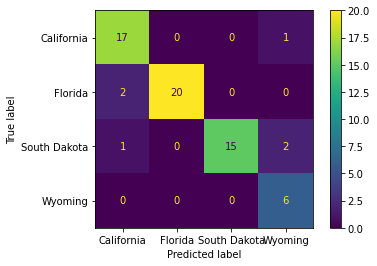

```python
##sclearn implementation
dt = DecisionTreeClassifier(random_state=RSEED)
# define parameter grid
parameters_grid = {
    'max_depth': [2,4,5,6,7],
    'min_samples_leaf': [2,4,6,8],
    'min_samples_split': [2, 4, 8],
}

# define grid search
grid_search = GridSearchCV(estimator=dt, param_grid=parameters_grid, cv=10)

# fit estimator
start_time = time.time()
grid_search.fit(X_cls_train, y_cls_train)
print("building classify tree ended in %s seconds" % (time.time() - start_time))
# get best estimator
best = grid_search.best_estimator_

# print best parameters
print(pd.DataFrame.from_dict(grid_search.best_params_, orient='index', columns=['Selected Value']).T)
# predict
y_pred = best.predict(X_cls_test)

#evaluating
# calculate accuracy
acc = round(accuracy_score(y_cls_test, y_pred), 3)

df = pd.DataFrame([acc]).T
df = df.rename(index={0: 'Decision Tree Classifier'}, columns={0: 'Accuracy'})
df
print(df)

#confusion_matrix
plot_confusion_matrix(grid_search, X_cls_test, y_cls_test)
plt.show()
```

As we can see the overall results of the model are good, lets print the features and their importance.

#### Feature Importance

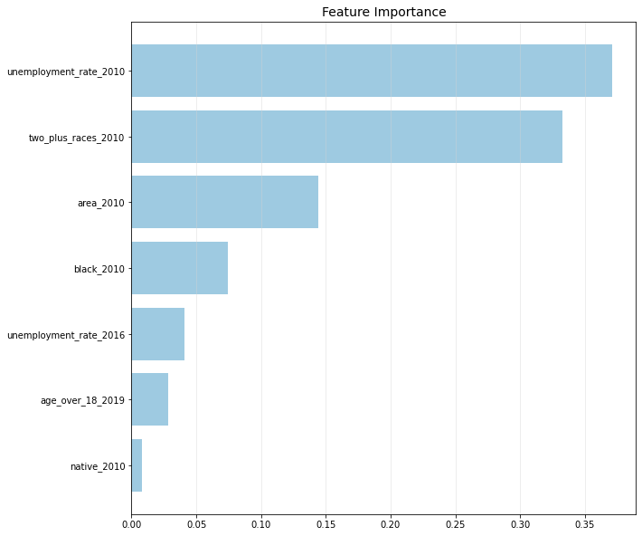

|  | Importance |
| --- | --- |
| Land Area | 0.000000 |
| civilian_labor_force_2012 | 0.000000 |
| employed_2012 | 0.000000 |
| unemployed_2012 | 0.000000 |
| unemployment_rate_2012 | 0.000000 |
| ... | ... |
| unemployment_rate_2016 | 0.041001 |
| black_2010 | 0.074555 |
| area_2010 | 0.144513 |
| two_plus_races_2010 | 0.332608 |
| unemployment_rate_2010 | 0.370923 |

188 rows × 1 columns

```python
feat_importance(grid_search, X_cls_train, y_cls_train)
```

All the features are from the county_complete data, because we were asked to use at least 1 feature  
from each of the three datasets, we will add two more one from each of the other 2.

#### selecting the high importance features and adding two more from the other datasets

```python
section_b_df
```

|  | FIPS | State | County | Land Area | fips_x | Male life expectancy (years) | Female life expectancy (years) | White male life expectancy (years) | White female life expectancy (years) | Rank (male) | ... | pop_2019 | two_plus_races_2019 | unemployment_rate_2019 | uninsured_2019 | uninsured_65_and_older_2019 | uninsured_under_19_2019 | uninsured_under_6_2019 | veterans_2019 | white_2019 | white_not_hispanic_2019 |
| --- | --- | --- | --- | --- | --- | --- | --- | --- | --- | --- | --- | --- | --- | --- | --- | --- | --- | --- | --- | --- | --- |
| 0 | 6001 | California | Alameda | 1910.100000 | 6001 | 77.700000 | 82.300000 | 77.300000 | 82.100000 | 152 | ... | 1656754.000000 | 6.500000 | 4.400000 | 4.400000 | 1.000000 | 2.100000 | 1.900000 | 3.700000 | 40.500000 | 31.400000 |
| 1 | 6003 | California | Alpine | 1913.100000 | 6003 | 77.000000 | 80.700000 | 77.000000 | 80.600000 | 285 | ... | 1039.000000 | 5.100000 | 15.600000 | 8.900000 | 0.000000 | 3.700000 | 0.000000 | 9.400000 | 57.700000 | 53.000000 |
| 2 | 6005 | California | Amador | 1534.700000 | 6005 | 76.300000 | 81.100000 | 76.500000 | 81.000000 | 480 | ... | 38429.000000 | 4.800000 | 6.600000 | 4.700000 | 0.000000 | 3.400000 | 5.100000 | 11.700000 | 86.700000 | 78.200000 |
| 3 | 6007 | California | Butte | 4246.600000 | 6007 | 74.000000 | 80.000000 | 73.900000 | 79.900000 | 1812 | ... | 225817.000000 | 6.100000 | 7.700000 | 6.200000 | 0.300000 | 3.200000 | 3.300000 | 7.900000 | 81.600000 | 72.000000 |
| 4 | 6009 | California | Calaveras | 2642.300000 | 6009 | 76.600000 | 81.600000 | 76.500000 | 81.500000 | 405 | ... | 45514.000000 | 5.200000 | 6.600000 | 4.400000 | 0.100000 | 0.700000 | 0.000000 | 11.900000 | 90.500000 | 80.900000 |
| ... | ... | ... | ... | ... | ... | ... | ... | ... | ... | ... | ... | ... | ... | ... | ... | ... | ... | ... | ... | ... | ... |
| 207 | 56037 | Wyoming | Sweetwater | 27003.000000 | 56037 | 74.800000 | 80.500000 | 74.800000 | 80.500000 | 1398 | ... | 43521.000000 | 2.300000 | 5.700000 | 11.300000 | 0.500000 | 9.200000 | 13.800000 | 8.600000 | 93.400000 | 79.600000 |
| 208 | 56039 | Wyoming | Teton | 10380.600000 | 56039 | 79.900000 | 84.700000 | 79.900000 | 84.700000 | 10 | ... | 23280.000000 | 0.700000 | 0.700000 | 12.700000 | 0.000000 | 10.100000 | 5.900000 | 5.300000 | 89.300000 | 81.300000 |
| 209 | 56041 | Wyoming | Uinta | 5391.700000 | 56041 | 75.700000 | 80.900000 | 75.600000 | 80.900000 | 896 | ... | 20479.000000 | 3.500000 | 5.500000 | 11.200000 | 0.600000 | 6.800000 | 1.800000 | 7.400000 | 93.400000 | 87.500000 |
| 210 | 56043 | Wyoming | Washakie | 5802.000000 | 56043 | 75.000000 | 80.600000 | 74.900000 | 80.600000 | 1302 | ... | 8027.000000 | 3.800000 | 4.100000 | 15.000000 | 1.500000 | 7.000000 | 7.800000 | 11.900000 | 89.700000 | 81.900000 |
| 211 | 56045 | Wyoming | Weston | 6210.600000 | 56045 | 75.900000 | 81.500000 | 75.900000 | 81.500000 | 727 | ... | 7049.000000 | 1.300000 | 4.000000 | 11.800000 | 0.000000 | 8.600000 | 7.100000 | 10.300000 | 97.400000 | 96.400000 |

212 rows × 193 columns

```python
section_b_df_for_scaling = section_b_df[['State','Land Area','Male life expectancy (years)','unemployment_rate_2010','two_plus_races_2010','area_2010','black_2010','unemployment_rate_2016','age_over_18_2019','native_2010']]
```

```python
section_b_df_for_scaling
```

|  | State | Land Area | Male life expectancy (years) | unemployment_rate_2010 | two_plus_races_2010 | area_2010 | black_2010 | unemployment_rate_2016 | age_over_18_2019 | native_2010 |
| --- | --- | --- | --- | --- | --- | --- | --- | --- | --- | --- |
| 0 | California | 1910.100000 | 77.700000 | 10.910000 | 6.000000 | 739.020000 | 12.600000 | 4.280000 | 79.200000 | 0.600000 |
| 1 | California | 1913.100000 | 77.000000 | 12.920000 | 2.400000 | 738.330000 | 0.000000 | 6.460000 | 80.700000 | 20.400000 |
| 2 | California | 1534.700000 | 76.300000 | 14.060000 | 3.600000 | 594.580000 | 2.500000 | 5.960000 | 84.800000 | 1.800000 |
| 3 | California | 4246.600000 | 74.000000 | 13.890000 | 4.700000 | 1636.460000 | 1.600000 | 6.610000 | 79.900000 | 2.000000 |
| 4 | California | 2642.300000 | 76.600000 | 14.440000 | 3.900000 | 1020.010000 | 0.800000 | 5.670000 | 82.800000 | 1.500000 |
| ... | ... | ... | ... | ... | ... | ... | ... | ... | ... | ... |
| 207 | Wyoming | 27003.000000 | 74.800000 | 6.600000 | 2.300000 | 10426.650000 | 1.000000 | 5.990000 | 73.500000 | 1.000000 |
| 208 | Wyoming | 10380.600000 | 79.900000 | 7.660000 | 1.600000 | 3995.380000 | 0.200000 | 3.420000 | 80.900000 | 0.500000 |
| 209 | Wyoming | 5391.700000 | 75.700000 | 7.030000 | 2.000000 | 2081.260000 | 0.300000 | 5.740000 | 70.800000 | 0.800000 |
| 210 | Wyoming | 5802.000000 | 75.000000 | 5.910000 | 2.400000 | 2238.550000 | 0.300000 | 4.690000 | 75.400000 | 1.100000 |
| 211 | Wyoming | 6210.600000 | 75.900000 | 4.830000 | 1.700000 | 2398.090000 | 0.300000 | 4.940000 | 79.000000 | 1.300000 |

212 rows × 10 columns

#### Performing standardization

Because most of the Dimension reduction algorithms are based on among other things on Euclidean distance  
we will perform standardization on our features to prevent from one feature to have more impact unwillingly.

```python
# performing standardization
sc = StandardScaler()
state = section_b_df_for_scaling[['State']]
section_b_df_for_scaling.drop(['State'], axis=1, inplace=True)
X_scaled = sc.fit_transform(section_b_df_for_scaling)
```

```python
X_scaled
```

```
array([[-0.48647164,  1.18521496,  0.34920323, ..., -0.32852612,
         0.30537758, -0.31212063],
       [-0.48593496,  0.86165738,  0.82048492, ...,  0.59948337,
         0.6261905 ,  1.10902868],
       [-0.55362845,  0.5380998 ,  1.08777902, ...,  0.38663716,
         1.50307916, -0.22599037],
       ...,
       [ 0.13636576,  0.26076473, -0.56053456, ...,  0.29298482,
        -1.49117478, -0.29776558],
       [ 0.20976597, -0.06279285, -0.82313929, ..., -0.15399223,
        -0.50734848, -0.27623302],
       [ 0.28286207,  0.35320976, -1.07636527, ..., -0.04756912,
         0.26260253, -0.26187798]])
```

#### Data Exploration , Visualization and Pre-Processing for Section C

**#Note: include also some Pre-Processing for Section D**

In this section we will use 1976-2020-house dataset and county_complete dataset.

```python
# import dataset
demog_df = pd.read_csv('data/GeneralDemographicData/county_complete.csv')
house_elections_df = pd.read_csv('data/USElectionResults19762020/1976-2020-house.csv')
```

```python
# look at 5 random observations
house_elections_df.head()
```

|  | year | state | state_po | state_fips | state_cen | state_ic | office | district | stage | runoff | special | candidate | party | writein | mode | candidatevotes | totalvotes | unofficial | version | fusion_ticket |
| --- | --- | --- | --- | --- | --- | --- | --- | --- | --- | --- | --- | --- | --- | --- | --- | --- | --- | --- | --- | --- |
| 0 | 1976 | ALABAMA | AL | 1 | 63 | 41 | US HOUSE | 1 | GEN | False | False | BILL DAVENPORT | DEMOCRAT | False | TOTAL | 58906 | 157170 | False | 20220331 | False |
| 1 | 1976 | ALABAMA | AL | 1 | 63 | 41 | US HOUSE | 1 | GEN | False | False | JACK EDWARDS | REPUBLICAN | False | TOTAL | 98257 | 157170 | False | 20220331 | False |
| 2 | 1976 | ALABAMA | AL | 1 | 63 | 41 | US HOUSE | 1 | GEN | False | False | WRITEIN | NaN | True | TOTAL | 7 | 157170 | False | 20220331 | False |
| 3 | 1976 | ALABAMA | AL | 1 | 63 | 41 | US HOUSE | 2 | GEN | False | False | J CAROLE KEAHEY | DEMOCRAT | False | TOTAL | 66288 | 156362 | False | 20220331 | False |
| 4 | 1976 | ALABAMA | AL | 1 | 63 | 41 | US HOUSE | 2 | GEN | False | False | WILLIAM L "BILL" DICKINSON | REPUBLICAN | False | TOTAL | 90069 | 156362 | False | 20220331 | False |

```python
# data shape (rows, columns)
house_elections_df.shape
```

```
(31103, 20)
```

```python
# variables data types
house_elections_df.dtypes
```

```
year               int64
state             object
state_po          object
state_fips         int64
state_cen          int64
state_ic           int64
office            object
district           int64
stage             object
runoff            object
special             bool
candidate         object
party             object
writein             bool
mode              object
candidatevotes     int64
totalvotes         int64
unofficial          bool
version            int64
fusion_ticket       bool
dtype: object
```

```python
# missing values by variable
house_elections_df.isnull().sum()
```

```
year                 0
state                0
state_po             0
state_fips           0
state_cen            0
state_ic             0
office               0
district             0
stage                0
runoff            8656
special              0
candidate            0
party             3620
writein              0
mode                 0
candidatevotes       0
totalvotes           0
unofficial           0
version              0
fusion_ticket        0
dtype: int64
```

```python
demog_df.isnull().sum()
```

```
fips                       0
state                      0
name                       0
pop2000                    3
pop2010                    0
                          ..
uninsured_under_19_2019    0
uninsured_under_6_2019     0
veterans_2019              0
white_2019                 0
white_not_hispanic_2019    0
Length: 188, dtype: int64
```

### Imputing missing vals

```python
# #we sperate the dataset to one for imputation with KNN and another that contains all the other feaures
to_impute = demog_df[['pop2000','pop2010','pop2011','pop2012','pop2013','pop2014','pop2015','pop2016','pop2017','age_under_18_2010']]
not_for_impute = demog_df.iloc[:,0:3]
demog_df = knn_imput(to_impute, not_for_impute)
```

```python
demog_df.isnull().sum()
```

```
fips                 0
state                0
name                 0
pop2000              0
pop2010              0
pop2011              0
pop2012              0
pop2013              0
pop2014              0
pop2015              0
pop2016              0
pop2017              0
age_under_18_2010    0
dtype: int64
```

#### study limitations

In section c we were asked to build a model whose training is 8 years prior to the test (2012, 2010).

A turnout in a particular district can be calculated as follows: totalvotes in the district (in a given year) / pop (population size in the district in that year) - age_under_18 (in the district in that year).

That is: the number of actual voters / the number of eligible voters.

The problem is that the relevant given population size is only for the years 2010, 2012. In addition, the relevant age_under_18 figure given to us is only for 2010.

Therefore in order to calculate the turnout we must create the following values for each district in the relevant years of the training database: General population size Percentage of people under the age of 18

To this end, we will estimate the change in the size of the population in the years 2010-2017, and make an average of the percentage change. Finally, we will contain the percentage of change cumulatively from 2000 to 2010.

We will also use the percentage of people under the age of 18 as a regular for all years in a training date.

Missing data the could have made estimate more accurate: pop(2002-2008), age_under_18(2002-2008,2012)

```python
demog_df.head()
```

|  | fips | state | name | pop2000 | pop2010 | pop2011 | pop2012 | pop2013 | pop2014 | pop2015 | pop2016 | pop2017 | age_under_18_2010 |
| --- | --- | --- | --- | --- | --- | --- | --- | --- | --- | --- | --- | --- | --- |
| 0 | 1001 | Alabama | Autauga County | 43671.000000 | 54571.000000 | 55199.000000 | 54927.000000 | 54695.000000 | 54864.000000 | 54838.000000 | 55278.000000 | 55504.000000 | 26.800000 |
| 1 | 1003 | Alabama | Baldwin County | 140415.000000 | 182265.000000 | 186534.000000 | 190048.000000 | 194736.000000 | 199064.000000 | 202863.000000 | 207509.000000 | 212628.000000 | 23.000000 |
| 2 | 1005 | Alabama | Barbour County | 29038.000000 | 27457.000000 | 27351.000000 | 27175.000000 | 26947.000000 | 26749.000000 | 26264.000000 | 25774.000000 | 25270.000000 | 21.900000 |
| 3 | 1007 | Alabama | Bibb County | 20826.000000 | 22915.000000 | 22745.000000 | 22658.000000 | 22503.000000 | 22533.000000 | 22561.000000 | 22633.000000 | 22668.000000 | 22.700000 |
| 4 | 1009 | Alabama | Blount County | 51024.000000 | 57322.000000 | 57562.000000 | 57595.000000 | 57623.000000 | 57546.000000 | 57590.000000 | 57562.000000 | 58013.000000 | 24.600000 |

```python
general_demog_df_sec_c = demog_df.copy(deep=True)

#average population change in 2010-2017
general_demog_df_sec_c = general_demog_df_sec_c.assign(pop_groth_per=lambda x: (x['pop2011']/ x['pop2010'] +                                                                                     x['pop2012']/ x['pop2011']
                                                                                + x['pop2013']/ x['pop2012'] + x['pop2014']/ x['pop2013']
                                                                               + x['pop2015']/ x['pop2014'] + x['pop2016']/ x['pop2015'] + x['pop2017']/ x['pop2016'] ) / 7 )

#estimate population
general_demog_df_sec_c = general_demog_df_sec_c.assign(pop2002=lambda x: x['pop2000']* x['pop_groth_per']**2)
general_demog_df_sec_c = general_demog_df_sec_c.assign(pop2004=lambda x: x['pop2002']* x['pop_groth_per']**2)
general_demog_df_sec_c = general_demog_df_sec_c.assign(pop2006=lambda x: x['pop2004']* x['pop_groth_per']**2)
general_demog_df_sec_c = general_demog_df_sec_c.assign(pop2008=lambda x: x['pop2006']* x['pop_groth_per']**2)

#estimate eligible voters
general_demog_df_sec_c = general_demog_df_sec_c.assign(eligible_voters_2002=lambda x: (x['pop2002'] * (100-x['age_under_18_2010']))/100)
general_demog_df_sec_c = general_demog_df_sec_c.assign(eligible_voters_2004=lambda x: (x['pop2004'] * (100-x['age_under_18_2010']))/100)
general_demog_df_sec_c = general_demog_df_sec_c.assign(eligible_voters_2006=lambda x: (x['pop2006'] * (100-x['age_under_18_2010']))/100)
general_demog_df_sec_c = general_demog_df_sec_c.assign(eligible_voters_2008=lambda x: (x['pop2008'] * (100-x['age_under_18_2010']))/100)
general_demog_df_sec_c = general_demog_df_sec_c.assign(eligible_voters_2010=lambda x: (x['pop2010'] * (100-x['age_under_18_2010']))/100)
general_demog_df_sec_c = general_demog_df_sec_c.assign(eligible_voters_2012=lambda x: (x['pop2012'] * (100-x['age_under_18_2010']))/100)

general_demog_df_sec_c
```

|  | fips | state | name | pop2000 | pop2010 | pop2011 | pop2012 | pop2013 | pop2014 | pop2015 | ... | pop2002 | pop2004 | pop2006 | pop2008 | eligible_voters_2002 | eligible_voters_2004 | eligible_voters_2006 | eligible_voters_2008 | eligible_voters_2010 | eligible_voters_2012 |
| --- | --- | --- | --- | --- | --- | --- | --- | --- | --- | --- | --- | --- | --- | --- | --- | --- | --- | --- | --- | --- | --- |
| 0 | 1001 | Alabama | Autauga County | 43671.000000 | 54571.000000 | 55199.000000 | 54927.000000 | 54695.000000 | 54864.000000 | 54838.000000 | ... | 43884.431418 | 44098.905931 | 44314.428636 | 44531.004656 | 32123.403798 | 32280.399142 | 32438.161762 | 32596.695408 | 39945.972000 | 40206.564000 |
| 1 | 1003 | Alabama | Baldwin County | 140415.000000 | 182265.000000 | 186534.000000 | 190048.000000 | 194736.000000 | 199064.000000 | 202863.000000 | ... | 146735.361283 | 153340.214726 | 160242.365894 | 167455.196754 | 112986.228188 | 118071.965339 | 123386.621738 | 128940.501500 | 140344.050000 | 146336.960000 |
| 2 | 1005 | Alabama | Barbour County | 29038.000000 | 27457.000000 | 27351.000000 | 27175.000000 | 26947.000000 | 26749.000000 | 26264.000000 | ... | 28358.582216 | 27695.061137 | 27047.064819 | 26414.230021 | 22148.052710 | 21629.842748 | 21123.757624 | 20629.513647 | 21443.917000 | 21223.675000 |
| 3 | 1007 | Alabama | Bibb County | 20826.000000 | 22915.000000 | 22745.000000 | 22658.000000 | 22503.000000 | 22533.000000 | 22561.000000 | ... | 20761.958491 | 20698.113914 | 20634.465665 | 20571.013138 | 16048.993914 | 15999.642056 | 15950.441959 | 15901.393156 | 17713.295000 | 17514.634000 |
| 4 | 1009 | Alabama | Blount County | 51024.000000 | 57322.000000 | 57562.000000 | 57595.000000 | 57623.000000 | 57546.000000 | 57590.000000 | ... | 51199.432417 | 51375.468012 | 51552.108858 | 51729.357037 | 38604.372043 | 38737.102881 | 38870.290079 | 39003.935206 | 43220.788000 | 43426.630000 |
| ... | ... | ... | ... | ... | ... | ... | ... | ... | ... | ... | ... | ... | ... | ... | ... | ... | ... | ... | ... | ... | ... |
| 3137 | 56037 | Wyoming | Sweetwater County | 37613.000000 | 43806.000000 | 44013.000000 | 45042.000000 | 45145.000000 | 44981.000000 | 44732.000000 | ... | 37551.409853 | 37489.920558 | 37428.531950 | 37367.243864 | 27374.977783 | 27330.152087 | 27285.399792 | 27240.720777 | 31934.574000 | 32835.618000 |
| 3138 | 56039 | Wyoming | Teton County | 18251.000000 | 21294.000000 | 21476.000000 | 21709.000000 | 22326.000000 | 22817.000000 | 23029.000000 | ... | 18719.764771 | 19200.569452 | 19693.723282 | 20199.543439 | 15144.289700 | 15533.260687 | 15932.222135 | 16341.430642 | 17226.846000 | 17562.581000 |
| 3139 | 56041 | Wyoming | Uinta County | 19742.000000 | 21118.000000 | 20899.000000 | 20999.000000 | 20960.000000 | 20845.000000 | 20780.000000 | ... | 19574.284209 | 19407.993227 | 19243.114951 | 19079.637378 | 13662.850378 | 13546.779273 | 13431.694236 | 13317.586890 | 14740.364000 | 14657.302000 |
| 3140 | 56043 | Wyoming | Washakie County | 8289.000000 | 8533.000000 | 8460.000000 | 8421.000000 | 8427.000000 | 8288.000000 | 8296.000000 | ... | 8156.567651 | 8026.251157 | 7898.016715 | 7771.831058 | 6076.642900 | 5979.557112 | 5884.022452 | 5790.014138 | 6357.085000 | 6273.645000 |
| 3141 | 56045 | Wyoming | Weston County | 6644.000000 | 7208.000000 | 7141.000000 | 7074.000000 | 7136.000000 | 7142.000000 | 7181.000000 | ... | 6570.373751 | 6497.563399 | 6425.559904 | 6354.354323 | 5138.032273 | 5081.094578 | 5024.787845 | 4969.105081 | 5636.656000 | 5531.868000 |

3142 rows × 24 columns

Create new dataset for section C Grouping the Data by States.

```python
#selecting relevant features for estimating eligible_voters
section_c_df = general_demog_df_sec_c[['fips','state', 'eligible_voters_2002', 'eligible_voters_2004', 'eligible_voters_2006', 'eligible_voters_2008', 'eligible_voters_2010',
                                       'eligible_voters_2012']]
#grouping counties by state
section_c_df_groupedby = section_c_df.groupby(['state'])

section_c_df_after_arrange = pd.DataFrame()
#estimating eligible_voters for 2002-2012
for key,item in section_c_df_groupedby:
    counties_per_state = section_c_df_groupedby.get_group(key)
    counties_per_state['eligible_voters_2002'] = counties_per_state['eligible_voters_2002'].sum()
    counties_per_state['eligible_voters_2004'] = counties_per_state['eligible_voters_2004'].sum()
    counties_per_state['eligible_voters_2006'] = counties_per_state['eligible_voters_2006'].sum()
    counties_per_state['eligible_voters_2008'] = counties_per_state['eligible_voters_2008'].sum()
    counties_per_state['eligible_voters_2010'] = counties_per_state['eligible_voters_2010'].sum()
    counties_per_state['eligible_voters_2012'] = counties_per_state['eligible_voters_2012'].sum()
    section_c_df_after_arrange = section_c_df_after_arrange.append(counties_per_state.iloc[0:1,1:])


section_c_df_after_arrange
```

|  | state | eligible_voters_2002 | eligible_voters_2004 | eligible_voters_2006 | eligible_voters_2008 | eligible_voters_2010 | eligible_voters_2012 |
| --- | --- | --- | --- | --- | --- | --- | --- |
| 0 | Alabama | 3407064.948638 | 3421131.667825 | 3436141.793876 | 3452116.232615 | 3647015.426000 | 3673062.870000 |
| 67 | Alaska | 469246.783641 | 473782.639512 | 478493.590749 | 483386.719849 | 522764.761000 | 537896.915155 |
| 96 | Arizona | 3923909.175272 | 4026143.638781 | 4131736.452722 | 4240801.031909 | 4763137.425000 | 4875649.744000 |
| 111 | Arkansas | 2033696.216233 | 2044602.720067 | 2056558.325933 | 2069586.387545 | 2204349.952000 | 2228907.414000 |
| 186 | California | 25896993.818335 | 26332541.736953 | 26776883.190700 | 27230209.694857 | 27955225.324000 | 28529024.711000 |
| 244 | Colorado | 3396153.312380 | 3499751.622614 | 3607317.149115 | 3719009.376253 | 3803029.582000 | 3920909.386000 |
| 308 | Connecticut | 2629070.334792 | 2631891.131583 | 2634812.020347 | 2637833.430285 | 2756822.863000 | 2774621.582000 |
| 316 | Delaware | 615532.835786 | 627323.945769 | 639419.476112 | 651829.085858 | 692374.102000 | 707000.678000 |
| 319 | District of Columbia | 495764.047643 | 516399.614021 | 537894.110371 | 560283.288593 | 500633.536000 | 528844.160000 |
| 320 | Florida | 12969398.831172 | 13367715.297103 | 13780667.962665 | 14208876.668229 | 14797996.081000 | 15219915.359000 |
| 387 | Georgia | 6213465.298559 | 6333471.060757 | 6457978.063927 | 6587153.134514 | 7196255.982000 | 7361258.131000 |
| 546 | Hawaii | 953939.178981 | 966928.731003 | 980119.470674 | 993514.926336 | 1056447.930000 | 1081666.863000 |
| 551 | Idaho | 964630.964727 | 988324.045918 | 1012890.627794 | 1038364.840438 | 1138551.605000 | 1158123.382000 |
| 595 | Illinois | 9402367.637989 | 9391916.137618 | 9381924.759040 | 9372388.136365 | 9702217.388000 | 9737722.962000 |
| 697 | Indiana | 4606841.723505 | 4637040.144684 | 4668309.217866 | 4700678.743246 | 4874940.856000 | 4912954.669000 |
| 789 | Iowa | 2244213.847609 | 2260494.966980 | 2277672.241831 | 2295779.595380 | 2318521.906000 | 2339560.846000 |
| 888 | Kansas | 2014387.988318 | 2024157.830227 | 2034377.398237 | 2045051.634089 | 2126310.645000 | 2150214.063000 |
| 993 | Kentucky | 3109849.142086 | 3129377.170506 | 3149742.362212 | 3170955.920024 | 3315705.715000 | 3349284.545000 |
| 1113 | Louisiana | 3407734.949738 | 3442388.805637 | 3478579.632356 | 3516366.288186 | 3415128.768000 | 3467651.854000 |
| 1177 | Maine | 1012825.545232 | 1014263.190831 | 1015771.448852 | 1017350.356069 | 1053786.139000 | 1053546.900000 |
| 1193 | Maryland | 4110726.794339 | 4163806.349696 | 4218067.100290 | 4273535.113443 | 4419982.798000 | 4509583.621000 |
| 1217 | Massachusetts | 5040483.215453 | 5107883.296513 | 5176557.021037 | 5246530.726173 | 5129178.243000 | 5217586.789000 |
| 1231 | Michigan | 7588858.430938 | 7600959.948631 | 7614111.048151 | 7628319.143510 | 7539113.448000 | 7541605.488000 |
| 1314 | Minnesota | 3787786.989771 | 3840074.205124 | 3893607.156636 | 3948412.396302 | 4019358.659000 | 4074790.040000 |
| 1401 | Mississippi | 2120208.564138 | 2119984.855588 | 2120414.080415 | 2121499.646216 | 2211793.850000 | 2223666.383000 |
| 1483 | Missouri | 4286889.344077 | 4307664.915551 | 4329150.247285 | 4351358.499518 | 4563564.750000 | 4589606.198000 |
| 1598 | Montana | 708870.064854 | 720227.629901 | 731938.917632 | 744017.079631 | 765818.941000 | 776652.679000 |
| 1654 | Nebraska | 1298358.397310 | 1314940.233600 | 1332080.516125 | 1349793.659704 | 1366784.812000 | 1387838.370000 |
| 1747 | Nevada | 1551717.456876 | 1597354.474422 | 1644537.297036 | 1693318.409110 | 2036196.102000 | 2075009.663000 |
| 1764 | New Hampshire | 971481.812631 | 976891.602439 | 982361.255675 | 987891.246728 | 1029358.942000 | 1032756.512000 |
| 1774 | New Jersey | 6480778.497210 | 6525518.513814 | 6571069.093300 | 6617442.370683 | 6725881.588000 | 6795493.464000 |
| 1795 | New Mexico | 1365578.435170 | 1369958.297400 | 1374510.714121 | 1379235.763932 | 1540495.615000 | 1558524.974000 |
| 1828 | New York | 14843950.136139 | 14945338.718570 | 15048672.662577 | 15153976.451632 | 15052686.573000 | 15245432.927000 |
| 1890 | North Carolina | 6247142.591825 | 6366365.070017 | 6490600.314025 | 6620051.189991 | 7253862.470000 | 7418332.430000 |
| 1990 | North Dakota | 514157.370655 | 529967.160210 | 546925.453027 | 565154.045981 | 522680.408000 | 544867.650000 |
| 2043 | Ohio | 8692723.612565 | 8710095.781078 | 8728865.309105 | 8749061.710477 | 8806348.929000 | 8813240.713000 |
| 2131 | Oklahoma | 2627600.267825 | 2660472.510580 | 2694447.129761 | 2729553.102091 | 2821737.907000 | 2869587.679000 |
| 2208 | Oregon | 2708254.222491 | 2767890.690582 | 2829122.414896 | 2891996.142387 | 2965237.925000 | 3013587.496000 |
| 2244 | Pennsylvania | 9606224.800747 | 9624119.650854 | 9642790.013559 | 9662237.360838 | 9909701.783000 | 9960080.622000 |
| 2311 | Rhode Island | 826593.466415 | 828137.085380 | 829696.243692 | 831270.980495 | 828362.609000 | 828472.371000 |
| 2316 | South Carolina | 3140883.935179 | 3209521.190822 | 3281294.200237 | 3356338.262714 | 3545119.612000 | 3616897.296000 |
| 2362 | South Dakota | 577131.200851 | 586715.200168 | 596620.318388 | 606858.737051 | 611393.696000 | 624948.145000 |
| 2428 | Tennessee | 4414051.114106 | 4478608.004026 | 4545511.002726 | 4614856.407048 | 4849206.849000 | 4927940.353000 |
| 2523 | Texas | 15667355.655381 | 16166568.432971 | 16688084.394457 | 17233040.971654 | 18283921.251000 | 18957159.610000 |
| 2777 | Utah | 1582699.410955 | 1633629.884366 | 1686457.051985 | 1741258.406530 | 1893025.691000 | 1954643.678000 |
| 2806 | Vermont | 482472.008037 | 481867.043395 | 481301.588121 | 480775.575572 | 496434.480000 | 496291.822000 |
| 2820 | Virginia | 5526868.753542 | 5604969.935738 | 5686054.109491 | 5770229.940762 | 6142274.652000 | 6288224.117000 |
| 2953 | Washington | 4637862.930962 | 4766763.797509 | 4899693.540884 | 5036784.914013 | 5143923.413000 | 5270925.714000 |
| 2992 | West Virginia | 1420597.306007 | 1410443.351791 | 1400677.876722 | 1391296.038982 | 1465534.552000 | 1467475.565000 |
| 3047 | Wisconsin | 4122353.502104 | 4143116.845812 | 4164325.268700 | 4185987.346289 | 4348281.422000 | 4374271.822000 |
| 3119 | Wyoming | 378569.468910 | 381666.982633 | 384835.551681 | 388076.322566 | 428220.153000 | 438107.792000 |

```python
#Convert the State values to string consist only from uppercase letters for the later merging
section_c_df_after_arrange['state'] =  section_c_df_after_arrange['state'].str.upper()
```

```python
section_c_df_after_arrange
```

|  | state | eligible_voters_2002 | eligible_voters_2004 | eligible_voters_2006 | eligible_voters_2008 | eligible_voters_2010 | eligible_voters_2012 |
| --- | --- | --- | --- | --- | --- | --- | --- |
| 0 | ALABAMA | 3407064.948638 | 3421131.667825 | 3436141.793876 | 3452116.232615 | 3647015.426000 | 3673062.870000 |
| 67 | ALASKA | 469246.783641 | 473782.639512 | 478493.590749 | 483386.719849 | 522764.761000 | 537896.915155 |
| 96 | ARIZONA | 3923909.175272 | 4026143.638781 | 4131736.452722 | 4240801.031909 | 4763137.425000 | 4875649.744000 |
| 111 | ARKANSAS | 2033696.216233 | 2044602.720067 | 2056558.325933 | 2069586.387545 | 2204349.952000 | 2228907.414000 |
| 186 | CALIFORNIA | 25896993.818335 | 26332541.736953 | 26776883.190700 | 27230209.694857 | 27955225.324000 | 28529024.711000 |
| 244 | COLORADO | 3396153.312380 | 3499751.622614 | 3607317.149115 | 3719009.376253 | 3803029.582000 | 3920909.386000 |
| 308 | CONNECTICUT | 2629070.334792 | 2631891.131583 | 2634812.020347 | 2637833.430285 | 2756822.863000 | 2774621.582000 |
| 316 | DELAWARE | 615532.835786 | 627323.945769 | 639419.476112 | 651829.085858 | 692374.102000 | 707000.678000 |
| 319 | DISTRICT OF COLUMBIA | 495764.047643 | 516399.614021 | 537894.110371 | 560283.288593 | 500633.536000 | 528844.160000 |
| 320 | FLORIDA | 12969398.831172 | 13367715.297103 | 13780667.962665 | 14208876.668229 | 14797996.081000 | 15219915.359000 |
| 387 | GEORGIA | 6213465.298559 | 6333471.060757 | 6457978.063927 | 6587153.134514 | 7196255.982000 | 7361258.131000 |
| 546 | HAWAII | 953939.178981 | 966928.731003 | 980119.470674 | 993514.926336 | 1056447.930000 | 1081666.863000 |
| 551 | IDAHO | 964630.964727 | 988324.045918 | 1012890.627794 | 1038364.840438 | 1138551.605000 | 1158123.382000 |
| 595 | ILLINOIS | 9402367.637989 | 9391916.137618 | 9381924.759040 | 9372388.136365 | 9702217.388000 | 9737722.962000 |
| 697 | INDIANA | 4606841.723505 | 4637040.144684 | 4668309.217866 | 4700678.743246 | 4874940.856000 | 4912954.669000 |
| 789 | IOWA | 2244213.847609 | 2260494.966980 | 2277672.241831 | 2295779.595380 | 2318521.906000 | 2339560.846000 |
| 888 | KANSAS | 2014387.988318 | 2024157.830227 | 2034377.398237 | 2045051.634089 | 2126310.645000 | 2150214.063000 |
| 993 | KENTUCKY | 3109849.142086 | 3129377.170506 | 3149742.362212 | 3170955.920024 | 3315705.715000 | 3349284.545000 |
| 1113 | LOUISIANA | 3407734.949738 | 3442388.805637 | 3478579.632356 | 3516366.288186 | 3415128.768000 | 3467651.854000 |
| 1177 | MAINE | 1012825.545232 | 1014263.190831 | 1015771.448852 | 1017350.356069 | 1053786.139000 | 1053546.900000 |
| 1193 | MARYLAND | 4110726.794339 | 4163806.349696 | 4218067.100290 | 4273535.113443 | 4419982.798000 | 4509583.621000 |
| 1217 | MASSACHUSETTS | 5040483.215453 | 5107883.296513 | 5176557.021037 | 5246530.726173 | 5129178.243000 | 5217586.789000 |
| 1231 | MICHIGAN | 7588858.430938 | 7600959.948631 | 7614111.048151 | 7628319.143510 | 7539113.448000 | 7541605.488000 |
| 1314 | MINNESOTA | 3787786.989771 | 3840074.205124 | 3893607.156636 | 3948412.396302 | 4019358.659000 | 4074790.040000 |
| 1401 | MISSISSIPPI | 2120208.564138 | 2119984.855588 | 2120414.080415 | 2121499.646216 | 2211793.850000 | 2223666.383000 |
| 1483 | MISSOURI | 4286889.344077 | 4307664.915551 | 4329150.247285 | 4351358.499518 | 4563564.750000 | 4589606.198000 |
| 1598 | MONTANA | 708870.064854 | 720227.629901 | 731938.917632 | 744017.079631 | 765818.941000 | 776652.679000 |
| 1654 | NEBRASKA | 1298358.397310 | 1314940.233600 | 1332080.516125 | 1349793.659704 | 1366784.812000 | 1387838.370000 |
| 1747 | NEVADA | 1551717.456876 | 1597354.474422 | 1644537.297036 | 1693318.409110 | 2036196.102000 | 2075009.663000 |
| 1764 | NEW HAMPSHIRE | 971481.812631 | 976891.602439 | 982361.255675 | 987891.246728 | 1029358.942000 | 1032756.512000 |
| 1774 | NEW JERSEY | 6480778.497210 | 6525518.513814 | 6571069.093300 | 6617442.370683 | 6725881.588000 | 6795493.464000 |
| 1795 | NEW MEXICO | 1365578.435170 | 1369958.297400 | 1374510.714121 | 1379235.763932 | 1540495.615000 | 1558524.974000 |
| 1828 | NEW YORK | 14843950.136139 | 14945338.718570 | 15048672.662577 | 15153976.451632 | 15052686.573000 | 15245432.927000 |
| 1890 | NORTH CAROLINA | 6247142.591825 | 6366365.070017 | 6490600.314025 | 6620051.189991 | 7253862.470000 | 7418332.430000 |
| 1990 | NORTH DAKOTA | 514157.370655 | 529967.160210 | 546925.453027 | 565154.045981 | 522680.408000 | 544867.650000 |
| 2043 | OHIO | 8692723.612565 | 8710095.781078 | 8728865.309105 | 8749061.710477 | 8806348.929000 | 8813240.713000 |
| 2131 | OKLAHOMA | 2627600.267825 | 2660472.510580 | 2694447.129761 | 2729553.102091 | 2821737.907000 | 2869587.679000 |
| 2208 | OREGON | 2708254.222491 | 2767890.690582 | 2829122.414896 | 2891996.142387 | 2965237.925000 | 3013587.496000 |
| 2244 | PENNSYLVANIA | 9606224.800747 | 9624119.650854 | 9642790.013559 | 9662237.360838 | 9909701.783000 | 9960080.622000 |
| 2311 | RHODE ISLAND | 826593.466415 | 828137.085380 | 829696.243692 | 831270.980495 | 828362.609000 | 828472.371000 |
| 2316 | SOUTH CAROLINA | 3140883.935179 | 3209521.190822 | 3281294.200237 | 3356338.262714 | 3545119.612000 | 3616897.296000 |
| 2362 | SOUTH DAKOTA | 577131.200851 | 586715.200168 | 596620.318388 | 606858.737051 | 611393.696000 | 624948.145000 |
| 2428 | TENNESSEE | 4414051.114106 | 4478608.004026 | 4545511.002726 | 4614856.407048 | 4849206.849000 | 4927940.353000 |
| 2523 | TEXAS | 15667355.655381 | 16166568.432971 | 16688084.394457 | 17233040.971654 | 18283921.251000 | 18957159.610000 |
| 2777 | UTAH | 1582699.410955 | 1633629.884366 | 1686457.051985 | 1741258.406530 | 1893025.691000 | 1954643.678000 |
| 2806 | VERMONT | 482472.008037 | 481867.043395 | 481301.588121 | 480775.575572 | 496434.480000 | 496291.822000 |
| 2820 | VIRGINIA | 5526868.753542 | 5604969.935738 | 5686054.109491 | 5770229.940762 | 6142274.652000 | 6288224.117000 |
| 2953 | WASHINGTON | 4637862.930962 | 4766763.797509 | 4899693.540884 | 5036784.914013 | 5143923.413000 | 5270925.714000 |
| 2992 | WEST VIRGINIA | 1420597.306007 | 1410443.351791 | 1400677.876722 | 1391296.038982 | 1465534.552000 | 1467475.565000 |
| 3047 | WISCONSIN | 4122353.502104 | 4143116.845812 | 4164325.268700 | 4185987.346289 | 4348281.422000 | 4374271.822000 |
| 3119 | WYOMING | 378569.468910 | 381666.982633 | 384835.551681 | 388076.322566 | 428220.153000 | 438107.792000 |

```python
house_elections_df.dtypes
```

```
year               int64
state             object
state_po          object
state_fips         int64
state_cen          int64
state_ic           int64
office            object
district           int64
stage             object
runoff            object
special             bool
candidate         object
party             object
writein             bool
mode              object
candidatevotes     int64
totalvotes         int64
unofficial          bool
version            int64
fusion_ticket       bool
dtype: object
```

Now we will select the relevant years from the house elections dataset

```python
#dropping not relevant features
house_elections_sec_c_df = house_elections_df.drop(['state_po', 'state_fips', 'state_cen', 'state_ic', 'office', 'district', 'mode', 'version', 'unofficial', 'version', 'fusion_ticket', 'candidate', 'stage'],axis=1,inplace=False)

#drop samples from years before 2002 or after 2012
house_elections_sec_c_df = house_elections_sec_c_df.loc[(house_elections_sec_c_df['year'] >=2002) & (house_elections_sec_c_df['year'] <= 2012) ]

house_elections_sec_c_df
```

|  | year | state | runoff | special | party | writein | candidatevotes | totalvotes |
| --- | --- | --- | --- | --- | --- | --- | --- | --- |
| 17025 | 2002 | ALABAMA | False | False | LIBERTARIAN | False | 2957 | 178687 |
| 17026 | 2002 | ALABAMA | False | False | REPUBLICAN | False | 108102 | 178687 |
| 17027 | 2002 | ALABAMA | False | False | DEMOCRAT | False | 67507 | 178687 |
| 17028 | 2002 | ALABAMA | False | False | NaN | True | 121 | 178687 |
| 17029 | 2002 | ALABAMA | False | False | DEMOCRAT | False | 55495 | 187965 |
| ... | ... | ... | ... | ... | ... | ... | ... | ... |
| 25475 | 2012 | WYOMING | NaN | False | CONSTITUTION | False | 4963 | 250700 |
| 25476 | 2012 | WYOMING | NaN | False | COUNTRY PARTY | False | 3775 | 250700 |
| 25477 | 2012 | WYOMING | NaN | False | NaN | False | 600 | 250700 |
| 25478 | 2012 | WYOMING | NaN | False | LIBERTARIAN | False | 8442 | 250700 |
| 25479 | 2012 | WYOMING | NaN | False | NaN | True | 416 | 250700 |

8455 rows × 8 columns

```python
#changing party value which is INDEPENDENT to Democrat(as we were asked to)
house_elections_sec_c_df.loc[house_elections_sec_c_df['party'] == 'INDEPENDENT', 'party'] = 'DEMOCRAT'
```

```python
#change the boolean values of runoff, special and writein to 1, 0
house_elections_sec_c_df['runoff'] = house_elections_sec_c_df.runoff.replace({True: 1, False: 0})
house_elections_sec_c_df['special'] = house_elections_sec_c_df.special.replace({True: 1, False: 0})
house_elections_sec_c_df['writein'] = house_elections_sec_c_df.writein.replace({True: 1, False: 0})
```

```python
house_elections_sec_c_df
```

|  | year | state | runoff | special | party | writein | candidatevotes | totalvotes |
| --- | --- | --- | --- | --- | --- | --- | --- | --- |
| 17025 | 2002 | ALABAMA | 0.000000 | 0 | LIBERTARIAN | 0 | 2957 | 178687 |
| 17026 | 2002 | ALABAMA | 0.000000 | 0 | REPUBLICAN | 0 | 108102 | 178687 |
| 17027 | 2002 | ALABAMA | 0.000000 | 0 | DEMOCRAT | 0 | 67507 | 178687 |
| 17028 | 2002 | ALABAMA | 0.000000 | 0 | NaN | 1 | 121 | 178687 |
| 17029 | 2002 | ALABAMA | 0.000000 | 0 | DEMOCRAT | 0 | 55495 | 187965 |
| ... | ... | ... | ... | ... | ... | ... | ... | ... |
| 25475 | 2012 | WYOMING | NaN | 0 | CONSTITUTION | 0 | 4963 | 250700 |
| 25476 | 2012 | WYOMING | NaN | 0 | COUNTRY PARTY | 0 | 3775 | 250700 |
| 25477 | 2012 | WYOMING | NaN | 0 | NaN | 0 | 600 | 250700 |
| 25478 | 2012 | WYOMING | NaN | 0 | LIBERTARIAN | 0 | 8442 | 250700 |
| 25479 | 2012 | WYOMING | NaN | 0 | NaN | 1 | 416 | 250700 |

8455 rows × 8 columns

```python
house_elections_sec_c_df.loc[house_elections_sec_c_df['runoff'] == 1]
```

|  | year | state | runoff | special | party | writein | candidatevotes | totalvotes |
| --- | --- | --- | --- | --- | --- | --- | --- | --- |
| 17537 | 2002 | LOUISIANA | 1.000000 | 0 | REPUBLICAN | 0 | 85744 | 172462 |
| 17540 | 2002 | LOUISIANA | 1.000000 | 0 | DEMOCRAT | 0 | 86718 | 172462 |

We can see that most of the not null samples of runoff feature are 0(False), and only 2 are 1(True). Because this features is mostly the same for most of the samples, imputing it will result with adding more 0 values and therefore this feature won't show distinguished patterns in the data, so we will remove it.

```python
house_elections_sec_c_df.drop('runoff',axis=1,inplace=True)
```

merging the datasets

```python
merged_section_C = pd.merge(house_elections_sec_c_df,section_c_df_after_arrange, how='inner', left_on=['state'], right_on = ['state'])
```

```python
merged_section_C
```

|  | year | state | special | party | writein | candidatevotes | totalvotes | eligible_voters_2002 | eligible_voters_2004 | eligible_voters_2006 | eligible_voters_2008 | eligible_voters_2010 | eligible_voters_2012 |
| --- | --- | --- | --- | --- | --- | --- | --- | --- | --- | --- | --- | --- | --- |
| 0 | 2002 | ALABAMA | 0 | LIBERTARIAN | 0 | 2957 | 178687 | 3407064.948638 | 3421131.667825 | 3436141.793876 | 3452116.232615 | 3647015.426000 | 3673062.870000 |
| 1 | 2002 | ALABAMA | 0 | REPUBLICAN | 0 | 108102 | 178687 | 3407064.948638 | 3421131.667825 | 3436141.793876 | 3452116.232615 | 3647015.426000 | 3673062.870000 |
| 2 | 2002 | ALABAMA | 0 | DEMOCRAT | 0 | 67507 | 178687 | 3407064.948638 | 3421131.667825 | 3436141.793876 | 3452116.232615 | 3647015.426000 | 3673062.870000 |
| 3 | 2002 | ALABAMA | 0 | NaN | 1 | 121 | 178687 | 3407064.948638 | 3421131.667825 | 3436141.793876 | 3452116.232615 | 3647015.426000 | 3673062.870000 |
| 4 | 2002 | ALABAMA | 0 | DEMOCRAT | 0 | 55495 | 187965 | 3407064.948638 | 3421131.667825 | 3436141.793876 | 3452116.232615 | 3647015.426000 | 3673062.870000 |
| ... | ... | ... | ... | ... | ... | ... | ... | ... | ... | ... | ... | ... | ... |
| 8450 | 2012 | WYOMING | 0 | CONSTITUTION | 0 | 4963 | 250700 | 378569.468910 | 381666.982633 | 384835.551681 | 388076.322566 | 428220.153000 | 438107.792000 |
| 8451 | 2012 | WYOMING | 0 | COUNTRY PARTY | 0 | 3775 | 250700 | 378569.468910 | 381666.982633 | 384835.551681 | 388076.322566 | 428220.153000 | 438107.792000 |
| 8452 | 2012 | WYOMING | 0 | NaN | 0 | 600 | 250700 | 378569.468910 | 381666.982633 | 384835.551681 | 388076.322566 | 428220.153000 | 438107.792000 |
| 8453 | 2012 | WYOMING | 0 | LIBERTARIAN | 0 | 8442 | 250700 | 378569.468910 | 381666.982633 | 384835.551681 | 388076.322566 | 428220.153000 | 438107.792000 |
| 8454 | 2012 | WYOMING | 0 | NaN | 1 | 416 | 250700 | 378569.468910 | 381666.982633 | 384835.551681 | 388076.322566 | 428220.153000 | 438107.792000 |

8455 rows × 13 columns

```python
#grouping counties by state and year
house_section_c_df_groupedby = merged_section_C.groupby(['state','year'])

house_section_c_df_after_arrange = pd.DataFrame()
#estimating vote turnouts and D/R class for each state for 2002-2012
for key,item in house_section_c_df_groupedby:
    counties_per_state_per_year = item
    #getting the matched eligible_voters column name
    column_name = return_column_name(key[1])

    #calc vote turnout
    counties_per_state_per_year['vote_turnouts'] = counties_per_state_per_year['candidatevotes'].sum()/counties_per_state_per_year[column_name].iloc[:1].values[0]

    #calc Republican votes
    counties_per_state_per_year['Republican_votes'] = counties_per_state_per_year.loc[counties_per_state_per_year['party'] == 'REPUBLICAN']['candidatevotes'].sum()
    #calc Democrats votes
    counties_per_state_per_year['Democrats_votes'] = counties_per_state_per_year.loc[counties_per_state_per_year['party'] == 'DEMOCRAT']['candidatevotes'].sum()

    # classify state as D or R based on total votes of each party
    if counties_per_state_per_year['Democrats_votes'].iloc[:1].values[0] >= counties_per_state_per_year['Republican_votes'].iloc[:1].values[0]:
        counties_per_state_per_year['party'] = 'D'
    else:
        counties_per_state_per_year['party'] = 'R'

    num_of_counties = len(counties_per_state_per_year)
    #calc the amount of special = 1
    counties_per_state_per_year['special'] = len(counties_per_state_per_year.loc[counties_per_state_per_year['special'] == 1]['special'])/num_of_counties
    #calc the amount of writein = 1
    counties_per_state_per_year['writein'] = len(counties_per_state_per_year.loc[counties_per_state_per_year['writein'] == 1]['writein'])/num_of_counties

    #add row to the arranged df
    house_section_c_df_after_arrange = house_section_c_df_after_arrange.append(counties_per_state_per_year.iloc[0:1,:])
```

```python
house_section_c_df_after_arrange
```

|  | year | state | special | party | writein | candidatevotes | totalvotes | eligible_voters_2002 | eligible_voters_2004 | eligible_voters_2006 | eligible_voters_2008 | eligible_voters_2010 | eligible_voters_2012 | vote_turnouts | Republican_votes | Democrats_votes |
| --- | --- | --- | --- | --- | --- | --- | --- | --- | --- | --- | --- | --- | --- | --- | --- | --- |
| 0 | 2002 | ALABAMA | 0.000000 | R | 0.280000 | 2957 | 178687 | 3407064.948638 | 3421131.667825 | 3436141.793876 | 3452116.232615 | 3647015.426000 | 3673062.870000 | 0.372403 | 694606 | 507117 |
| 25 | 2004 | ALABAMA | 0.000000 | R | 0.350000 | 161067 | 255164 | 3407064.948638 | 3421131.667825 | 3436141.793876 | 3452116.232615 | 3647015.426000 | 3673062.870000 | 0.524025 | 1079657 | 708425 |
| 45 | 2006 | ALABAMA | 0.000000 | R | 0.368421 | 112944 | 165841 | 3407064.948638 | 3421131.667825 | 3436141.793876 | 3452116.232615 | 3647015.426000 | 3673062.870000 | 0.331812 | 627501 | 505460 |
| 64 | 2008 | ALABAMA | 0.000000 | R | 0.388889 | 210660 | 214367 | 3407064.948638 | 3421131.667825 | 3436141.793876 | 3452116.232615 | 3647015.426000 | 3673062.870000 | 0.537429 | 1120903 | 718367 |
| 82 | 2010 | ALABAMA | 0.000000 | R | 0.368421 | 26357 | 156281 | 3407064.948638 | 3421131.667825 | 3436141.793876 | 3452116.232615 | 3647015.426000 | 3673062.870000 | 0.375032 | 914445 | 418957 |
| ... | ... | ... | ... | ... | ... | ... | ... | ... | ... | ... | ... | ... | ... | ... | ... | ... |
| 8425 | 2004 | WYOMING | 0.000000 | R | 0.200000 | 132107 | 239163 | 378569.468910 | 381666.982633 | 384835.551681 | 388076.322566 | 428220.153000 | 438107.792000 | 0.626627 | 132107 | 99989 |
| 8430 | 2006 | WYOMING | 0.000000 | R | 0.166667 | 93336 | 196215 | 378569.468910 | 381666.982633 | 384835.551681 | 388076.322566 | 428220.153000 | 438107.792000 | 0.509867 | 93336 | 92324 |
| 8436 | 2008 | WYOMING | 0.000000 | R | 0.200000 | 131244 | 249575 | 378569.468910 | 381666.982633 | 384835.551681 | 388076.322566 | 428220.153000 | 438107.792000 | 0.643108 | 131244 | 106758 |
| 8441 | 2010 | WYOMING | 0.000000 | R | 0.166667 | 131661 | 190822 | 378569.468910 | 381666.982633 | 384835.551681 | 388076.322566 | 428220.153000 | 438107.792000 | 0.445617 | 131661 | 45768 |
| 8447 | 2012 | WYOMING | 0.000000 | R | 0.125000 | 8479 | 250700 | 378569.468910 | 381666.982633 | 384835.551681 | 388076.322566 | 428220.153000 | 438107.792000 | 0.572234 | 166452 | 57573 |

300 rows × 16 columns

```python
sec_c_df = house_section_c_df_after_arrange.copy(deep=True)
```

```python
sec_c_df.drop(['candidatevotes','totalvotes','Republican_votes','Democrats_votes'],axis=1,inplace=True)
```

```python
sec_c_df
```

|  | year | state | special | party | writein | eligible_voters_2002 | eligible_voters_2004 | eligible_voters_2006 | eligible_voters_2008 | eligible_voters_2010 | eligible_voters_2012 | vote_turnouts |
| --- | --- | --- | --- | --- | --- | --- | --- | --- | --- | --- | --- | --- |
| 0 | 2002 | ALABAMA | 0.000000 | R | 0.280000 | 3407064.948638 | 3421131.667825 | 3436141.793876 | 3452116.232615 | 3647015.426000 | 3673062.870000 | 0.372403 |
| 25 | 2004 | ALABAMA | 0.000000 | R | 0.350000 | 3407064.948638 | 3421131.667825 | 3436141.793876 | 3452116.232615 | 3647015.426000 | 3673062.870000 | 0.524025 |
| 45 | 2006 | ALABAMA | 0.000000 | R | 0.368421 | 3407064.948638 | 3421131.667825 | 3436141.793876 | 3452116.232615 | 3647015.426000 | 3673062.870000 | 0.331812 |
| 64 | 2008 | ALABAMA | 0.000000 | R | 0.388889 | 3407064.948638 | 3421131.667825 | 3436141.793876 | 3452116.232615 | 3647015.426000 | 3673062.870000 | 0.537429 |
| 82 | 2010 | ALABAMA | 0.000000 | R | 0.368421 | 3407064.948638 | 3421131.667825 | 3436141.793876 | 3452116.232615 | 3647015.426000 | 3673062.870000 | 0.375032 |
| ... | ... | ... | ... | ... | ... | ... | ... | ... | ... | ... | ... | ... |
| 8425 | 2004 | WYOMING | 0.000000 | R | 0.200000 | 378569.468910 | 381666.982633 | 384835.551681 | 388076.322566 | 428220.153000 | 438107.792000 | 0.626627 |
| 8430 | 2006 | WYOMING | 0.000000 | R | 0.166667 | 378569.468910 | 381666.982633 | 384835.551681 | 388076.322566 | 428220.153000 | 438107.792000 | 0.509867 |
| 8436 | 2008 | WYOMING | 0.000000 | R | 0.200000 | 378569.468910 | 381666.982633 | 384835.551681 | 388076.322566 | 428220.153000 | 438107.792000 | 0.643108 |
| 8441 | 2010 | WYOMING | 0.000000 | R | 0.166667 | 378569.468910 | 381666.982633 | 384835.551681 | 388076.322566 | 428220.153000 | 438107.792000 | 0.445617 |
| 8447 | 2012 | WYOMING | 0.000000 | R | 0.125000 | 378569.468910 | 381666.982633 | 384835.551681 | 388076.322566 | 428220.153000 | 438107.792000 | 0.572234 |

300 rows × 12 columns

### Checking votes turnouts Distribution

As we know if our target feature(vote_turnouts) data is very positive skewed that will cause problem to  
regression models, because they will be trained mostly on averaged or small data, and won't be able to  
predict properly higher vote_turnouts. The same problem happen when the data is very negative skewed.  
There for we will check votes turnouts distribution.

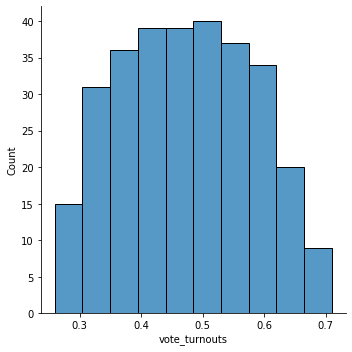

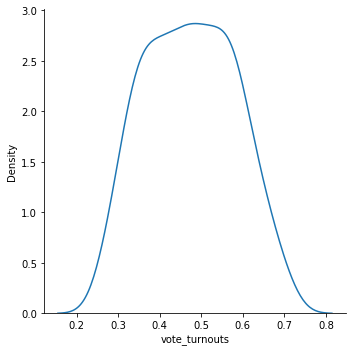

```python
sns.displot(data=house_section_c_df_after_arrange.loc[:,'vote_turnouts'])
sns.displot(data=house_section_c_df_after_arrange.loc[:,'vote_turnouts'], kind="kde")
```

As we can see the distribution is close to symmetric, so we won't have to apply normalization method on the data.

#### Checking for outliers

Outliers can have bad influence on the results of a regression model because they highly effect  
Statistical indices like the mean, that is used to estimate predictions  
in many supervised ML models.  
Therefor lets print a boxplot and see if there are any outliers in the data.  
those outliers, if exist can be recognize as data points beyond Q1-1.5*IQR or Q3+1.5*IQR.

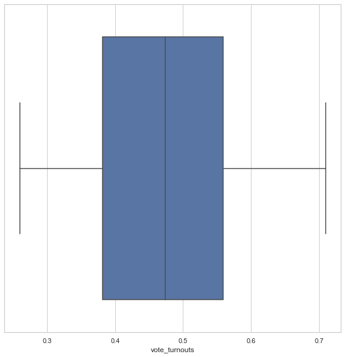

```python
# To deal with outliers, we will need to find them.
# Let's look at the data in the box plot.
plt.figure(figsize=(10, 10))
sns.set_theme(style="whitegrid")
ax = sns.boxplot(x=house_section_c_df_after_arrange['vote_turnouts'])
```

### Collecting features for predicting votes turnouts for the house elections

We will add a number of features from the presidential election, and from the Senate election.

### Presidential elections

```python
# import dataset
president_df = pd.read_csv('data/USElectionResults19762020/1976-2020-president.csv')
```

printing head

```python
president_df.head()
```

|  | year | state | state_po | state_fips | state_cen | state_ic | office | candidate | party_detailed | writein | candidatevotes | totalvotes | version | notes | party_simplified |
| --- | --- | --- | --- | --- | --- | --- | --- | --- | --- | --- | --- | --- | --- | --- | --- |
| 0 | 1976 | ALABAMA | AL | 1 | 63 | 41 | US PRESIDENT | CARTER, JIMMY | DEMOCRAT | False | 659170 | 1182850 | 20210113 | NaN | DEMOCRAT |
| 1 | 1976 | ALABAMA | AL | 1 | 63 | 41 | US PRESIDENT | FORD, GERALD | REPUBLICAN | False | 504070 | 1182850 | 20210113 | NaN | REPUBLICAN |
| 2 | 1976 | ALABAMA | AL | 1 | 63 | 41 | US PRESIDENT | MADDOX, LESTER | AMERICAN INDEPENDENT PARTY | False | 9198 | 1182850 | 20210113 | NaN | OTHER |
| 3 | 1976 | ALABAMA | AL | 1 | 63 | 41 | US PRESIDENT | BUBAR, BENJAMIN ""BEN"" | PROHIBITION | False | 6669 | 1182850 | 20210113 | NaN | OTHER |
| 4 | 1976 | ALABAMA | AL | 1 | 63 | 41 | US PRESIDENT | HALL, GUS | COMMUNIST PARTY USE | False | 1954 | 1182850 | 20210113 | NaN | OTHER |

Shape

```python
president_df.shape
```

```
(4287, 15)
```

features types

```python
president_df.dtypes
```

```
year                  int64
state                object
state_po             object
state_fips            int64
state_cen             int64
state_ic              int64
office               object
candidate            object
party_detailed       object
writein              object
candidatevotes        int64
totalvotes            int64
version               int64
notes               float64
party_simplified     object
dtype: object
```

dropping not relevant features

```python
president_df.drop(['state_po','state_fips','state_cen','state_ic','office','candidate','party_detailed','version','notes'],axis=1,inplace=True)
```

Checking nulls

```python
president_df.isnull().sum()
```

```
year                0
state               0
writein             3
candidatevotes      0
totalvotes          0
party_simplified    0
dtype: int64
```

```python
len(president_df.loc[president_df['writein']==True])
```

```
477
```

```python
len(president_df.loc[president_df['writein']==False])
```

```
3807
```

As we can see from all the not null values of the feature 88% are false and 11% are true. We also have only 3 nulls observations, therefore we will use the mode to impute them.

```python
president_df = president_df.fillna(False)
```

```python
president_df.isnull().sum()
```

```
year                0
state               0
writein             0
candidatevotes      0
totalvotes          0
party_simplified    0
dtype: int64
```

```python
president_df['writein'] = president_df.writein.replace({True: 1, False: 0})
```

Drop samples from years before 2002 or after 2012

```python
president_df = president_df.loc[(president_df['year'] >=2002) & (president_df['year'] <= 2012) ]
president_df
```

|  | year | state | writein | candidatevotes | totalvotes | party_simplified |
| --- | --- | --- | --- | --- | --- | --- |
| 2411 | 2004 | ALABAMA | 0 | 1176394 | 1883415 | REPUBLICAN |
| 2412 | 2004 | ALABAMA | 0 | 693933 | 1883415 | DEMOCRAT |
| 2413 | 2004 | ALABAMA | 0 | 12190 | 1883415 | OTHER |
| 2414 | 2004 | ALABAMA | 1 | 898 | 1883415 | OTHER |
| 2415 | 2004 | ALASKA | 0 | 190889 | 312598 | REPUBLICAN |
| ... | ... | ... | ... | ... | ... | ... |
| 3390 | 2012 | WYOMING | 0 | 5326 | 250701 | LIBERTARIAN |
| 3391 | 2012 | WYOMING | 1 | 2035 | 250701 | OTHER |
| 3392 | 2012 | WYOMING | 0 | 1452 | 250701 | OTHER |
| 3393 | 2012 | WYOMING | 0 | 1367 | 250701 | OTHER |
| 3394 | 2012 | WYOMING | 0 | 273 | 250701 | OTHER |

984 rows × 6 columns

Merging with section_c_df_after_arrange

```python
merged_president_df = pd.merge(president_df,section_c_df_after_arrange, how='inner', left_on=['state'], right_on = ['state'])
```

```python
merged_president_df
```

|  | year | state | writein | candidatevotes | totalvotes | party_simplified | eligible_voters_2002 | eligible_voters_2004 | eligible_voters_2006 | eligible_voters_2008 | eligible_voters_2010 | eligible_voters_2012 |
| --- | --- | --- | --- | --- | --- | --- | --- | --- | --- | --- | --- | --- |
| 0 | 2004 | ALABAMA | 0 | 1176394 | 1883415 | REPUBLICAN | 3407064.948638 | 3421131.667825 | 3436141.793876 | 3452116.232615 | 3647015.426000 | 3673062.870000 |
| 1 | 2004 | ALABAMA | 0 | 693933 | 1883415 | DEMOCRAT | 3407064.948638 | 3421131.667825 | 3436141.793876 | 3452116.232615 | 3647015.426000 | 3673062.870000 |
| 2 | 2004 | ALABAMA | 0 | 12190 | 1883415 | OTHER | 3407064.948638 | 3421131.667825 | 3436141.793876 | 3452116.232615 | 3647015.426000 | 3673062.870000 |
| 3 | 2004 | ALABAMA | 1 | 898 | 1883415 | OTHER | 3407064.948638 | 3421131.667825 | 3436141.793876 | 3452116.232615 | 3647015.426000 | 3673062.870000 |
| 4 | 2008 | ALABAMA | 0 | 1266546 | 2099819 | REPUBLICAN | 3407064.948638 | 3421131.667825 | 3436141.793876 | 3452116.232615 | 3647015.426000 | 3673062.870000 |
| ... | ... | ... | ... | ... | ... | ... | ... | ... | ... | ... | ... | ... |
| 979 | 2012 | WYOMING | 0 | 5326 | 250701 | LIBERTARIAN | 378569.468910 | 381666.982633 | 384835.551681 | 388076.322566 | 428220.153000 | 438107.792000 |
| 980 | 2012 | WYOMING | 1 | 2035 | 250701 | OTHER | 378569.468910 | 381666.982633 | 384835.551681 | 388076.322566 | 428220.153000 | 438107.792000 |
| 981 | 2012 | WYOMING | 0 | 1452 | 250701 | OTHER | 378569.468910 | 381666.982633 | 384835.551681 | 388076.322566 | 428220.153000 | 438107.792000 |
| 982 | 2012 | WYOMING | 0 | 1367 | 250701 | OTHER | 378569.468910 | 381666.982633 | 384835.551681 | 388076.322566 | 428220.153000 | 438107.792000 |
| 983 | 2012 | WYOMING | 0 | 273 | 250701 | OTHER | 378569.468910 | 381666.982633 | 384835.551681 | 388076.322566 | 428220.153000 | 438107.792000 |

984 rows × 12 columns

Estimating votes turnouts for the presidential elections and determine the majority party for each state.

```python
#grouping counties by state and year
merged_president_df_groupedby = merged_president_df.groupby(['state','year'])

merged_president_df_after_arrange = pd.DataFrame()
#estimating vote turnouts and D/R class for each state for 2002-2012
for key,item in merged_president_df_groupedby:
    counties_per_state_per_year = item
    #getting the matched eligible_voters column name
    column_name = return_column_name(key[1])

    #calc vote turnout
    counties_per_state_per_year['vote_turnouts'] = counties_per_state_per_year['candidatevotes'].sum()/counties_per_state_per_year[column_name].iloc[:1].values[0]

    #calc Republican votes
    counties_per_state_per_year['Republican_votes'] = counties_per_state_per_year.loc[counties_per_state_per_year['party_simplified'] == 'REPUBLICAN']['candidatevotes'].sum()
    #calc Democrats votes
    counties_per_state_per_year['Democrats_votes'] = counties_per_state_per_year.loc[counties_per_state_per_year['party_simplified'] == 'DEMOCRAT']['candidatevotes'].sum()

    # classify state as D or R based on total votes of each party
    if counties_per_state_per_year['Democrats_votes'].iloc[:1].values[0] >= counties_per_state_per_year['Republican_votes'].iloc[:1].values[0]:
        counties_per_state_per_year['party_simplified'] = 'D'
    else:
        counties_per_state_per_year['party_simplified'] = 'R'

    num_of_counties = len(counties_per_state_per_year)
    #calc the amount of writein = 1
    counties_per_state_per_year['writein'] = len(counties_per_state_per_year.loc[counties_per_state_per_year['writein'] == 1]['writein'])/num_of_counties

    #add row to the arranged df
    merged_president_df_after_arrange = merged_president_df_after_arrange.append(counties_per_state_per_year.iloc[0:1,:])
```

```python
merged_president_df_after_arrange
```

|  | year | state | writein | candidatevotes | totalvotes | party_simplified | eligible_voters_2002 | eligible_voters_2004 | eligible_voters_2006 | eligible_voters_2008 | eligible_voters_2010 | eligible_voters_2012 | vote_turnouts | Republican_votes | Democrats_votes |
| --- | --- | --- | --- | --- | --- | --- | --- | --- | --- | --- | --- | --- | --- | --- | --- |
| 0 | 2004 | ALABAMA | 0.250000 | 1176394 | 1883415 | R | 3407064.948638 | 3421131.667825 | 3436141.793876 | 3452116.232615 | 3647015.426000 | 3673062.870000 | 0.550524 | 1176394 | 693933 |
| 4 | 2008 | ALABAMA | 0.250000 | 1266546 | 2099819 | R | 3407064.948638 | 3421131.667825 | 3436141.793876 | 3452116.232615 | 3647015.426000 | 3673062.870000 | 0.608270 | 1266546 | 813479 |
| 8 | 2012 | ALABAMA | 0.250000 | 1255925 | 2074338 | R | 3407064.948638 | 3421131.667825 | 3436141.793876 | 3452116.232615 | 3647015.426000 | 3673062.870000 | 0.564743 | 1255925 | 795696 |
| 12 | 2004 | ALASKA | 0.142857 | 190889 | 312598 | R | 469246.783641 | 473782.639512 | 478493.590749 | 483386.719849 | 522764.761000 | 537896.915155 | 0.659792 | 190889 | 111025 |
| 19 | 2008 | ALASKA | 0.166667 | 193841 | 326197 | R | 469246.783641 | 473782.639512 | 478493.590749 | 483386.719849 | 522764.761000 | 537896.915155 | 0.674816 | 193841 | 123594 |
| ... | ... | ... | ... | ... | ... | ... | ... | ... | ... | ... | ... | ... | ... | ... | ... |
| 950 | 2008 | WISCONSIN | 0.000000 | 1677211 | 2983417 | D | 4122353.502104 | 4143116.845812 | 4164325.268700 | 4185987.346289 | 4348281.422000 | 4374271.822000 | 0.712715 | 1262393 | 1677211 |
| 960 | 2012 | WISCONSIN | 0.000000 | 1620985 | 3071434 | D | 4122353.502104 | 4143116.845812 | 4164325.268700 | 4185987.346289 | 4348281.422000 | 4374271.822000 | 0.702159 | 1410966 | 1620985 |
| 965 | 2004 | WYOMING | 0.166667 | 167629 | 243861 | R | 378569.468910 | 381666.982633 | 384835.551681 | 388076.322566 | 428220.153000 | 438107.792000 | 0.638937 | 167629 | 70776 |
| 971 | 2008 | WYOMING | 0.166667 | 164958 | 254904 | R | 378569.468910 | 381666.982633 | 384835.551681 | 388076.322566 | 428220.153000 | 438107.792000 | 0.656840 | 164958 | 82868 |
| 977 | 2012 | WYOMING | 0.142857 | 170962 | 250701 | R | 378569.468910 | 381666.982633 | 384835.551681 | 388076.322566 | 428220.153000 | 438107.792000 | 0.572236 | 170962 | 69286 |

153 rows × 15 columns

```python
#dropping not relevent features
merged_president_df_after_arrange = merged_president_df_after_arrange[['year', 'state', 'writein', 'party_simplified' ,'vote_turnouts']]
```

```python
#renaming columns with the same name in the house dataset
merged_president_df_after_arrange.rename(columns = {'writein':'writein_president', 'party_simplified':'party_president', 'vote_turnouts':'vote_turnouts_president'}, inplace = True)
```

```python
#change party_president values to 1/0 where D = 1, R = 0
merged_president_df_after_arrange['party_president'] = merged_president_df_after_arrange.party_president.replace({'D': 1, 'R': 0})
```

```python
merged_president_df_after_arrange
```

|  | year | state | writein_president | party_president | vote_turnouts_president |
| --- | --- | --- | --- | --- | --- |
| 0 | 2004 | ALABAMA | 0.250000 | 0 | 0.550524 |
| 4 | 2008 | ALABAMA | 0.250000 | 0 | 0.608270 |
| 8 | 2012 | ALABAMA | 0.250000 | 0 | 0.564743 |
| 12 | 2004 | ALASKA | 0.142857 | 0 | 0.659792 |
| 19 | 2008 | ALASKA | 0.166667 | 0 | 0.674816 |
| ... | ... | ... | ... | ... | ... |
| 950 | 2008 | WISCONSIN | 0.000000 | 1 | 0.712715 |
| 960 | 2012 | WISCONSIN | 0.000000 | 1 | 0.702159 |
| 965 | 2004 | WYOMING | 0.166667 | 0 | 0.638937 |
| 971 | 2008 | WYOMING | 0.166667 | 0 | 0.656840 |
| 977 | 2012 | WYOMING | 0.142857 | 0 | 0.572236 |

153 rows × 5 columns

Now the president dataset is ready for merging with the house dataset.

### Senate elections

```python
# import dataset
senate_df = pd.read_csv('data/USElectionResults19762020/1976-2020-senate.csv')
```

Printing head

```python
senate_df.head()
```

|  | year | state | state_po | state_fips | state_cen | state_ic | office | district | stage | special | candidate | party_detailed | writein | mode | candidatevotes | totalvotes | unofficial | version | party_simplified |
| --- | --- | --- | --- | --- | --- | --- | --- | --- | --- | --- | --- | --- | --- | --- | --- | --- | --- | --- | --- |
| 0 | 1976 | ARIZONA | AZ | 4 | 86 | 61 | US SENATE | statewide | gen | False | SAM STEIGER | REPUBLICAN | False | total | 321236 | 741210 | False | 20210114 | REPUBLICAN |
| 1 | 1976 | ARIZONA | AZ | 4 | 86 | 61 | US SENATE | statewide | gen | False | WM. MATHEWS FEIGHAN | INDEPENDENT | False | total | 1565 | 741210 | False | 20210114 | OTHER |
| 2 | 1976 | ARIZONA | AZ | 4 | 86 | 61 | US SENATE | statewide | gen | False | DENNIS DECONCINI | DEMOCRAT | False | total | 400334 | 741210 | False | 20210114 | DEMOCRAT |
| 3 | 1976 | ARIZONA | AZ | 4 | 86 | 61 | US SENATE | statewide | gen | False | ALLAN NORWITZ | LIBERTARIAN | False | total | 7310 | 741210 | False | 20210114 | LIBERTARIAN |
| 4 | 1976 | ARIZONA | AZ | 4 | 86 | 61 | US SENATE | statewide | gen | False | BOB FIELD | INDEPENDENT | False | total | 10765 | 741210 | False | 20210114 | OTHER |

Shape

```python
senate_df.shape
```

```
(3629, 19)
```

Checking dtypes

```python
senate_df.dtypes
```

```
year                 int64
state               object
state_po            object
state_fips           int64
state_cen            int64
state_ic             int64
office              object
district            object
stage               object
special               bool
candidate           object
party_detailed      object
writein               bool
mode                object
candidatevotes       int64
totalvotes           int64
unofficial            bool
version              int64
party_simplified    object
dtype: object
```

dropping not relevant features

```python
senate_df.drop(['state_po','state_fips','state_cen','state_ic','office','district','candidate','party_detailed','version','mode','unofficial','stage'],axis=1,inplace=True)
```

```python
senate_df
```

|  | year | state | special | writein | candidatevotes | totalvotes | party_simplified |
| --- | --- | --- | --- | --- | --- | --- | --- |
| 0 | 1976 | ARIZONA | False | False | 321236 | 741210 | REPUBLICAN |
| 1 | 1976 | ARIZONA | False | False | 1565 | 741210 | OTHER |
| 2 | 1976 | ARIZONA | False | False | 400334 | 741210 | DEMOCRAT |
| 3 | 1976 | ARIZONA | False | False | 7310 | 741210 | LIBERTARIAN |
| 4 | 1976 | ARIZONA | False | False | 10765 | 741210 | OTHER |
| ... | ... | ... | ... | ... | ... | ... | ... |
| 3624 | 2020 | WYOMING | False | False | 6401 | 278503 | OTHER |
| 3625 | 2021 | GEORGIA | True | False | 2194848 | 4483294 | REPUBLICAN |
| 3626 | 2021 | GEORGIA | True | False | 2288446 | 4483294 | DEMOCRAT |
| 3627 | 2021 | GEORGIA | False | False | 2213979 | 4483241 | REPUBLICAN |
| 3628 | 2021 | GEORGIA | False | False | 2269262 | 4483241 | DEMOCRAT |

3629 rows × 7 columns

Checking nulls

```python
senate_df.isnull().sum()
```

```
year                0
state               0
special             0
writein             0
candidatevotes      0
totalvotes          0
party_simplified    0
dtype: int64
```

```python
senate_df['special'] = senate_df.special.replace({True: 1, False: 0})
senate_df['writein'] = senate_df.writein.replace({True: 1, False: 0})
```

Selecting samples from 2002-2012

```python
senate_df = senate_df.loc[(senate_df['year'] >=2002) & (senate_df['year'] <= 2012) ]
senate_df
```

|  | year | state | special | writein | candidatevotes | totalvotes | party_simplified |
| --- | --- | --- | --- | --- | --- | --- | --- |
| 1814 | 2002 | ALABAMA | 0 | 0 | 792561 | 1353023 | REPUBLICAN |
| 1815 | 2002 | ALABAMA | 0 | 0 | 20234 | 1353023 | LIBERTARIAN |
| 1816 | 2002 | ALABAMA | 0 | 1 | 1350 | 1353023 | OTHER |
| 1817 | 2002 | ALABAMA | 0 | 0 | 538878 | 1353023 | DEMOCRAT |
| 1818 | 2002 | ALASKA | 0 | 0 | 6724 | 229548 | OTHER |
| ... | ... | ... | ... | ... | ... | ... | ... |
| 2856 | 2012 | WYOMING | 0 | 0 | 6176 | 250700 | OTHER |
| 2857 | 2012 | WYOMING | 0 | 0 | 185250 | 250700 | REPUBLICAN |
| 2858 | 2012 | WYOMING | 0 | 0 | 53019 | 250700 | DEMOCRAT |
| 2859 | 2012 | WYOMING | 0 | 0 | 91 | 250700 | OTHER |
| 2860 | 2012 | WYOMING | 0 | 0 | 5747 | 250700 | OTHER |

1047 rows × 7 columns

Merging with section_c_df_after_arrange

```python
merged_senate_df = pd.merge(senate_df,section_c_df_after_arrange, how='inner', left_on=['state'], right_on = ['state'])
```

```python
merged_senate_df
```

|  | year | state | special | writein | candidatevotes | totalvotes | party_simplified | eligible_voters_2002 | eligible_voters_2004 | eligible_voters_2006 | eligible_voters_2008 | eligible_voters_2010 | eligible_voters_2012 |
| --- | --- | --- | --- | --- | --- | --- | --- | --- | --- | --- | --- | --- | --- |
| 0 | 2002 | ALABAMA | 0 | 0 | 792561 | 1353023 | REPUBLICAN | 3407064.948638 | 3421131.667825 | 3436141.793876 | 3452116.232615 | 3647015.426000 | 3673062.870000 |
| 1 | 2002 | ALABAMA | 0 | 0 | 20234 | 1353023 | LIBERTARIAN | 3407064.948638 | 3421131.667825 | 3436141.793876 | 3452116.232615 | 3647015.426000 | 3673062.870000 |
| 2 | 2002 | ALABAMA | 0 | 1 | 1350 | 1353023 | OTHER | 3407064.948638 | 3421131.667825 | 3436141.793876 | 3452116.232615 | 3647015.426000 | 3673062.870000 |
| 3 | 2002 | ALABAMA | 0 | 0 | 538878 | 1353023 | DEMOCRAT | 3407064.948638 | 3421131.667825 | 3436141.793876 | 3452116.232615 | 3647015.426000 | 3673062.870000 |
| 4 | 2004 | ALABAMA | 0 | 1 | 1848 | 1839066 | OTHER | 3407064.948638 | 3421131.667825 | 3436141.793876 | 3452116.232615 | 3647015.426000 | 3673062.870000 |
| ... | ... | ... | ... | ... | ... | ... | ... | ... | ... | ... | ... | ... | ... |
| 1042 | 2012 | WISCONSIN | 0 | 1 | 70 | 3009411 | OTHER | 4122353.502104 | 4143116.845812 | 4164325.268700 | 4185987.346289 | 4348281.422000 | 4374271.822000 |
| 1043 | 2012 | WISCONSIN | 0 | 0 | 1547104 | 3009411 | DEMOCRAT | 4122353.502104 | 4143116.845812 | 4164325.268700 | 4185987.346289 | 4348281.422000 | 4374271.822000 |
| 1044 | 2012 | WISCONSIN | 0 | 0 | 1380126 | 3009411 | REPUBLICAN | 4122353.502104 | 4143116.845812 | 4164325.268700 | 4185987.346289 | 4348281.422000 | 4374271.822000 |
| 1045 | 2012 | WISCONSIN | 0 | 0 | 62240 | 3009411 | LIBERTARIAN | 4122353.502104 | 4143116.845812 | 4164325.268700 | 4185987.346289 | 4348281.422000 | 4374271.822000 |
| 1046 | 2012 | WISCONSIN | 0 | 0 | 16455 | 3009411 | OTHER | 4122353.502104 | 4143116.845812 | 4164325.268700 | 4185987.346289 | 4348281.422000 | 4374271.822000 |

1047 rows × 13 columns

```python
#grouping counties by state and year
merged_senate_df_groupedby = merged_senate_df.groupby(['state','year'])

merged_senate_df_after_arrange = pd.DataFrame()
#estimating vote turnouts and D/R class for each state for 2002-2012
for key,item in merged_senate_df_groupedby:
    counties_per_state_per_year = item
    #getting the matched eligible_voters column name
    column_name = return_column_name(key[1])

    #calc vote turnout
    counties_per_state_per_year['vote_turnouts'] = counties_per_state_per_year['candidatevotes'].sum()/counties_per_state_per_year[column_name].iloc[:1].values[0]

    #calc Republican votes
    counties_per_state_per_year['Republican_votes'] = counties_per_state_per_year.loc[counties_per_state_per_year['party_simplified'] == 'REPUBLICAN']['candidatevotes'].sum()
    #calc Democrats votes
    counties_per_state_per_year['Democrats_votes'] = counties_per_state_per_year.loc[counties_per_state_per_year['party_simplified'] == 'DEMOCRAT']['candidatevotes'].sum()

    # classify state as D or R based on total votes of each party
    if counties_per_state_per_year['Democrats_votes'].iloc[:1].values[0] >= counties_per_state_per_year['Republican_votes'].iloc[:1].values[0]:
        counties_per_state_per_year['party_simplified'] = 'D'
    else:
        counties_per_state_per_year['party_simplified'] = 'R'

    num_of_counties = len(counties_per_state_per_year)
    #calc the amount of writein = 1
    counties_per_state_per_year['writein'] = len(counties_per_state_per_year.loc[counties_per_state_per_year['writein'] == 1]['writein'])/num_of_counties
    #calc the amount of special = 1
    counties_per_state_per_year['special'] = len(counties_per_state_per_year.loc[counties_per_state_per_year['special'] == 1]['special'])/num_of_counties

    #add row to the arranged df
    merged_senate_df_after_arrange = merged_senate_df_after_arrange.append(counties_per_state_per_year.iloc[0:1,:])
```

```python
merged_senate_df_after_arrange
```

|  | year | state | special | writein | candidatevotes | totalvotes | party_simplified | eligible_voters_2002 | eligible_voters_2004 | eligible_voters_2006 | eligible_voters_2008 | eligible_voters_2010 | eligible_voters_2012 | vote_turnouts | Republican_votes | Democrats_votes |
| --- | --- | --- | --- | --- | --- | --- | --- | --- | --- | --- | --- | --- | --- | --- | --- | --- |
| 0 | 2002 | ALABAMA | 0.000000 | 0.250000 | 792561 | 1353023 | R | 3407064.948638 | 3421131.667825 | 3436141.793876 | 3452116.232615 | 3647015.426000 | 3673062.870000 | 0.397123 | 792561 | 538878 |
| 4 | 2004 | ALABAMA | 0.000000 | 0.333333 | 1848 | 1839066 | R | 3407064.948638 | 3421131.667825 | 3436141.793876 | 3452116.232615 | 3647015.426000 | 3673062.870000 | 0.537561 | 1242200 | 595018 |
| 7 | 2008 | ALABAMA | 0.000000 | 0.333333 | 752391 | 2060191 | R | 3407064.948638 | 3421131.667825 | 3436141.793876 | 3452116.232615 | 3647015.426000 | 3673062.870000 | 0.596791 | 1305383 | 752391 |
| 10 | 2010 | ALABAMA | 0.000000 | 0.333333 | 515619 | 1485499 | R | 3407064.948638 | 3421131.667825 | 3436141.793876 | 3452116.232615 | 3647015.426000 | 3673062.870000 | 0.407319 | 968181 | 515619 |
| 13 | 2002 | ALASKA | 0.000000 | 0.166667 | 6724 | 229548 | R | 469246.783641 | 473782.639512 | 478493.590749 | 483386.719849 | 522764.761000 | 537896.915155 | 0.489184 | 179438 | 24133 |
| ... | ... | ... | ... | ... | ... | ... | ... | ... | ... | ... | ... | ... | ... | ... | ... | ... |
| 1040 | 2012 | WISCONSIN | 0.000000 | 0.285714 | 43 | 3009411 | D | 4122353.502104 | 4143116.845812 | 4164325.268700 | 4185987.346289 | 4348281.422000 | 4374271.822000 | 0.687980 | 1380126 | 1547104 |
| 647 | 2002 | WYOMING | 0.000000 | 0.000000 | 49570 | 183280 | R | 378569.468910 | 381666.982633 | 384835.551681 | 388076.322566 | 428220.153000 | 438107.792000 | 0.484138 | 133710 | 49570 |
| 649 | 2006 | WYOMING | 0.000000 | 0.200000 | 3019 | 196215 | R | 378569.468910 | 381666.982633 | 384835.551681 | 388076.322566 | 428220.153000 | 438107.792000 | 0.509867 | 135174 | 57671 |
| 654 | 2008 | WYOMING | 0.500000 | 0.250000 | 61 | 249619 | R | 378569.468910 | 381666.982633 | 384835.551681 | 388076.322566 | 428220.153000 | 438107.792000 | 1.287443 | 372109 | 126833 |
| 662 | 2012 | WYOMING | 0.000000 | 0.166667 | 417 | 250700 | R | 378569.468910 | 381666.982633 | 384835.551681 | 388076.322566 | 428220.153000 | 438107.792000 | 0.572234 | 185250 | 53019 |

203 rows × 16 columns

```python
#selecting relevant features
merged_senate_df_after_arrange = merged_senate_df_after_arrange[['year','state','special','writein','party_simplified','vote_turnouts']]
```

```python
merged_senate_df_after_arrange
```

|  | year | state | special | writein | party_simplified | vote_turnouts |
| --- | --- | --- | --- | --- | --- | --- |
| 0 | 2002 | ALABAMA | 0.000000 | 0.250000 | R | 0.397123 |
| 4 | 2004 | ALABAMA | 0.000000 | 0.333333 | R | 0.537561 |
| 7 | 2008 | ALABAMA | 0.000000 | 0.333333 | R | 0.596791 |
| 10 | 2010 | ALABAMA | 0.000000 | 0.333333 | R | 0.407319 |
| 13 | 2002 | ALASKA | 0.000000 | 0.166667 | R | 0.489184 |
| ... | ... | ... | ... | ... | ... | ... |
| 1040 | 2012 | WISCONSIN | 0.000000 | 0.285714 | D | 0.687980 |
| 647 | 2002 | WYOMING | 0.000000 | 0.000000 | R | 0.484138 |
| 649 | 2006 | WYOMING | 0.000000 | 0.200000 | R | 0.509867 |
| 654 | 2008 | WYOMING | 0.500000 | 0.250000 | R | 1.287443 |
| 662 | 2012 | WYOMING | 0.000000 | 0.166667 | R | 0.572234 |

203 rows × 6 columns

```python
#renaming columns with the same name in the house dataset
merged_senate_df_after_arrange.rename(columns={'writein': 'writein_senate', 'party_simplified': 'party_senate',
                                                  'vote_turnouts': 'vote_turnouts_senate'}, inplace=True)
#change party_senate values to 1/0 where D = 1, R = 0
merged_senate_df_after_arrange['party_senate'] = merged_senate_df_after_arrange.party_senate.replace(
    {'D': 1, 'R': 0})
```

```python
merged_senate_df_after_arrange
```

|  | year | state | special | writein_senate | party_senate | vote_turnouts_senate |
| --- | --- | --- | --- | --- | --- | --- |
| 0 | 2002 | ALABAMA | 0.000000 | 0.250000 | 0 | 0.397123 |
| 4 | 2004 | ALABAMA | 0.000000 | 0.333333 | 0 | 0.537561 |
| 7 | 2008 | ALABAMA | 0.000000 | 0.333333 | 0 | 0.596791 |
| 10 | 2010 | ALABAMA | 0.000000 | 0.333333 | 0 | 0.407319 |
| 13 | 2002 | ALASKA | 0.000000 | 0.166667 | 0 | 0.489184 |
| ... | ... | ... | ... | ... | ... | ... |
| 1040 | 2012 | WISCONSIN | 0.000000 | 0.285714 | 1 | 0.687980 |
| 647 | 2002 | WYOMING | 0.000000 | 0.000000 | 0 | 0.484138 |
| 649 | 2006 | WYOMING | 0.000000 | 0.200000 | 0 | 0.509867 |
| 654 | 2008 | WYOMING | 0.500000 | 0.250000 | 0 | 1.287443 |
| 662 | 2012 | WYOMING | 0.000000 | 0.166667 | 0 | 0.572234 |

203 rows × 6 columns

Now the senate df is ready for the merge with the house df

### Merging the three datasets

We used left join because we want to preserve samples.

```python
section_c_finale_df = pd.merge(house_section_c_df_after_arrange,merged_president_df_after_arrange, how='left', left_on=['year','state'], right_on = ['year','state'])
section_c_finale_df = pd.merge(section_c_finale_df,merged_senate_df_after_arrange, how='left', left_on=['year','state'], right_on = ['year','state'])
```

```python
section_c_finale_df
```

|  | year | state | special_x | party | writein | candidatevotes | totalvotes | eligible_voters_2002 | eligible_voters_2004 | eligible_voters_2006 | ... | vote_turnouts | Republican_votes | Democrats_votes | writein_president | party_president | vote_turnouts_president | special_y | writein_senate | party_senate | vote_turnouts_senate |
| --- | --- | --- | --- | --- | --- | --- | --- | --- | --- | --- | --- | --- | --- | --- | --- | --- | --- | --- | --- | --- | --- |
| 0 | 2002 | ALABAMA | 0.000000 | R | 0.280000 | 2957 | 178687 | 3407064.948638 | 3421131.667825 | 3436141.793876 | ... | 0.372403 | 694606 | 507117 | NaN | NaN | NaN | 0.000000 | 0.250000 | 0.000000 | 0.397123 |
| 1 | 2004 | ALABAMA | 0.000000 | R | 0.350000 | 161067 | 255164 | 3407064.948638 | 3421131.667825 | 3436141.793876 | ... | 0.524025 | 1079657 | 708425 | 0.250000 | 0.000000 | 0.550524 | 0.000000 | 0.333333 | 0.000000 | 0.537561 |
| 2 | 2006 | ALABAMA | 0.000000 | R | 0.368421 | 112944 | 165841 | 3407064.948638 | 3421131.667825 | 3436141.793876 | ... | 0.331812 | 627501 | 505460 | NaN | NaN | NaN | NaN | NaN | NaN | NaN |
| 3 | 2008 | ALABAMA | 0.000000 | R | 0.388889 | 210660 | 214367 | 3407064.948638 | 3421131.667825 | 3436141.793876 | ... | 0.537429 | 1120903 | 718367 | 0.250000 | 0.000000 | 0.608270 | 0.000000 | 0.333333 | 0.000000 | 0.596791 |
| 4 | 2010 | ALABAMA | 0.000000 | R | 0.368421 | 26357 | 156281 | 3407064.948638 | 3421131.667825 | 3436141.793876 | ... | 0.375032 | 914445 | 418957 | NaN | NaN | NaN | 0.000000 | 0.333333 | 0.000000 | 0.407319 |
| ... | ... | ... | ... | ... | ... | ... | ... | ... | ... | ... | ... | ... | ... | ... | ... | ... | ... | ... | ... | ... | ... |
| 295 | 2004 | WYOMING | 0.000000 | R | 0.200000 | 132107 | 239163 | 378569.468910 | 381666.982633 | 384835.551681 | ... | 0.626627 | 132107 | 99989 | 0.166667 | 0.000000 | 0.638937 | NaN | NaN | NaN | NaN |
| 296 | 2006 | WYOMING | 0.000000 | R | 0.166667 | 93336 | 196215 | 378569.468910 | 381666.982633 | 384835.551681 | ... | 0.509867 | 93336 | 92324 | NaN | NaN | NaN | 0.000000 | 0.200000 | 0.000000 | 0.509867 |
| 297 | 2008 | WYOMING | 0.000000 | R | 0.200000 | 131244 | 249575 | 378569.468910 | 381666.982633 | 384835.551681 | ... | 0.643108 | 131244 | 106758 | 0.166667 | 0.000000 | 0.656840 | 0.500000 | 0.250000 | 0.000000 | 1.287443 |
| 298 | 2010 | WYOMING | 0.000000 | R | 0.166667 | 131661 | 190822 | 378569.468910 | 381666.982633 | 384835.551681 | ... | 0.445617 | 131661 | 45768 | NaN | NaN | NaN | NaN | NaN | NaN | NaN |
| 299 | 2012 | WYOMING | 0.000000 | R | 0.125000 | 8479 | 250700 | 378569.468910 | 381666.982633 | 384835.551681 | ... | 0.572234 | 166452 | 57573 | 0.142857 | 0.000000 | 0.572236 | 0.000000 | 0.166667 | 0.000000 | 0.572234 |

300 rows × 23 columns

imputation for the regression, classification models

```python
to_impute = section_c_finale_df.iloc[:,4:]
not_for_impute = section_c_finale_df.iloc[:,:4]
section_c_finale_df = knn_imput(to_impute,not_for_impute)
```

```python
section_c_finale_df.isnull().sum()
```

```
year                       0
state                      0
special_x                  0
party                      0
writein                    0
candidatevotes             0
totalvotes                 0
eligible_voters_2002       0
eligible_voters_2004       0
eligible_voters_2006       0
eligible_voters_2008       0
eligible_voters_2010       0
eligible_voters_2012       0
vote_turnouts              0
Republican_votes           0
Democrats_votes            0
writein_president          0
party_president            0
vote_turnouts_president    0
special_y                  0
writein_senate             0
party_senate               0
vote_turnouts_senate       0
dtype: int64
```

```python
#dropping not relevant features
section_c_finale_df.drop(['candidatevotes','totalvotes','Republican_votes','Democrats_votes',],axis=1,inplace=True)
```

```python
section_c_finale_df
```

|  | year | state | special_x | party | writein | eligible_voters_2002 | eligible_voters_2004 | eligible_voters_2006 | eligible_voters_2008 | eligible_voters_2010 | eligible_voters_2012 | vote_turnouts | writein_president | party_president | vote_turnouts_president | special_y | writein_senate | party_senate | vote_turnouts_senate |
| --- | --- | --- | --- | --- | --- | --- | --- | --- | --- | --- | --- | --- | --- | --- | --- | --- | --- | --- | --- |
| 0 | 2002 | ALABAMA | 0.000000 | R | 0.280000 | 3407064.948638 | 3421131.667825 | 3436141.793876 | 3452116.232615 | 3647015.426000 | 3673062.870000 | 0.372403 | 0.091275 | 0.000000 | 0.556762 | 0.000000 | 0.250000 | 0.000000 | 0.397123 |
| 1 | 2004 | ALABAMA | 0.000000 | R | 0.350000 | 3407064.948638 | 3421131.667825 | 3436141.793876 | 3452116.232615 | 3647015.426000 | 3673062.870000 | 0.524025 | 0.250000 | 0.000000 | 0.550524 | 0.000000 | 0.333333 | 0.000000 | 0.537561 |
| 2 | 2006 | ALABAMA | 0.000000 | R | 0.368421 | 3407064.948638 | 3421131.667825 | 3436141.793876 | 3452116.232615 | 3647015.426000 | 3673062.870000 | 0.331812 | 0.085487 | 0.000000 | 0.556627 | 0.000000 | 0.158050 | 0.289824 | 0.485961 |
| 3 | 2008 | ALABAMA | 0.000000 | R | 0.388889 | 3407064.948638 | 3421131.667825 | 3436141.793876 | 3452116.232615 | 3647015.426000 | 3673062.870000 | 0.537429 | 0.250000 | 0.000000 | 0.608270 | 0.000000 | 0.333333 | 0.000000 | 0.596791 |
| 4 | 2010 | ALABAMA | 0.000000 | R | 0.368421 | 3407064.948638 | 3421131.667825 | 3436141.793876 | 3452116.232615 | 3647015.426000 | 3673062.870000 | 0.375032 | 0.108110 | 0.000000 | 0.557525 | 0.000000 | 0.333333 | 0.000000 | 0.407319 |
| ... | ... | ... | ... | ... | ... | ... | ... | ... | ... | ... | ... | ... | ... | ... | ... | ... | ... | ... | ... |
| 295 | 2004 | WYOMING | 0.000000 | R | 0.200000 | 378569.468910 | 381666.982633 | 384835.551681 | 388076.322566 | 428220.153000 | 438107.792000 | 0.626627 | 0.166667 | 0.000000 | 0.638937 | 0.344818 | 0.215614 | 0.000000 | 1.046690 |
| 296 | 2006 | WYOMING | 0.000000 | R | 0.166667 | 378569.468910 | 381666.982633 | 384835.551681 | 388076.322566 | 428220.153000 | 438107.792000 | 0.509867 | 0.162078 | 0.087993 | 0.631858 | 0.000000 | 0.200000 | 0.000000 | 0.509867 |
| 297 | 2008 | WYOMING | 0.000000 | R | 0.200000 | 378569.468910 | 381666.982633 | 384835.551681 | 388076.322566 | 428220.153000 | 438107.792000 | 0.643108 | 0.166667 | 0.000000 | 0.656840 | 0.500000 | 0.250000 | 0.000000 | 1.287443 |
| 298 | 2010 | WYOMING | 0.000000 | R | 0.166667 | 378569.468910 | 381666.982633 | 384835.551681 | 388076.322566 | 428220.153000 | 438107.792000 | 0.445617 | 0.163585 | 0.000000 | 0.626583 | 0.092929 | 0.129913 | 0.000000 | 0.649160 |
| 299 | 2012 | WYOMING | 0.000000 | R | 0.125000 | 378569.468910 | 381666.982633 | 384835.551681 | 388076.322566 | 428220.153000 | 438107.792000 | 0.572234 | 0.142857 | 0.000000 | 0.572236 | 0.000000 | 0.166667 | 0.000000 | 0.572234 |

300 rows × 19 columns

Encoding categorical features

```python
#copy the dataset for task improving on sec c
sec_c_improvment = section_c_finale_df.copy(deep=True)
sec_c_improvment
```

|  | year | state | special_x | party | writein | eligible_voters_2002 | eligible_voters_2004 | eligible_voters_2006 | eligible_voters_2008 | eligible_voters_2010 | eligible_voters_2012 | vote_turnouts | writein_president | party_president | vote_turnouts_president | special_y | writein_senate | party_senate | vote_turnouts_senate |
| --- | --- | --- | --- | --- | --- | --- | --- | --- | --- | --- | --- | --- | --- | --- | --- | --- | --- | --- | --- |
| 0 | 2002 | ALABAMA | 0.000000 | R | 0.280000 | 3407064.948638 | 3421131.667825 | 3436141.793876 | 3452116.232615 | 3647015.426000 | 3673062.870000 | 0.372403 | 0.091275 | 0.000000 | 0.556762 | 0.000000 | 0.250000 | 0.000000 | 0.397123 |
| 1 | 2004 | ALABAMA | 0.000000 | R | 0.350000 | 3407064.948638 | 3421131.667825 | 3436141.793876 | 3452116.232615 | 3647015.426000 | 3673062.870000 | 0.524025 | 0.250000 | 0.000000 | 0.550524 | 0.000000 | 0.333333 | 0.000000 | 0.537561 |
| 2 | 2006 | ALABAMA | 0.000000 | R | 0.368421 | 3407064.948638 | 3421131.667825 | 3436141.793876 | 3452116.232615 | 3647015.426000 | 3673062.870000 | 0.331812 | 0.085487 | 0.000000 | 0.556627 | 0.000000 | 0.158050 | 0.289824 | 0.485961 |
| 3 | 2008 | ALABAMA | 0.000000 | R | 0.388889 | 3407064.948638 | 3421131.667825 | 3436141.793876 | 3452116.232615 | 3647015.426000 | 3673062.870000 | 0.537429 | 0.250000 | 0.000000 | 0.608270 | 0.000000 | 0.333333 | 0.000000 | 0.596791 |
| 4 | 2010 | ALABAMA | 0.000000 | R | 0.368421 | 3407064.948638 | 3421131.667825 | 3436141.793876 | 3452116.232615 | 3647015.426000 | 3673062.870000 | 0.375032 | 0.108110 | 0.000000 | 0.557525 | 0.000000 | 0.333333 | 0.000000 | 0.407319 |
| ... | ... | ... | ... | ... | ... | ... | ... | ... | ... | ... | ... | ... | ... | ... | ... | ... | ... | ... | ... |
| 295 | 2004 | WYOMING | 0.000000 | R | 0.200000 | 378569.468910 | 381666.982633 | 384835.551681 | 388076.322566 | 428220.153000 | 438107.792000 | 0.626627 | 0.166667 | 0.000000 | 0.638937 | 0.344818 | 0.215614 | 0.000000 | 1.046690 |
| 296 | 2006 | WYOMING | 0.000000 | R | 0.166667 | 378569.468910 | 381666.982633 | 384835.551681 | 388076.322566 | 428220.153000 | 438107.792000 | 0.509867 | 0.162078 | 0.087993 | 0.631858 | 0.000000 | 0.200000 | 0.000000 | 0.509867 |
| 297 | 2008 | WYOMING | 0.000000 | R | 0.200000 | 378569.468910 | 381666.982633 | 384835.551681 | 388076.322566 | 428220.153000 | 438107.792000 | 0.643108 | 0.166667 | 0.000000 | 0.656840 | 0.500000 | 0.250000 | 0.000000 | 1.287443 |
| 298 | 2010 | WYOMING | 0.000000 | R | 0.166667 | 378569.468910 | 381666.982633 | 384835.551681 | 388076.322566 | 428220.153000 | 438107.792000 | 0.445617 | 0.163585 | 0.000000 | 0.626583 | 0.092929 | 0.129913 | 0.000000 | 0.649160 |
| 299 | 2012 | WYOMING | 0.000000 | R | 0.125000 | 378569.468910 | 381666.982633 | 384835.551681 | 388076.322566 | 428220.153000 | 438107.792000 | 0.572234 | 0.142857 | 0.000000 | 0.572236 | 0.000000 | 0.166667 | 0.000000 | 0.572234 |

300 rows × 19 columns

```python
section_c_finale_df = encoding_features(section_c_finale_df,['state','party'])
```

### Train Test split

Train = 2002 -> 2008  
Test = 2010, 2012

```python
sect_c_train = section_c_finale_df.loc[(section_c_finale_df['year'] >=2002) & (section_c_finale_df['year'] <= 2008) ]
sect_c_test = section_c_finale_df.loc[(section_c_finale_df['year'] >=2010) & (section_c_finale_df['year'] <= 2012) ]
```

### X, Y split

Y = vote turnouts of house election, called vote_turnouts in the dataframe.  
X = all the other features.

```python
sec_c_trainX = sect_c_train.drop(['vote_turnouts'],axis=1,inplace=False)
sec_c_trainY = sect_c_train['vote_turnouts']
sec_c_testX = sect_c_test.drop(['vote_turnouts'],axis=1,inplace=False)
sec_c_testY = sect_c_test['vote_turnouts']
```

### Exploring the four states in terms of the majority of votes for a party and votes turnouts

### House elections

```python
mask = house_section_c_df_after_arrange['state'].isin(['CALIFORNIA','FLORIDA','SOUTH DAKOTA','WYOMING'])
votes_turnouts_df = house_section_c_df_after_arrange[mask]
votes_turnouts_df
```

|  | year | state | special | party | writein | candidatevotes | totalvotes | eligible_voters_2002 | eligible_voters_2004 | eligible_voters_2006 | eligible_voters_2008 | eligible_voters_2010 | eligible_voters_2012 | vote_turnouts | Republican_votes | Democrats_votes |
| --- | --- | --- | --- | --- | --- | --- | --- | --- | --- | --- | --- | --- | --- | --- | --- | --- |
| 376 | 2002 | CALIFORNIA | 0.000000 | D | 0.065089 | 6534 | 185216 | 25896993.818335 | 26332541.736953 | 26776883.190700 | 27230209.694857 | 27955225.324000 | 28529024.711000 | 0.280280 | 3225666 | 3731081 |
| 545 | 2004 | CALIFORNIA | 0.000000 | D | 0.027211 | 79970 | 282971 | 25896993.818335 | 26332541.736953 | 26776883.190700 | 27230209.694857 | 27955225.324000 | 28529024.711000 | 0.441422 | 5030821 | 6223698 |
| 692 | 2006 | CALIFORNIA | 0.000000 | D | 0.060811 | 63194 | 218044 | 25896993.818335 | 26332541.736953 | 26776883.190700 | 27230209.694857 | 27955225.324000 | 28529024.711000 | 0.309811 | 3314398 | 4731858 |
| 840 | 2008 | CALIFORNIA | 0.000000 | D | 0.109589 | 24793 | 290472 | 25896993.818335 | 26332541.736953 | 26776883.190700 | 27230209.694857 | 27955225.324000 | 28529024.711000 | 0.452515 | 4515372 | 7466628 |
| 986 | 2010 | CALIFORNIA | 0.000000 | D | 0.087500 | 8486 | 234592 | 25896993.818335 | 26332541.736953 | 26776883.190700 | 27230209.694857 | 27955225.324000 | 28529024.711000 | 0.345127 | 4195494 | 5172456 |
| 1146 | 2012 | CALIFORNIA | 0.000000 | D | 0.000000 | 168827 | 294213 | 25896993.818335 | 26332541.736953 | 26776883.190700 | 27230209.694857 | 27955225.324000 | 28529024.711000 | 0.427787 | 4530012 | 7392703 |
| 1557 | 2002 | FLORIDA | 0.000000 | R | 0.178571 | 51972 | 204626 | 12969398.831172 | 13367715.297103 | 13780667.962665 | 14208876.668229 | 14797996.081000 | 15219915.359000 | 0.290419 | 2161353 | 1537126 |
| 1613 | 2004 | FLORIDA | 0.000000 | R | 0.176471 | 236604 | 309110 | 12969398.831172 | 13367715.297103 | 13780667.962665 | 14208876.668229 | 14797996.081000 | 15219915.359000 | 0.420977 | 3319299 | 2212326 |
| 1664 | 2006 | FLORIDA | 0.000000 | R | 0.186441 | 135786 | 198126 | 12969398.831172 | 13367715.297103 | 13780667.962665 | 14208876.668229 | 14797996.081000 | 15219915.359000 | 0.279518 | 2182833 | 1599973 |
| 1723 | 2008 | FLORIDA | 0.000000 | R | 0.093750 | 98797 | 331356 | 12969398.831172 | 13367715.297103 | 13780667.962665 | 14208876.668229 | 14797996.081000 | 15219915.359000 | 0.522291 | 3792167 | 3434833 |
| 1787 | 2010 | FLORIDA | 0.000000 | R | 0.128571 | 170821 | 213526 | 12969398.831172 | 13367715.297103 | 13780667.962665 | 14208876.668229 | 14797996.081000 | 15219915.359000 | 0.345845 | 3004616 | 1853600 |
| 1857 | 2012 | FLORIDA | 0.000000 | R | 0.121622 | 11176 | 342594 | 12969398.831172 | 13367715.297103 | 13780667.962665 | 14208876.668229 | 14797996.081000 | 15219915.359000 | 0.493665 | 3826523 | 3392403 |
| 6908 | 2002 | SOUTH DAKOTA | 0.000000 | R | 0.000000 | 153551 | 336691 | 577131.200851 | 586715.200168 | 596620.318388 | 606858.737051 | 611393.696000 | 624948.145000 | 0.583387 | 180023 | 153551 |
| 6911 | 2004 | SOUTH DAKOTA | 0.000000 | D | 0.000000 | 178823 | 389468 | 577131.200851 | 586715.200168 | 596620.318388 | 606858.737051 | 611393.696000 | 624948.145000 | 0.663811 | 178823 | 207837 |
| 6914 | 2006 | SOUTH DAKOTA | 0.000000 | D | 0.000000 | 97864 | 333562 | 577131.200851 | 586715.200168 | 596620.318388 | 606858.737051 | 611393.696000 | 624948.145000 | 0.559086 | 97864 | 230468 |
| 6917 | 2008 | SOUTH DAKOTA | 0.000000 | D | 0.000000 | 122966 | 379007 | 577131.200851 | 586715.200168 | 596620.318388 | 606858.737051 | 611393.696000 | 624948.145000 | 0.624539 | 122966 | 256041 |
| 6919 | 2010 | SOUTH DAKOTA | 0.000000 | D | 0.000000 | 19134 | 319426 | 577131.200851 | 586715.200168 | 596620.318388 | 606858.737051 | 611393.696000 | 624948.145000 | 0.522456 | 153703 | 165723 |
| 6922 | 2012 | SOUTH DAKOTA | 0.000000 | R | 0.000000 | 207640 | 361429 | 577131.200851 | 586715.200168 | 596620.318388 | 606858.737051 | 611393.696000 | 624948.145000 | 0.578334 | 207640 | 153789 |
| 8422 | 2002 | WYOMING | 0.000000 | R | 0.000000 | 110229 | 182152 | 378569.468910 | 381666.982633 | 384835.551681 | 388076.322566 | 428220.153000 | 438107.792000 | 0.481159 | 110229 | 65961 |
| 8425 | 2004 | WYOMING | 0.000000 | R | 0.200000 | 132107 | 239163 | 378569.468910 | 381666.982633 | 384835.551681 | 388076.322566 | 428220.153000 | 438107.792000 | 0.626627 | 132107 | 99989 |
| 8430 | 2006 | WYOMING | 0.000000 | R | 0.166667 | 93336 | 196215 | 378569.468910 | 381666.982633 | 384835.551681 | 388076.322566 | 428220.153000 | 438107.792000 | 0.509867 | 93336 | 92324 |
| 8436 | 2008 | WYOMING | 0.000000 | R | 0.200000 | 131244 | 249575 | 378569.468910 | 381666.982633 | 384835.551681 | 388076.322566 | 428220.153000 | 438107.792000 | 0.643108 | 131244 | 106758 |
| 8441 | 2010 | WYOMING | 0.000000 | R | 0.166667 | 131661 | 190822 | 378569.468910 | 381666.982633 | 384835.551681 | 388076.322566 | 428220.153000 | 438107.792000 | 0.445617 | 131661 | 45768 |
| 8447 | 2012 | WYOMING | 0.000000 | R | 0.125000 | 8479 | 250700 | 378569.468910 | 381666.982633 | 384835.551681 | 388076.322566 | 428220.153000 | 438107.792000 | 0.572234 | 166452 | 57573 |

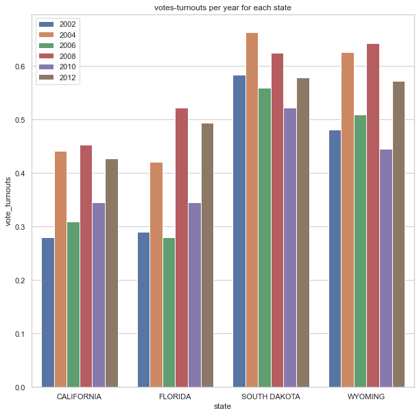

```python
plt.figure(figsize=(10, 10))
ax = sns.barplot(x="state", y="vote_turnouts", hue="year", data=votes_turnouts_df).set(title='votes-turnouts per year for each state')
plt.legend(loc='upper left')
```

As we can see the states split to 2 group(California, Florida vs South Dakota, Wyoming) also for each state we can see which year was with the highest votes turnouts and which with the lowest: California: highest: 2008 lowest: 2002 Florida: highest: 2008 lowest: 2006 South Dakota: highest: 2004 lowest: 2010 Wyoming: highest: 2008 lowest: 2010 Another interesting thing we can see is that years that also were presidential elections years, have higher turnouts rate. let's see the average votes turnouts of the four states,

```python
print("avergae votes turnout for each state:")
print("California: ",np.mean(votes_turnouts_df.loc[votes_turnouts_df['state'] == 'CALIFORNIA']['vote_turnouts']))
print("Florida: ",np.mean(votes_turnouts_df.loc[votes_turnouts_df['state'] == 'FLORIDA']['vote_turnouts']))
print("South Dakota: ",np.mean(votes_turnouts_df.loc[votes_turnouts_df['state'] == 'SOUTH DAKOTA']['vote_turnouts']))
print("Wyoming: ",np.mean(votes_turnouts_df.loc[votes_turnouts_df['state'] == 'WYOMING']['vote_turnouts']))
```

```
avergae votes turnout for each state:
California:  0.37615707332143705
Florida:  0.3921192315262633
South Dakota:  0.5886021878824089
Wyoming:  0.5464352490694538
```

It is much more clear that the states divide to 2 groups (California, Florida) with lower average votes turnouts which is also similar, and (South Dakota, Wyoming) with higher average votes turnouts which is also similar. Let's see the Majority party for each state per year,

```python
states = ['CALIFORNIA','FLORIDA','SOUTH DAKOTA','WYOMING']

print("Majority party for each state per year")

for s in states:
    print(s," : ",votes_turnouts_df.loc[votes_turnouts_df['state'] == s]['party'].values)
```

```
Majority party for each state per year
CALIFORNIA  :  ['D' 'D' 'D' 'D' 'D' 'D']
FLORIDA  :  ['R' 'R' 'R' 'R' 'R' 'R']
SOUTH DAKOTA  :  ['R' 'D' 'D' 'D' 'D' 'R']
WYOMING  :  ['R' 'R' 'R' 'R' 'R' 'R']
```

### Checking the difference between the turn-outs of the year type

As we saw above years that also were presidential elections years, have higher turnouts rate  
Now will check the overall average turn outs rate for each year type(presidential elections year or not).

```python
mask = house_section_c_df_after_arrange['year'].isin([2004,2008,2012])
presidential_years_avg = np.mean(house_section_c_df_after_arrange[mask]['vote_turnouts'].values)
not_presidential_years_avg = np.mean(house_section_c_df_after_arrange[~mask]['vote_turnouts'].values)
```

```
No handles with labels found to put in legend.
```

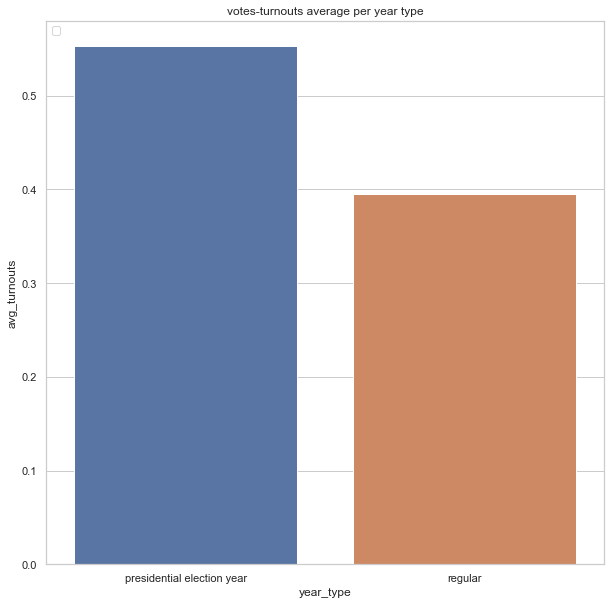

```python
plt.figure(figsize=(10, 10))
df = pd.DataFrame()
df['avg_turnouts'] = [presidential_years_avg,not_presidential_years_avg]
df['year_type'] = ['presidential election year','regular']
ax = sns.barplot(x="year_type", y="avg_turnouts", data=df).set(title='votes-turnouts average per year type')
plt.legend(loc='upper left')
```

```python
presidential_years_avg/not_presidential_years_avg
```

```
1.3993203268848835
```

As we can see the average turnouts is higher by almost 40% in presidential elections years.  
This maybe indicate that at those years the political involvment of the citizen and  
the parties involvment in each state is higher due to the higher importance,  
of the presidential elections.

### Presidential elections

```python
mask = merged_president_df_after_arrange['state'].isin(['CALIFORNIA','FLORIDA','SOUTH DAKOTA','WYOMING'])
votes_turnouts_df = merged_president_df_after_arrange[mask]
votes_turnouts_df
```

|  | year | state | writein_president | party_president | vote_turnouts_president |
| --- | --- | --- | --- | --- | --- |
| 63 | 2004 | CALIFORNIA | 0.142857 | 1 | 0.471711 |
| 70 | 2008 | CALIFORNIA | 0.142857 | 1 | 0.498046 |
| 77 | 2012 | CALIFORNIA | 0.142857 | 1 | 0.457027 |
| 179 | 2004 | FLORIDA | 0.000000 | 0 | 0.569268 |
| 187 | 2008 | FLORIDA | 0.071429 | 1 | 0.590528 |
| 201 | 2012 | FLORIDA | 0.076923 | 1 | 0.556782 |
| 799 | 2004 | SOUTH DAKOTA | 0.000000 | 0 | 0.661675 |
| 804 | 2008 | SOUTH DAKOTA | 0.000000 | 0 | 0.629430 |
| 809 | 2012 | SOUTH DAKOTA | 0.000000 | 0 | 0.582152 |
| 965 | 2004 | WYOMING | 0.166667 | 0 | 0.638937 |
| 971 | 2008 | WYOMING | 0.166667 | 0 | 0.656840 |
| 977 | 2012 | WYOMING | 0.142857 | 0 | 0.572236 |

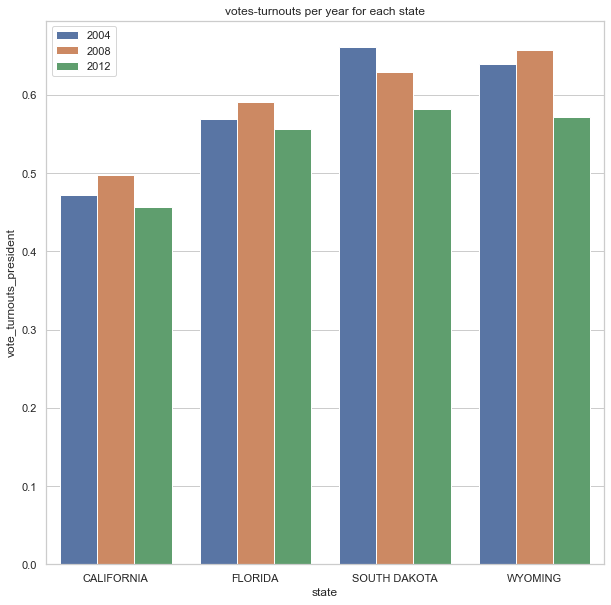

```python
plt.figure(figsize=(10, 10))
ax = sns.barplot(x="state", y="vote_turnouts_president", hue="year", data=votes_turnouts_df).set(title='votes-turnouts per year for each state')
plt.legend(loc='upper left')
```

Also, here we can see that California and Florida have a lower turn outs rate then South Dakota,  
and Wyoming.  
lets see the average turnouts rate for each state.

```python
print("average votes turnout for each state:")
print("California: ",np.mean(votes_turnouts_df.loc[votes_turnouts_df['state'] == 'CALIFORNIA']['vote_turnouts_president']))
print("Florida: ",np.mean(votes_turnouts_df.loc[votes_turnouts_df['state'] == 'FLORIDA']['vote_turnouts_president']))
print("South Dakota: ",np.mean(votes_turnouts_df.loc[votes_turnouts_df['state'] == 'SOUTH DAKOTA']['vote_turnouts_president']))
print("Wyoming: ",np.mean(votes_turnouts_df.loc[votes_turnouts_df['state'] == 'WYOMING']['vote_turnouts_president']))
```

```
average votes turnout for each state:
California:  0.47559489142828326
Florida:  0.572192797609765
South Dakota:  0.6244191728477125
Wyoming:  0.6226707801711159
```

We can see that South Dakota and Wyoming have similer average turnouts rate and that it also similer to the House elections turn outs rate.  
California and Florida have higher turn outs rate then in the House elections, yet still significantly lower  
then the first two states.

```python
states = ['CALIFORNIA','FLORIDA','SOUTH DAKOTA','WYOMING']

print("Majority party for each state per year(1=D, R=0)")

for s in states:
    print(s," : ",votes_turnouts_df.loc[votes_turnouts_df['state'] == s]['party_president'].values)
```

```
Majority party for each state per year(1=D, R=0)
CALIFORNIA  :  [1 1 1]
FLORIDA  :  [0 1 1]
SOUTH DAKOTA  :  [0 0 0]
WYOMING  :  [0 0 0]
```

### Senate elections

```python
mask = merged_senate_df_after_arrange['state'].isin(['CALIFORNIA','FLORIDA','SOUTH DAKOTA','WYOMING'])
votes_turnouts_df = merged_senate_df_after_arrange[mask]
votes_turnouts_df
```

|  | year | state | special | writein_senate | party_senate | vote_turnouts_senate |
| --- | --- | --- | --- | --- | --- | --- |
| 689 | 2004 | CALIFORNIA | 0.000000 | 0.166667 | 1 | 0.457734 |
| 695 | 2006 | CALIFORNIA | 0.000000 | 0.142857 | 1 | 0.318987 |
| 702 | 2010 | CALIFORNIA | 0.000000 | 0.400000 | 1 | 0.357721 |
| 712 | 2012 | CALIFORNIA | 0.000000 | 0.000000 | 1 | 0.440902 |
| 747 | 2004 | FLORIDA | 0.000000 | 0.571429 | 0 | 0.555809 |
| 754 | 2006 | FLORIDA | 0.000000 | 0.250000 | 1 | 0.347845 |
| 762 | 2010 | FLORIDA | 0.000000 | 0.411765 | 0 | 0.365665 |
| 779 | 2012 | FLORIDA | 0.000000 | 0.555556 | 1 | 0.538107 |
| 546 | 2002 | SOUTH DAKOTA | 0.000000 | 0.000000 | 1 | 0.584791 |
| 549 | 2004 | SOUTH DAKOTA | 0.000000 | 0.000000 | 0 | 0.666743 |
| 551 | 2008 | SOUTH DAKOTA | 0.000000 | 0.000000 | 1 | 0.627284 |
| 553 | 2010 | SOUTH DAKOTA | 0.000000 | 0.000000 | 0 | 0.372832 |
| 647 | 2002 | WYOMING | 0.000000 | 0.000000 | 0 | 0.484138 |
| 649 | 2006 | WYOMING | 0.000000 | 0.200000 | 0 | 0.509867 |
| 654 | 2008 | WYOMING | 0.500000 | 0.250000 | 0 | 1.287443 |
| 662 | 2012 | WYOMING | 0.000000 | 0.166667 | 0 | 0.572234 |

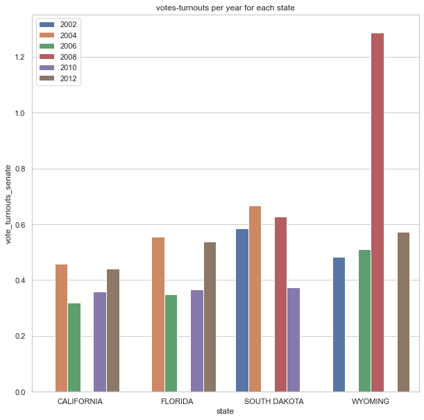

```python
plt.figure(figsize=(10, 10))
ax = sns.barplot(x="state", y="vote_turnouts_senate", hue="year", data=votes_turnouts_df).set(title='votes-turnouts per year for each state')
plt.legend(loc='upper left')
```

Like the other elections also here California and Florida have lower turn outs then South Dakota and Wyoming,  
and the presidential years also have higher turnouts rate.  
We can also see something which is impossible, at 2008 the turnouts rate in Wyoming seems to be higher than 100%, we checked and saw that this is the only sample that has this kind of impossible turnouts rate.  
this be an estimation error when we calculated the eligible voters for each state.

```python
print("average votes turnout for each state:")
print("California: ",np.mean(votes_turnouts_df.loc[votes_turnouts_df['state'] == 'CALIFORNIA']['vote_turnouts_senate']))
print("Florida: ",np.mean(votes_turnouts_df.loc[votes_turnouts_df['state'] == 'FLORIDA']['vote_turnouts_senate']))
print("South Dakota: ",np.mean(votes_turnouts_df.loc[votes_turnouts_df['state'] == 'SOUTH DAKOTA']['vote_turnouts_senate']))
print("Wyoming: ",np.mean(votes_turnouts_df.loc[votes_turnouts_df['state'] == 'WYOMING']['vote_turnouts_senate']))
```

```
average votes turnout for each state:
California:  0.39383590155708864
Florida:  0.45185640406575334
South Dakota:  0.5629123723987025
Wyoming:  0.7134204296162078
```

```python
states = ['CALIFORNIA','FLORIDA','SOUTH DAKOTA','WYOMING']

print("Majority party for each state per year(1=D, R=0)")

for s in states:
    print(s," : ",votes_turnouts_df.loc[votes_turnouts_df['state'] == s]['party_senate'].values)
```

```
Majority party for each state per year(1=D, R=0)
CALIFORNIA  :  [1 1 1 1]
FLORIDA  :  [0 1 0 1]
SOUTH DAKOTA  :  [1 0 1 0]
WYOMING  :  [0 0 0 0]
```

### Correlation

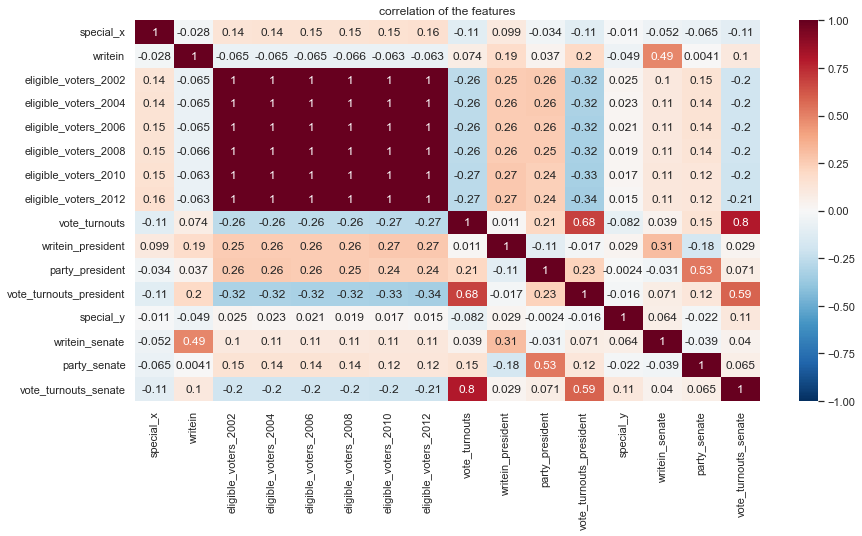

```python
plt.figure(figsize=(14,7))
plt.title("correlation of the features")
heatmap_data = section_c_finale_df.iloc[:,1:17].corr()
sns.heatmap(data=heatmap_data,cmap= 'RdBu_r', vmin=-1, vmax=1, annot=True)
```

#### Data Exploration , Visualization and Pre-Processing for Section D

```python
section_c_finale_df['party_R'] = section_c_finale_df.party_R.replace({1: 'R', 0: 'D'})
```

```python
section_c_finale_df.rename(columns = {'party_R':'House_party'}, inplace = True)
```

```python
section_c_finale_df
```

|  | year | special_x | writein | eligible_voters_2002 | eligible_voters_2004 | eligible_voters_2006 | eligible_voters_2008 | eligible_voters_2010 | eligible_voters_2012 | vote_turnouts | ... | state_TENNESSEE | state_TEXAS | state_UTAH | state_VERMONT | state_VIRGINIA | state_WASHINGTON | state_WEST VIRGINIA | state_WISCONSIN | state_WYOMING | House_party |
| --- | --- | --- | --- | --- | --- | --- | --- | --- | --- | --- | --- | --- | --- | --- | --- | --- | --- | --- | --- | --- | --- |
| 0 | 2002 | 0.000000 | 0.280000 | 3407064.948638 | 3421131.667825 | 3436141.793876 | 3452116.232615 | 3647015.426000 | 3673062.870000 | 0.372403 | ... | 0 | 0 | 0 | 0 | 0 | 0 | 0 | 0 | 0 | R |
| 1 | 2004 | 0.000000 | 0.350000 | 3407064.948638 | 3421131.667825 | 3436141.793876 | 3452116.232615 | 3647015.426000 | 3673062.870000 | 0.524025 | ... | 0 | 0 | 0 | 0 | 0 | 0 | 0 | 0 | 0 | R |
| 2 | 2006 | 0.000000 | 0.368421 | 3407064.948638 | 3421131.667825 | 3436141.793876 | 3452116.232615 | 3647015.426000 | 3673062.870000 | 0.331812 | ... | 0 | 0 | 0 | 0 | 0 | 0 | 0 | 0 | 0 | R |
| 3 | 2008 | 0.000000 | 0.388889 | 3407064.948638 | 3421131.667825 | 3436141.793876 | 3452116.232615 | 3647015.426000 | 3673062.870000 | 0.537429 | ... | 0 | 0 | 0 | 0 | 0 | 0 | 0 | 0 | 0 | R |
| 4 | 2010 | 0.000000 | 0.368421 | 3407064.948638 | 3421131.667825 | 3436141.793876 | 3452116.232615 | 3647015.426000 | 3673062.870000 | 0.375032 | ... | 0 | 0 | 0 | 0 | 0 | 0 | 0 | 0 | 0 | R |
| ... | ... | ... | ... | ... | ... | ... | ... | ... | ... | ... | ... | ... | ... | ... | ... | ... | ... | ... | ... | ... | ... |
| 295 | 2004 | 0.000000 | 0.200000 | 378569.468910 | 381666.982633 | 384835.551681 | 388076.322566 | 428220.153000 | 438107.792000 | 0.626627 | ... | 0 | 0 | 0 | 0 | 0 | 0 | 0 | 0 | 1 | R |
| 296 | 2006 | 0.000000 | 0.166667 | 378569.468910 | 381666.982633 | 384835.551681 | 388076.322566 | 428220.153000 | 438107.792000 | 0.509867 | ... | 0 | 0 | 0 | 0 | 0 | 0 | 0 | 0 | 1 | R |
| 297 | 2008 | 0.000000 | 0.200000 | 378569.468910 | 381666.982633 | 384835.551681 | 388076.322566 | 428220.153000 | 438107.792000 | 0.643108 | ... | 0 | 0 | 0 | 0 | 0 | 0 | 0 | 0 | 1 | R |
| 298 | 2010 | 0.000000 | 0.166667 | 378569.468910 | 381666.982633 | 384835.551681 | 388076.322566 | 428220.153000 | 438107.792000 | 0.445617 | ... | 0 | 0 | 0 | 0 | 0 | 0 | 0 | 0 | 1 | R |
| 299 | 2012 | 0.000000 | 0.125000 | 378569.468910 | 381666.982633 | 384835.551681 | 388076.322566 | 428220.153000 | 438107.792000 | 0.572234 | ... | 0 | 0 | 0 | 0 | 0 | 0 | 0 | 0 | 1 | R |

300 rows × 67 columns

```python
np.unique(section_c_finale_df.isnull().sum())
```

```
array([0], dtype=int64)
```

```python
section_d_df = section_c_finale_df.copy(deep=True)
section_d_df['year_presidential'] = 0
section_d_df['year_presidential'] = np.where(((section_d_df['year']==2004)|(section_d_df['year']==2008)|(section_d_df['year']==2012)), 1, section_d_df['year_presidential'])
section_d_df
```

|  | year | special_x | writein | eligible_voters_2002 | eligible_voters_2004 | eligible_voters_2006 | eligible_voters_2008 | eligible_voters_2010 | eligible_voters_2012 | vote_turnouts | ... | state_TEXAS | state_UTAH | state_VERMONT | state_VIRGINIA | state_WASHINGTON | state_WEST VIRGINIA | state_WISCONSIN | state_WYOMING | House_party | year_presidential |
| --- | --- | --- | --- | --- | --- | --- | --- | --- | --- | --- | --- | --- | --- | --- | --- | --- | --- | --- | --- | --- | --- |
| 0 | 2002 | 0.000000 | 0.280000 | 3407064.948638 | 3421131.667825 | 3436141.793876 | 3452116.232615 | 3647015.426000 | 3673062.870000 | 0.372403 | ... | 0 | 0 | 0 | 0 | 0 | 0 | 0 | 0 | R | 0 |
| 1 | 2004 | 0.000000 | 0.350000 | 3407064.948638 | 3421131.667825 | 3436141.793876 | 3452116.232615 | 3647015.426000 | 3673062.870000 | 0.524025 | ... | 0 | 0 | 0 | 0 | 0 | 0 | 0 | 0 | R | 1 |
| 2 | 2006 | 0.000000 | 0.368421 | 3407064.948638 | 3421131.667825 | 3436141.793876 | 3452116.232615 | 3647015.426000 | 3673062.870000 | 0.331812 | ... | 0 | 0 | 0 | 0 | 0 | 0 | 0 | 0 | R | 0 |
| 3 | 2008 | 0.000000 | 0.388889 | 3407064.948638 | 3421131.667825 | 3436141.793876 | 3452116.232615 | 3647015.426000 | 3673062.870000 | 0.537429 | ... | 0 | 0 | 0 | 0 | 0 | 0 | 0 | 0 | R | 1 |
| 4 | 2010 | 0.000000 | 0.368421 | 3407064.948638 | 3421131.667825 | 3436141.793876 | 3452116.232615 | 3647015.426000 | 3673062.870000 | 0.375032 | ... | 0 | 0 | 0 | 0 | 0 | 0 | 0 | 0 | R | 0 |
| ... | ... | ... | ... | ... | ... | ... | ... | ... | ... | ... | ... | ... | ... | ... | ... | ... | ... | ... | ... | ... | ... |
| 295 | 2004 | 0.000000 | 0.200000 | 378569.468910 | 381666.982633 | 384835.551681 | 388076.322566 | 428220.153000 | 438107.792000 | 0.626627 | ... | 0 | 0 | 0 | 0 | 0 | 0 | 0 | 1 | R | 1 |
| 296 | 2006 | 0.000000 | 0.166667 | 378569.468910 | 381666.982633 | 384835.551681 | 388076.322566 | 428220.153000 | 438107.792000 | 0.509867 | ... | 0 | 0 | 0 | 0 | 0 | 0 | 0 | 1 | R | 0 |
| 297 | 2008 | 0.000000 | 0.200000 | 378569.468910 | 381666.982633 | 384835.551681 | 388076.322566 | 428220.153000 | 438107.792000 | 0.643108 | ... | 0 | 0 | 0 | 0 | 0 | 0 | 0 | 1 | R | 1 |
| 298 | 2010 | 0.000000 | 0.166667 | 378569.468910 | 381666.982633 | 384835.551681 | 388076.322566 | 428220.153000 | 438107.792000 | 0.445617 | ... | 0 | 0 | 0 | 0 | 0 | 0 | 0 | 1 | R | 0 |
| 299 | 2012 | 0.000000 | 0.125000 | 378569.468910 | 381666.982633 | 384835.551681 | 388076.322566 | 428220.153000 | 438107.792000 | 0.572234 | ... | 0 | 0 | 0 | 0 | 0 | 0 | 0 | 1 | R | 1 |

300 rows × 68 columns

Lets check the ration between the labal values

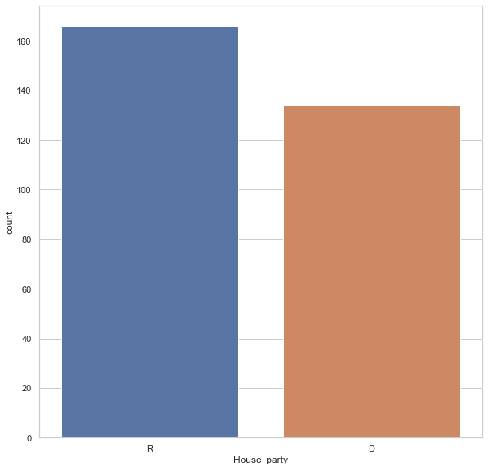

```python
# visualize the label variable
plt.figure(figsize=(10, 10))
g = sns.countplot(section_d_df['House_party'])
g.set_xticklabels(['R','D'])
plt.show()
```

```python
print("The ration in the test dataset is:    ", len(section_d_df.loc[ (section_d_df['House_party']=='R') & (section_d_df['year']>=2010)]) /
      len(section_d_df.loc[(section_d_df['House_party']=='D') & (section_d_df['year']>=2010)  ]))
```

```
The ration in the test dataset is:     1.7027027027027026
```

```python
print("The ration in the train dataset is:    ", len(section_d_df.loc[ (section_d_df['House_party']=='R') & (section_d_df['year']<2010)]) /
      len(section_d_df.loc[(section_d_df['House_party']=='D') & (section_d_df['year']<2010)  ]))
```

```
The ration in the train dataset is:     1.0618556701030928
```

### Train Test split

Train = 2002 -> 2008  
Test = 2010, 2012

```python
section_d_df['party_senate'] = np.round(section_d_df['party_senate'])
section_d_df['party_president'] = np.round(section_d_df['party_president'])
```

```python
section_d_df
```

|  | year | special_x | writein | eligible_voters_2002 | eligible_voters_2004 | eligible_voters_2006 | eligible_voters_2008 | eligible_voters_2010 | eligible_voters_2012 | vote_turnouts | ... | state_TEXAS | state_UTAH | state_VERMONT | state_VIRGINIA | state_WASHINGTON | state_WEST VIRGINIA | state_WISCONSIN | state_WYOMING | House_party | year_presidential |
| --- | --- | --- | --- | --- | --- | --- | --- | --- | --- | --- | --- | --- | --- | --- | --- | --- | --- | --- | --- | --- | --- |
| 0 | 2002 | 0.000000 | 0.280000 | 3407064.948638 | 3421131.667825 | 3436141.793876 | 3452116.232615 | 3647015.426000 | 3673062.870000 | 0.372403 | ... | 0 | 0 | 0 | 0 | 0 | 0 | 0 | 0 | R | 0 |
| 1 | 2004 | 0.000000 | 0.350000 | 3407064.948638 | 3421131.667825 | 3436141.793876 | 3452116.232615 | 3647015.426000 | 3673062.870000 | 0.524025 | ... | 0 | 0 | 0 | 0 | 0 | 0 | 0 | 0 | R | 1 |
| 2 | 2006 | 0.000000 | 0.368421 | 3407064.948638 | 3421131.667825 | 3436141.793876 | 3452116.232615 | 3647015.426000 | 3673062.870000 | 0.331812 | ... | 0 | 0 | 0 | 0 | 0 | 0 | 0 | 0 | R | 0 |
| 3 | 2008 | 0.000000 | 0.388889 | 3407064.948638 | 3421131.667825 | 3436141.793876 | 3452116.232615 | 3647015.426000 | 3673062.870000 | 0.537429 | ... | 0 | 0 | 0 | 0 | 0 | 0 | 0 | 0 | R | 1 |
| 4 | 2010 | 0.000000 | 0.368421 | 3407064.948638 | 3421131.667825 | 3436141.793876 | 3452116.232615 | 3647015.426000 | 3673062.870000 | 0.375032 | ... | 0 | 0 | 0 | 0 | 0 | 0 | 0 | 0 | R | 0 |
| ... | ... | ... | ... | ... | ... | ... | ... | ... | ... | ... | ... | ... | ... | ... | ... | ... | ... | ... | ... | ... | ... |
| 295 | 2004 | 0.000000 | 0.200000 | 378569.468910 | 381666.982633 | 384835.551681 | 388076.322566 | 428220.153000 | 438107.792000 | 0.626627 | ... | 0 | 0 | 0 | 0 | 0 | 0 | 0 | 1 | R | 1 |
| 296 | 2006 | 0.000000 | 0.166667 | 378569.468910 | 381666.982633 | 384835.551681 | 388076.322566 | 428220.153000 | 438107.792000 | 0.509867 | ... | 0 | 0 | 0 | 0 | 0 | 0 | 0 | 1 | R | 0 |
| 297 | 2008 | 0.000000 | 0.200000 | 378569.468910 | 381666.982633 | 384835.551681 | 388076.322566 | 428220.153000 | 438107.792000 | 0.643108 | ... | 0 | 0 | 0 | 0 | 0 | 0 | 0 | 1 | R | 1 |
| 298 | 2010 | 0.000000 | 0.166667 | 378569.468910 | 381666.982633 | 384835.551681 | 388076.322566 | 428220.153000 | 438107.792000 | 0.445617 | ... | 0 | 0 | 0 | 0 | 0 | 0 | 0 | 1 | R | 0 |
| 299 | 2012 | 0.000000 | 0.125000 | 378569.468910 | 381666.982633 | 384835.551681 | 388076.322566 | 428220.153000 | 438107.792000 | 0.572234 | ... | 0 | 0 | 0 | 0 | 0 | 0 | 0 | 1 | R | 1 |

300 rows × 68 columns

```python
sect_d_train = section_d_df.loc[(section_d_df['year'] >=2002) & (section_d_df['year'] <= 2008) ]
sect_d_test = section_d_df.loc[(section_d_df['year'] >=2010) & (section_d_df['year'] <= 2012) ]
```

### X, Y split

Y = The majority party in the state.  
X = all the other features.

```python
sec_d_trainX = sect_d_train.drop(['House_party'],axis=1,inplace=False)
sec_d_trainY = sect_d_train['House_party']
sec_d_testX = sect_d_test.drop(['House_party'],axis=1,inplace=False)
sec_d_testY = sect_d_test['House_party']
```

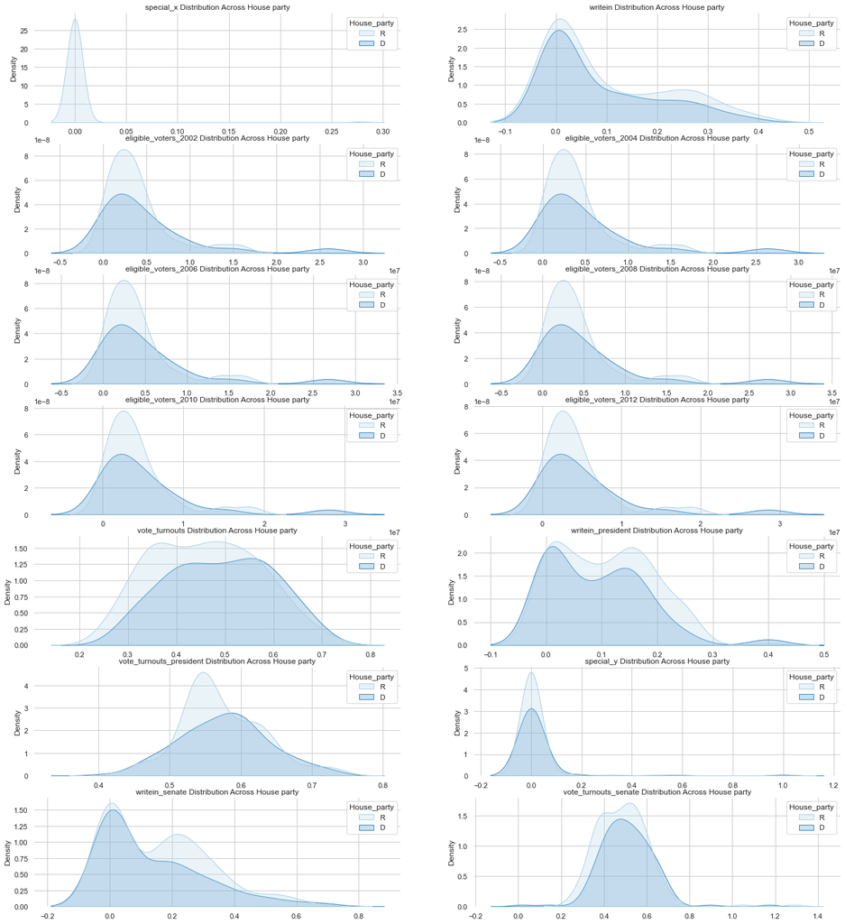

```python
#plot distribution plots for numerical variables, divided by preciptotal(0,1)

plt.figure(figsize=(22, 25))
columns = section_d_df.iloc[:,1:17].drop(['party_president','party_senate'],axis=1,inplace=False)

for i in columns:
    plt.subplot(7, 2, columns.columns.get_loc(i)+1)
    sns.kdeplot(section_d_df[i], hue=section_d_df['House_party'], fill=True, palette='Blues', common_norm=True)
    sns.despine(top=True, right=True, bottom=True, left=True)
    plt.tick_params(axis='both', which='both', bottom=False, top=False, left=False)
    plt.xlabel('')
    plt.title(i + ' Distribution Across House party')
```

As we can see none of those features distribution is a good seperator between samples of each party.  
Lets, check the categorical features.

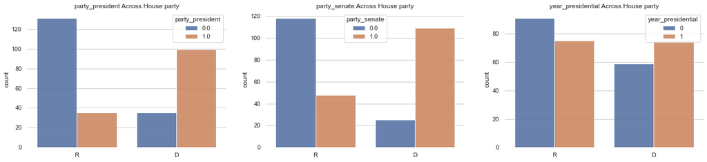

```python
# plot barplots for categorical variables, divided by stage
categorical_features = section_d_df[['party_president','party_senate','year_presidential']]
plt.figure(figsize=(22, 10))

for i in categorical_features:
    plt.subplot(2, 3, categorical_features.columns.get_loc(i)+1)
    sns.countplot(x=section_d_df['House_party'], hue=section_d_df[i], alpha=0.9)
    sns.despine(top=True, right=True, bottom=True, left=True)
    plt.tick_params(axis='both', which='both', bottom=False, top=False, left=False)
    plt.xlabel('')
    plt.title(i + ' Across House party')
```

As we can see in most cases the state majority party in the House elections is also the same party in the Senate  
and the presidential elections  
. The presidential elections indicator does not seems to be a good indicator of the majority party.  
Lets, print the ratio's of the above party_president and senate bar plots.

```python
R_president_R_House = len(section_d_df.loc[(section_d_df['party_president']==0) & (section_d_df['House_party']=='R')])
D_president_D_House = len(section_d_df.loc[(section_d_df['party_president']==1) & (section_d_df['House_party']=='D')])
D_president_R_House = len(section_d_df.loc[(section_d_df['party_president']==1) & (section_d_df['House_party']=='R')])
R_president_D_House = len(section_d_df.loc[(section_d_df['party_president']==0) & (section_d_df['House_party']=='D')])


R_Senate_R_House = len(section_d_df.loc[(section_d_df['party_senate']==0) & (section_d_df['House_party']=='R')])
D_Senate_R_House = len(section_d_df.loc[(section_d_df['party_senate']==1) & (section_d_df['House_party']=='R')])
R_Senate_D_House = len(section_d_df.loc[(section_d_df['party_senate']==0) & (section_d_df['House_party']=='D')])
D_Senate_D_House = len(section_d_df.loc[(section_d_df['party_senate']==1) & (section_d_df['House_party']=='D')])
```

```python
print("R in President from all R in the house: ",R_president_R_House/(R_president_R_House+D_president_R_House))
print("D in President from all D in the house: ",D_president_D_House/(D_president_D_House+R_president_D_House))
```

```
R in President from all R in the house:  0.7891566265060241
D in President from all D in the house:  0.7388059701492538
```

```python
print("R in Senate from all R in the house: ",R_Senate_R_House/(R_Senate_R_House+D_Senate_R_House))
print("D in Senate from all D in the house: ",D_Senate_D_House/(D_Senate_D_House+R_Senate_D_House))
```

```
R in Senate from all R in the house:  0.7108433734939759
D in Senate from all D in the house:  0.8134328358208955
```

```python
print("R D ratio in President from all R in the house: ",R_president_R_House/D_president_R_House)
print("D R ratio in President from all D in the house: ",D_president_D_House/R_president_D_House)
```

```
R D ratio in President from all R in the house:  3.742857142857143
D R ratio in President from all D in the house:  2.8285714285714287
```

```python
print("R D ratio in Senate from all R in the house: ",R_Senate_R_House/D_Senate_R_House)
print("D R ratio in Senate from all D in the house: ",D_Senate_D_House/R_Senate_D_House)
```

```
R D ratio in Senate from all R in the house:  2.4583333333333335
D R ratio in Senate from all D in the house:  4.36
```

```python
print("R in house and Senate from all R in Senate: ",R_Senate_R_House/(R_Senate_R_House + R_Senate_D_House))
print("D in house and Senate from all D in Senate: ",D_Senate_D_House/(D_Senate_D_House + D_Senate_R_House))
```

```
R in house and Senate from all R in Senate:  0.8251748251748252
D in house and Senate from all D in Senate:  0.6942675159235668
```

```python
print("R in house and President from all R in President: ",R_president_R_House/(R_president_R_House + R_president_D_House))
print("D in house and President from all D in President: ",D_president_D_House/(D_president_D_House + D_president_R_House))
```

```
R in house and President from all R in President:  0.7891566265060241
D in house and President from all D in President:  0.7388059701492538
```

#### Data Exploration , Visualization and Pre-Processing for Section E

```python
general_demog_df_sec_c
```

|  | fips | state | name | pop2000 | pop2010 | pop2011 | pop2012 | pop2013 | pop2014 | pop2015 | ... | pop2002 | pop2004 | pop2006 | pop2008 | eligible_voters_2002 | eligible_voters_2004 | eligible_voters_2006 | eligible_voters_2008 | eligible_voters_2010 | eligible_voters_2012 |
| --- | --- | --- | --- | --- | --- | --- | --- | --- | --- | --- | --- | --- | --- | --- | --- | --- | --- | --- | --- | --- | --- |
| 0 | 1001 | Alabama | Autauga County | 43671.000000 | 54571.000000 | 55199.000000 | 54927.000000 | 54695.000000 | 54864.000000 | 54838.000000 | ... | 43884.431418 | 44098.905931 | 44314.428636 | 44531.004656 | 32123.403798 | 32280.399142 | 32438.161762 | 32596.695408 | 39945.972000 | 40206.564000 |
| 1 | 1003 | Alabama | Baldwin County | 140415.000000 | 182265.000000 | 186534.000000 | 190048.000000 | 194736.000000 | 199064.000000 | 202863.000000 | ... | 146735.361283 | 153340.214726 | 160242.365894 | 167455.196754 | 112986.228188 | 118071.965339 | 123386.621738 | 128940.501500 | 140344.050000 | 146336.960000 |
| 2 | 1005 | Alabama | Barbour County | 29038.000000 | 27457.000000 | 27351.000000 | 27175.000000 | 26947.000000 | 26749.000000 | 26264.000000 | ... | 28358.582216 | 27695.061137 | 27047.064819 | 26414.230021 | 22148.052710 | 21629.842748 | 21123.757624 | 20629.513647 | 21443.917000 | 21223.675000 |
| 3 | 1007 | Alabama | Bibb County | 20826.000000 | 22915.000000 | 22745.000000 | 22658.000000 | 22503.000000 | 22533.000000 | 22561.000000 | ... | 20761.958491 | 20698.113914 | 20634.465665 | 20571.013138 | 16048.993914 | 15999.642056 | 15950.441959 | 15901.393156 | 17713.295000 | 17514.634000 |
| 4 | 1009 | Alabama | Blount County | 51024.000000 | 57322.000000 | 57562.000000 | 57595.000000 | 57623.000000 | 57546.000000 | 57590.000000 | ... | 51199.432417 | 51375.468012 | 51552.108858 | 51729.357037 | 38604.372043 | 38737.102881 | 38870.290079 | 39003.935206 | 43220.788000 | 43426.630000 |
| ... | ... | ... | ... | ... | ... | ... | ... | ... | ... | ... | ... | ... | ... | ... | ... | ... | ... | ... | ... | ... | ... |
| 3137 | 56037 | Wyoming | Sweetwater County | 37613.000000 | 43806.000000 | 44013.000000 | 45042.000000 | 45145.000000 | 44981.000000 | 44732.000000 | ... | 37551.409853 | 37489.920558 | 37428.531950 | 37367.243864 | 27374.977783 | 27330.152087 | 27285.399792 | 27240.720777 | 31934.574000 | 32835.618000 |
| 3138 | 56039 | Wyoming | Teton County | 18251.000000 | 21294.000000 | 21476.000000 | 21709.000000 | 22326.000000 | 22817.000000 | 23029.000000 | ... | 18719.764771 | 19200.569452 | 19693.723282 | 20199.543439 | 15144.289700 | 15533.260687 | 15932.222135 | 16341.430642 | 17226.846000 | 17562.581000 |
| 3139 | 56041 | Wyoming | Uinta County | 19742.000000 | 21118.000000 | 20899.000000 | 20999.000000 | 20960.000000 | 20845.000000 | 20780.000000 | ... | 19574.284209 | 19407.993227 | 19243.114951 | 19079.637378 | 13662.850378 | 13546.779273 | 13431.694236 | 13317.586890 | 14740.364000 | 14657.302000 |
| 3140 | 56043 | Wyoming | Washakie County | 8289.000000 | 8533.000000 | 8460.000000 | 8421.000000 | 8427.000000 | 8288.000000 | 8296.000000 | ... | 8156.567651 | 8026.251157 | 7898.016715 | 7771.831058 | 6076.642900 | 5979.557112 | 5884.022452 | 5790.014138 | 6357.085000 | 6273.645000 |
| 3141 | 56045 | Wyoming | Weston County | 6644.000000 | 7208.000000 | 7141.000000 | 7074.000000 | 7136.000000 | 7142.000000 | 7181.000000 | ... | 6570.373751 | 6497.563399 | 6425.559904 | 6354.354323 | 5138.032273 | 5081.094578 | 5024.787845 | 4969.105081 | 5636.656000 | 5531.868000 |

3142 rows × 24 columns

Selecting the relevant states for 2022 Senate elections

```python
relevant_states = ['Alabama', 'Alaska', 'Arizona', 'Arkansas', 'California', 'Connecticut',
'Florida', 'Georgia', 'Hawaii', 'Idaho', 'Illinois', 'Indiana', 'Iowa', 'Kansas',
'Kentucky', 'Louisiana', 'Maryland', 'Missouri', 'Nevada', 'New Hampshire',
'New York', 'North Carolina', 'North Dakota', 'Ohio', 'Oklahoma',
'Oregon', 'Pennsylvania', 'South Carolina', 'South Dakota', 'Utah',
'Vermont', 'Washington', 'Wisconsin']
mask = general_demog_df_sec_c['state'].isin(relevant_states)
general_demog_df_sec_e = general_demog_df_sec_c[mask]
general_demog_df_sec_e
```

|  | fips | state | name | pop2000 | pop2010 | pop2011 | pop2012 | pop2013 | pop2014 | pop2015 | ... | pop2002 | pop2004 | pop2006 | pop2008 | eligible_voters_2002 | eligible_voters_2004 | eligible_voters_2006 | eligible_voters_2008 | eligible_voters_2010 | eligible_voters_2012 |
| --- | --- | --- | --- | --- | --- | --- | --- | --- | --- | --- | --- | --- | --- | --- | --- | --- | --- | --- | --- | --- | --- |
| 0 | 1001 | Alabama | Autauga County | 43671.000000 | 54571.000000 | 55199.000000 | 54927.000000 | 54695.000000 | 54864.000000 | 54838.000000 | ... | 43884.431418 | 44098.905931 | 44314.428636 | 44531.004656 | 32123.403798 | 32280.399142 | 32438.161762 | 32596.695408 | 39945.972000 | 40206.564000 |
| 1 | 1003 | Alabama | Baldwin County | 140415.000000 | 182265.000000 | 186534.000000 | 190048.000000 | 194736.000000 | 199064.000000 | 202863.000000 | ... | 146735.361283 | 153340.214726 | 160242.365894 | 167455.196754 | 112986.228188 | 118071.965339 | 123386.621738 | 128940.501500 | 140344.050000 | 146336.960000 |
| 2 | 1005 | Alabama | Barbour County | 29038.000000 | 27457.000000 | 27351.000000 | 27175.000000 | 26947.000000 | 26749.000000 | 26264.000000 | ... | 28358.582216 | 27695.061137 | 27047.064819 | 26414.230021 | 22148.052710 | 21629.842748 | 21123.757624 | 20629.513647 | 21443.917000 | 21223.675000 |
| 3 | 1007 | Alabama | Bibb County | 20826.000000 | 22915.000000 | 22745.000000 | 22658.000000 | 22503.000000 | 22533.000000 | 22561.000000 | ... | 20761.958491 | 20698.113914 | 20634.465665 | 20571.013138 | 16048.993914 | 15999.642056 | 15950.441959 | 15901.393156 | 17713.295000 | 17514.634000 |
| 4 | 1009 | Alabama | Blount County | 51024.000000 | 57322.000000 | 57562.000000 | 57595.000000 | 57623.000000 | 57546.000000 | 57590.000000 | ... | 51199.432417 | 51375.468012 | 51552.108858 | 51729.357037 | 38604.372043 | 38737.102881 | 38870.290079 | 39003.935206 | 43220.788000 | 43426.630000 |
| ... | ... | ... | ... | ... | ... | ... | ... | ... | ... | ... | ... | ... | ... | ... | ... | ... | ... | ... | ... | ... | ... |
| 3114 | 55133 | Wisconsin | Waukesha County | 360767.000000 | 389891.000000 | 390810.000000 | 392669.000000 | 393887.000000 | 395078.000000 | 395842.000000 | ... | 363577.155677 | 366409.200759 | 369263.305750 | 372139.642485 | 275955.061159 | 278104.583376 | 280270.849065 | 282453.988646 | 295927.269000 | 298035.771000 |
| 3115 | 55135 | Wisconsin | Waupaca County | 51731.000000 | 52410.000000 | 52280.000000 | 51910.000000 | 52062.000000 | 51929.000000 | 51684.000000 | ... | 51394.571099 | 51060.330140 | 50728.262893 | 50398.355222 | 39779.398031 | 39520.695528 | 39263.675479 | 39008.326942 | 40565.340000 | 40178.340000 |
| 3116 | 55137 | Wisconsin | Waushara County | 23154.000000 | 24496.000000 | 24551.000000 | 24422.000000 | 24257.000000 | 24112.000000 | 23981.000000 | ... | 23120.549224 | 23087.146775 | 23053.792583 | 23020.486578 | 18565.801027 | 18538.978861 | 18512.195444 | 18485.450722 | 19670.288000 | 19610.866000 |
| 3117 | 55139 | Wisconsin | Winnebago County | 156763.000000 | 166994.000000 | 167497.000000 | 168545.000000 | 169279.000000 | 169295.000000 | 169157.000000 | ... | 157674.543353 | 158591.387136 | 159513.562170 | 160441.099454 | 123616.841989 | 124335.647515 | 125058.632741 | 125785.821972 | 130923.296000 | 132139.280000 |
| 3118 | 55141 | Wisconsin | Wood County | 75555.000000 | 74749.000000 | 74649.000000 | 74322.000000 | 73919.000000 | 73578.000000 | 73316.000000 | ... | 75082.814233 | 74613.579421 | 74147.277121 | 73683.889008 | 58039.015402 | 57676.296892 | 57315.845215 | 56957.646203 | 57780.977000 | 57450.906000 |

2024 rows × 24 columns

Estimate population and eligible voters in the missing years

```python
#estimate population
general_demog_df_sec_e = general_demog_df_sec_e.assign(pop2018=lambda x: x['pop2017']* x['pop_groth_per'])
general_demog_df_sec_e = general_demog_df_sec_e.assign(pop2020=lambda x: x['pop2018']* x['pop_groth_per']**2)
general_demog_df_sec_e = general_demog_df_sec_e.assign(pop2022=lambda x: x['pop2020']* x['pop_groth_per']**2)

#estimate eligible voters
general_demog_df_sec_e = general_demog_df_sec_e.assign(eligible_voters_2000=lambda x: (x['pop2000'] * (100-x['age_under_18_2010']))/100)
general_demog_df_sec_e = general_demog_df_sec_e.assign(eligible_voters_2014=lambda x: (x['pop2014'] * (100-x['age_under_18_2010']))/100)
general_demog_df_sec_e = general_demog_df_sec_e.assign(eligible_voters_2016=lambda x: (x['pop2016'] * (100-x['age_under_18_2010']))/100)
general_demog_df_sec_e = general_demog_df_sec_e.assign(eligible_voters_2018=lambda x: (x['pop2018'] * (100-x['age_under_18_2010']))/100)
general_demog_df_sec_e = general_demog_df_sec_e.assign(eligible_voters_2020=lambda x: (x['pop2020'] * (100-x['age_under_18_2010']))/100)
general_demog_df_sec_e = general_demog_df_sec_e.assign(eligible_voters_2022=lambda x: (x['pop2022'] * (100-x['age_under_18_2010']))/100)
```

```python
general_demog_df_sec_e
```

|  | fips | state | name | pop2000 | pop2010 | pop2011 | pop2012 | pop2013 | pop2014 | pop2015 | ... | eligible_voters_2012 | pop2018 | pop2020 | pop2022 | eligible_voters_2000 | eligible_voters_2014 | eligible_voters_2016 | eligible_voters_2018 | eligible_voters_2020 | eligible_voters_2022 |
| --- | --- | --- | --- | --- | --- | --- | --- | --- | --- | --- | --- | --- | --- | --- | --- | --- | --- | --- | --- | --- | --- |
| 0 | 1001 | Alabama | Autauga County | 43671.000000 | 54571.000000 | 55199.000000 | 54927.000000 | 54695.000000 | 54864.000000 | 54838.000000 | ... | 40206.564000 | 55639.465855 | 55911.390247 | 56184.643604 | 31967.172000 | 40160.448000 | 40463.496000 | 40728.089006 | 40927.137661 | 41127.159118 |
| 1 | 1003 | Alabama | Baldwin County | 140415.000000 | 182265.000000 | 186534.000000 | 190048.000000 | 194736.000000 | 199064.000000 | 202863.000000 | ... | 146336.960000 | 217360.735458 | 227144.578899 | 237368.812791 | 108119.550000 | 153279.280000 | 159781.930000 | 167367.766302 | 174901.325752 | 182773.985849 |
| 2 | 1005 | Alabama | Barbour County | 29038.000000 | 27457.000000 | 27351.000000 | 27175.000000 | 26947.000000 | 26749.000000 | 26264.000000 | ... | 21223.675000 | 24972.622302 | 24388.324358 | 23817.697548 | 22678.678000 | 20890.969000 | 20129.494000 | 19503.618018 | 19047.281323 | 18601.621785 |
| 3 | 1007 | Alabama | Bibb County | 20826.000000 | 22915.000000 | 22745.000000 | 22658.000000 | 22503.000000 | 22533.000000 | 22561.000000 | ... | 17514.634000 | 22633.120266 | 22563.521727 | 22494.137209 | 16098.498000 | 17418.009000 | 17495.309000 | 17495.401966 | 17441.602295 | 17387.968063 |
| 4 | 1009 | Alabama | Blount County | 51024.000000 | 57322.000000 | 57562.000000 | 57595.000000 | 57623.000000 | 57546.000000 | 57590.000000 | ... | 43426.630000 | 58112.645537 | 58312.450372 | 58512.942182 | 38472.096000 | 43389.684000 | 43401.748000 | 43816.934735 | 43967.587580 | 44118.758405 |
| ... | ... | ... | ... | ... | ... | ... | ... | ... | ... | ... | ... | ... | ... | ... | ... | ... | ... | ... | ... | ... | ... |
| 3114 | 55133 | Wisconsin | Waukesha County | 360767.000000 | 389891.000000 | 390810.000000 | 392669.000000 | 393887.000000 | 395078.000000 | 395842.000000 | ... | 298035.771000 | 402178.270393 | 405310.994699 | 408468.121023 | 273822.153000 | 299864.202000 | 302252.775000 | 305253.307228 | 307631.044976 | 310027.303857 |
| 3115 | 55135 | Wisconsin | Waupaca County | 51731.000000 | 52410.000000 | 52280.000000 | 51910.000000 | 52062.000000 | 51929.000000 | 51684.000000 | ... | 40178.340000 | 51058.159215 | 50726.106087 | 50396.212443 | 40039.794000 | 40193.046000 | 39747.996000 | 39519.015233 | 39262.006111 | 39006.668431 |
| 3116 | 55137 | Wisconsin | Waushara County | 23154.000000 | 24496.000000 | 24551.000000 | 24422.000000 | 24257.000000 | 24112.000000 | 23981.000000 | ... | 19610.866000 | 24351.390589 | 24316.209934 | 24281.080104 | 18592.662000 | 19361.936000 | 19377.996000 | 19554.166643 | 19525.916577 | 19497.707323 |
| 3117 | 55139 | Wisconsin | Winnebago County | 156763.000000 | 166994.000000 | 167497.000000 | 168545.000000 | 169279.000000 | 169295.000000 | 169157.000000 | ... | 132139.280000 | 170908.742338 | 171902.540161 | 172902.116705 | 122902.192000 | 132727.280000 | 132931.120000 | 133992.453993 | 134771.591486 | 135555.259497 |
| 3118 | 55141 | Wisconsin | Wood County | 75555.000000 | 74749.000000 | 74649.000000 | 74322.000000 | 73919.000000 | 73578.000000 | 73316.000000 | ... | 57450.906000 | 72897.139081 | 72441.563784 | 71988.835634 | 58404.015000 | 56875.794000 | 56580.508000 | 56349.488509 | 55997.328805 | 55647.369945 |

2024 rows × 33 columns

```python
#selecting relevant features for estimating eligible_voters
section_e_df = general_demog_df_sec_e[['fips','state','eligible_voters_2000', 'eligible_voters_2002', 'eligible_voters_2004', 'eligible_voters_2006', 'eligible_voters_2008', 'eligible_voters_2010','eligible_voters_2012','eligible_voters_2014','eligible_voters_2016','eligible_voters_2018','eligible_voters_2020','eligible_voters_2022']]
#grouping counties by state
section_e_df_groupedby = section_e_df.groupby(['state'])

section_e_df_after_arrange = pd.DataFrame()
#estimating eligible_voters for 2000-2012
for key,item in section_e_df_groupedby:
    counties_per_state = section_e_df_groupedby.get_group(key)
    counties_per_state['eligible_voters_2000'] = counties_per_state['eligible_voters_2000'].sum()
    counties_per_state['eligible_voters_2002'] = counties_per_state['eligible_voters_2002'].sum()
    counties_per_state['eligible_voters_2004'] = counties_per_state['eligible_voters_2004'].sum()
    counties_per_state['eligible_voters_2006'] = counties_per_state['eligible_voters_2006'].sum()
    counties_per_state['eligible_voters_2008'] = counties_per_state['eligible_voters_2008'].sum()
    counties_per_state['eligible_voters_2010'] = counties_per_state['eligible_voters_2010'].sum()
    counties_per_state['eligible_voters_2012'] = counties_per_state['eligible_voters_2012'].sum()
    counties_per_state['eligible_voters_2014'] = counties_per_state['eligible_voters_2014'].sum()
    counties_per_state['eligible_voters_2016'] = counties_per_state['eligible_voters_2016'].sum()
    counties_per_state['eligible_voters_2018'] = counties_per_state['eligible_voters_2018'].sum()
    counties_per_state['eligible_voters_2020'] = counties_per_state['eligible_voters_2020'].sum()
    counties_per_state['eligible_voters_2022'] = counties_per_state['eligible_voters_2022'].sum()
    section_e_df_after_arrange = section_e_df_after_arrange.append(counties_per_state.iloc[0:1,1:])


section_e_df_after_arrange
```

|  | state | eligible_voters_2000 | eligible_voters_2002 | eligible_voters_2004 | eligible_voters_2006 | eligible_voters_2008 | eligible_voters_2010 | eligible_voters_2012 | eligible_voters_2014 | eligible_voters_2016 | eligible_voters_2018 | eligible_voters_2020 | eligible_voters_2022 |
| --- | --- | --- | --- | --- | --- | --- | --- | --- | --- | --- | --- | --- | --- |
| 0 | Alabama | 3393921.806000 | 3407064.948638 | 3421131.667825 | 3436141.793876 | 3452116.232615 | 3647015.426000 | 3673062.870000 | 3693041.389000 | 3708717.763000 | 3731146.357862 | 3755104.567322 | 3780268.598736 |
| 67 | Alaska | 464879.312861 | 469246.783641 | 473782.639512 | 478493.590749 | 483386.719849 | 522764.761000 | 537896.915155 | 542014.500893 | 545197.365497 | 547077.452589 | 553823.210869 | 560835.860570 |
| 96 | Arizona | 3824923.480000 | 3923909.175272 | 4026143.638781 | 4131736.452722 | 4240801.031909 | 4763137.425000 | 4875649.744000 | 4995635.967000 | 5145464.876000 | 5295838.303691 | 5440326.785971 | 5589617.303966 |
| 111 | Arkansas | 2023817.102000 | 2033696.216233 | 2044602.720067 | 2056558.325933 | 2069586.387545 | 2204349.952000 | 2228907.414000 | 2240175.699000 | 2257296.239000 | 2279672.704856 | 2301829.592547 | 2325377.162135 |
| 186 | California | 25470052.406000 | 25896993.818335 | 26332541.736953 | 26776883.190700 | 27230209.694857 | 27955225.324000 | 28529024.711000 | 29042262.068000 | 29488193.737000 | 29920775.377772 | 30437840.472946 | 30965537.885547 |
| 308 | Connecticut | 2626349.211000 | 2629070.334792 | 2631891.131583 | 2634812.020347 | 2637833.430285 | 2756822.863000 | 2774621.582000 | 2776253.152000 | 2766433.341000 | 2768342.653925 | 2771504.565686 | 2774772.193939 |
| 320 | Florida | 12585127.730000 | 12969398.831172 | 13367715.297103 | 13780667.962665 | 14208876.668229 | 14797996.081000 | 15219915.359000 | 15657087.473000 | 16253893.304000 | 16775128.671267 | 17318341.293962 | 17882689.609361 |
| 387 | Georgia | 6097801.508000 | 6213465.298559 | 6333471.060757 | 6457978.063927 | 6587153.134514 | 7196255.982000 | 7361258.131000 | 7486949.995000 | 7655455.890000 | 7824451.756507 | 7997125.032249 | 8176398.669453 |
| 546 | Hawaii | 941147.353000 | 953939.178981 | 966928.731003 | 980119.470674 | 993514.926336 | 1056447.930000 | 1081666.863000 | 1100998.741000 | 1109488.284000 | 1116271.390089 | 1131850.597398 | 1147677.558804 |
| 551 | Idaho | 941778.601000 | 964630.964727 | 988324.045918 | 1012890.627794 | 1038364.840438 | 1138551.605000 | 1158123.382000 | 1183966.402000 | 1219922.173000 | 1263368.103295 | 1297596.719283 | 1333108.388037 |
| 595 | Illinois | 9413284.934000 | 9402367.637989 | 9391916.137618 | 9381924.759040 | 9372388.136365 | 9702217.388000 | 9737722.962000 | 9739804.076000 | 9703160.508000 | 9673783.528543 | 9668005.943191 | 9662718.387524 |
| 697 | Indiana | 4577685.292000 | 4606841.723505 | 4637040.144684 | 4668309.217866 | 4700678.743246 | 4874940.856000 | 4912954.669000 | 4955152.620000 | 4984665.611000 | 5029258.785142 | 5071317.252592 | 5114838.403460 |
| 789 | Iowa | 2228796.875000 | 2244213.847609 | 2260494.966980 | 2277672.241831 | 2295779.595380 | 2318521.906000 | 2339560.846000 | 2363108.226000 | 2381901.663000 | 2404808.796440 | 2429303.587863 | 2455056.456756 |
| 888 | Kansas | 2005063.150000 | 2014387.988318 | 2024157.830227 | 2034377.398237 | 2045051.634089 | 2126310.645000 | 2150214.063000 | 2160595.418000 | 2166454.372000 | 2177328.302074 | 2191440.879050 | 2206069.676025 |
| 993 | Kentucky | 3091147.685000 | 3109849.142086 | 3129377.170506 | 3149742.362212 | 3170955.920024 | 3315705.715000 | 3349284.545000 | 3369442.739000 | 3388965.173000 | 3416023.844594 | 3443619.208966 | 3472217.883214 |
| 1113 | Louisiana | 3374562.179000 | 3407734.949738 | 3442388.805637 | 3478579.632356 | 3516366.288186 | 3415128.768000 | 3467651.854000 | 3502420.079000 | 3530490.463000 | 3546837.873267 | 3583327.139214 | 3621279.560809 |
| 1193 | Maryland | 4058802.999000 | 4110726.794339 | 4163806.349696 | 4218067.100290 | 4273535.113443 | 4419982.798000 | 4509583.621000 | 4569081.168000 | 4610069.597000 | 4662014.228559 | 4725963.924828 | 4791330.655312 |
| 1483 | Missouri | 4266810.777000 | 4286889.344077 | 4307664.915551 | 4329150.247285 | 4351358.499518 | 4563564.750000 | 4589606.198000 | 4615668.441000 | 4640254.971000 | 4671124.195831 | 4700217.563993 | 4730198.867213 |
| 1747 | Nevada | 1507575.512000 | 1551717.456876 | 1597354.474422 | 1644537.297036 | 1693318.409110 | 2036196.102000 | 2075009.663000 | 2134538.332000 | 2215458.873000 | 2293871.749769 | 2363921.183914 | 2436352.011670 |
| 1764 | New Hampshire | 966131.418000 | 971481.812631 | 976891.602439 | 982361.255675 | 987891.246728 | 1029358.942000 | 1032756.512000 | 1038778.272000 | 1043633.335000 | 1052674.075315 | 1058673.490885 | 1064738.261921 |
| 1828 | New York | 14744482.867000 | 14843950.136139 | 14945338.718570 | 15048672.662577 | 15153976.451632 | 15052686.573000 | 15245432.927000 | 15359930.632000 | 15408416.632000 | 15472795.191522 | 15583022.149723 | 15695309.721819 |
| 1890 | North Carolina | 6132738.934000 | 6247142.591825 | 6366365.070017 | 6490600.314025 | 6620051.189991 | 7253862.470000 | 7418332.430000 | 7557960.979000 | 7720386.210000 | 7894765.527257 | 8072431.368916 | 8257583.130356 |
| 1990 | North Dakota | 499390.212000 | 514157.370655 | 529967.160210 | 546925.453027 | 565154.045981 | 522680.408000 | 544867.650000 | 573640.196000 | 586685.250000 | 597166.513182 | 619531.197173 | 643662.032984 |
| 2043 | Ohio | 8676720.282000 | 8692723.612565 | 8710095.781078 | 8728865.309105 | 8749061.710477 | 8806348.929000 | 8813240.713000 | 8847802.605000 | 8868614.742000 | 8909876.028984 | 8939824.372953 | 8971454.638719 |
| 2131 | Oklahoma | 2595802.681000 | 2627600.267825 | 2660472.510580 | 2694447.129761 | 2729553.102091 | 2821737.907000 | 2869587.679000 | 2914264.855000 | 2948793.506000 | 2976510.332802 | 3018593.576868 | 3062055.186566 |
| 2208 | Oregon | 2650167.726000 | 2708254.222491 | 2767890.690582 | 2829122.414896 | 2891996.142387 | 2965237.925000 | 3013587.496000 | 3064978.541000 | 3161710.184000 | 3241865.993938 | 3315897.223241 | 3391960.464509 |
| 2244 | Pennsylvania | 9589104.123000 | 9606224.800747 | 9624119.650854 | 9642790.013559 | 9662237.360838 | 9909701.783000 | 9960080.622000 | 9976646.652000 | 9972948.432000 | 9998382.665123 | 10022625.252175 | 10047680.429471 |
| 2316 | South Carolina | 3075253.845000 | 3140883.935179 | 3209521.190822 | 3281294.200237 | 3356338.262714 | 3545119.612000 | 3616897.296000 | 3698200.094000 | 3802147.554000 | 3899502.648998 | 3998419.568323 | 4101813.568873 |
| 2362 | South Dakota | 567856.708000 | 577131.200851 | 586715.200168 | 596620.318388 | 606858.737051 | 611393.696000 | 624948.145000 | 637440.801000 | 646401.148000 | 658758.795607 | 671721.595826 | 685161.487286 |
| 2777 | Utah | 1533591.608000 | 1582699.410955 | 1633629.884366 | 1686457.051985 | 1741258.406530 | 1893025.691000 | 1954643.678000 | 2011892.510000 | 2083530.434000 | 2157868.616539 | 2230633.527281 | 2306218.516737 |
| 2806 | Vermont | 483116.553000 | 482472.008037 | 481867.043395 | 481301.588121 | 480775.575572 | 496434.480000 | 496291.822000 | 496315.466000 | 494468.043000 | 494501.100409 | 494122.033754 | 493783.380653 |
| 2953 | Washington | 4512862.552000 | 4637862.930962 | 4766763.797509 | 4899693.540884 | 5036784.914013 | 5143923.413000 | 5270925.714000 | 5390653.675000 | 5570193.991000 | 5745098.631576 | 5907519.071243 | 6075059.456019 |
| 3047 | Wisconsin | 4102026.878000 | 4122353.502104 | 4143116.845812 | 4164325.268700 | 4185987.346289 | 4348281.422000 | 4374271.822000 | 4397257.719000 | 4413877.234000 | 4443577.811633 | 4468702.333571 | 4494354.052771 |

```python
#Convert the State values to string consist only from uppercase letters for the later merging
section_e_df_after_arrange['state'] =  section_e_df_after_arrange['state'].str.upper()
```

```python
#dropping not relevant features
house_elections_sec_e_df = house_elections_df.drop(['state_po', 'state_fips', 'state_cen', 'state_ic', 'office', 'district', 'mode', 'version', 'unofficial', 'version', 'fusion_ticket', 'candidate', 'stage'],axis=1,inplace=False)

#drop samples from years before 2000
house_elections_sec_e_df = house_elections_sec_e_df.loc[(house_elections_sec_e_df['year'] >=2000)]

house_elections_sec_e_df
```

|  | year | state | runoff | special | party | writein | candidatevotes | totalvotes |
| --- | --- | --- | --- | --- | --- | --- | --- | --- |
| 15417 | 2000 | ALABAMA | False | False | LIBERTARIAN | False | 14031 | 165669 |
| 15418 | 2000 | ALABAMA | False | False | REPUBLICAN | False | 151188 | 165669 |
| 15419 | 2000 | ALABAMA | False | False | NaN | True | 450 | 165669 |
| 15420 | 2000 | ALABAMA | False | False | DEMOCRAT | False | 64958 | 222636 |
| 15421 | 2000 | ALABAMA | False | False | REPUBLICAN | False | 151830 | 222636 |
| ... | ... | ... | ... | ... | ... | ... | ... | ... |
| 31098 | 2020 | WYOMING | False | False | DEMOCRAT | False | 66576 | 278503 |
| 31099 | 2020 | WYOMING | False | False | NaN | False | 1274 | 278503 |
| 31100 | 2020 | WYOMING | False | False | LIBERTARIAN | False | 10154 | 278503 |
| 31101 | 2020 | WYOMING | False | False | NaN | False | 6337 | 278503 |
| 31102 | 2020 | WYOMING | False | False | NaN | True | 525 | 278503 |

15686 rows × 8 columns

```python
#changing party value which is INDEPENDENT to Democrat(as we were asked to)
house_elections_sec_e_df.loc[house_elections_sec_e_df['party'] == 'INDEPENDENT', 'party'] = 'DEMOCRAT'
```

```python
#change the boolean values of runoff, special and writein to 1, 0
house_elections_sec_e_df['runoff'] = house_elections_sec_e_df.runoff.replace({True: 1, False: 0})
house_elections_sec_e_df['special'] = house_elections_sec_e_df.special.replace({True: 1, False: 0})
house_elections_sec_e_df['writein'] = house_elections_sec_e_df.writein.replace({True: 1, False: 0})
```

```python
#dropping not relevant feature
house_elections_sec_e_df.drop('runoff',axis=1,inplace=True)
```

```python
#merging
merged_section_e = pd.merge(house_elections_sec_e_df,section_e_df_after_arrange, how='inner', left_on=['state'], right_on = ['state'])
```

```python
merged_section_e
```

|  | year | state | special | party | writein | candidatevotes | totalvotes | eligible_voters_2000 | eligible_voters_2002 | eligible_voters_2004 | eligible_voters_2006 | eligible_voters_2008 | eligible_voters_2010 | eligible_voters_2012 | eligible_voters_2014 | eligible_voters_2016 | eligible_voters_2018 | eligible_voters_2020 | eligible_voters_2022 |
| --- | --- | --- | --- | --- | --- | --- | --- | --- | --- | --- | --- | --- | --- | --- | --- | --- | --- | --- | --- |
| 0 | 2000 | ALABAMA | 0 | LIBERTARIAN | 0 | 14031 | 165669 | 3393921.806000 | 3407064.948638 | 3421131.667825 | 3436141.793876 | 3452116.232615 | 3647015.426000 | 3673062.870000 | 3693041.389000 | 3708717.763000 | 3731146.357862 | 3755104.567322 | 3780268.598736 |
| 1 | 2000 | ALABAMA | 0 | REPUBLICAN | 0 | 151188 | 165669 | 3393921.806000 | 3407064.948638 | 3421131.667825 | 3436141.793876 | 3452116.232615 | 3647015.426000 | 3673062.870000 | 3693041.389000 | 3708717.763000 | 3731146.357862 | 3755104.567322 | 3780268.598736 |
| 2 | 2000 | ALABAMA | 0 | NaN | 1 | 450 | 165669 | 3393921.806000 | 3407064.948638 | 3421131.667825 | 3436141.793876 | 3452116.232615 | 3647015.426000 | 3673062.870000 | 3693041.389000 | 3708717.763000 | 3731146.357862 | 3755104.567322 | 3780268.598736 |
| 3 | 2000 | ALABAMA | 0 | DEMOCRAT | 0 | 64958 | 222636 | 3393921.806000 | 3407064.948638 | 3421131.667825 | 3436141.793876 | 3452116.232615 | 3647015.426000 | 3673062.870000 | 3693041.389000 | 3708717.763000 | 3731146.357862 | 3755104.567322 | 3780268.598736 |
| 4 | 2000 | ALABAMA | 0 | REPUBLICAN | 0 | 151830 | 222636 | 3393921.806000 | 3407064.948638 | 3421131.667825 | 3436141.793876 | 3452116.232615 | 3647015.426000 | 3673062.870000 | 3693041.389000 | 3708717.763000 | 3731146.357862 | 3755104.567322 | 3780268.598736 |
| ... | ... | ... | ... | ... | ... | ... | ... | ... | ... | ... | ... | ... | ... | ... | ... | ... | ... | ... | ... |
| 10842 | 2020 | WISCONSIN | 0 | DEMOCRAT | 0 | 162741 | 415007 | 4102026.878000 | 4122353.502104 | 4143116.845812 | 4164325.268700 | 4185987.346289 | 4348281.422000 | 4374271.822000 | 4397257.719000 | 4413877.234000 | 4443577.811633 | 4468702.333571 | 4494354.052771 |
| 10843 | 2020 | WISCONSIN | 0 | NaN | 1 | 218 | 415007 | 4102026.878000 | 4122353.502104 | 4143116.845812 | 4164325.268700 | 4185987.346289 | 4348281.422000 | 4374271.822000 | 4397257.719000 | 4413877.234000 | 4443577.811633 | 4468702.333571 | 4494354.052771 |
| 10844 | 2020 | WISCONSIN | 0 | DEMOCRAT | 0 | 149558 | 417838 | 4102026.878000 | 4122353.502104 | 4143116.845812 | 4164325.268700 | 4185987.346289 | 4348281.422000 | 4374271.822000 | 4397257.719000 | 4413877.234000 | 4443577.811633 | 4468702.333571 | 4494354.052771 |
| 10845 | 2020 | WISCONSIN | 0 | REPUBLICAN | 0 | 268173 | 417838 | 4102026.878000 | 4122353.502104 | 4143116.845812 | 4164325.268700 | 4185987.346289 | 4348281.422000 | 4374271.822000 | 4397257.719000 | 4413877.234000 | 4443577.811633 | 4468702.333571 | 4494354.052771 |
| 10846 | 2020 | WISCONSIN | 0 | NaN | 1 | 107 | 417838 | 4102026.878000 | 4122353.502104 | 4143116.845812 | 4164325.268700 | 4185987.346289 | 4348281.422000 | 4374271.822000 | 4397257.719000 | 4413877.234000 | 4443577.811633 | 4468702.333571 | 4494354.052771 |

10847 rows × 19 columns

```python
#grouping counties by state and year
house_section_e_df_groupedby = merged_section_e.groupby(['state','year'])

house_section_e_df_after_arrange = pd.DataFrame()
#estimating vote turnouts and D/R class for each state for 2000-2020
for key,item in house_section_e_df_groupedby:
    counties_per_state_per_year = item
    #getting the matched eligible_voters column name
    column_name = return_column_name(key[1])

    #calc vote turnout
    counties_per_state_per_year['vote_turnouts'] = counties_per_state_per_year['candidatevotes'].sum()/counties_per_state_per_year[column_name].iloc[:1].values[0]

    #calc Republican votes
    counties_per_state_per_year['Republican_votes'] = counties_per_state_per_year.loc[counties_per_state_per_year['party'] == 'REPUBLICAN']['candidatevotes'].sum()
    #calc Democrats votes
    counties_per_state_per_year['Democrats_votes'] = counties_per_state_per_year.loc[counties_per_state_per_year['party'] == 'DEMOCRAT']['candidatevotes'].sum()

    # classify state as D or R based on total votes of each party
    if counties_per_state_per_year['Democrats_votes'].iloc[:1].values[0] >= counties_per_state_per_year['Republican_votes'].iloc[:1].values[0]:
        counties_per_state_per_year['party'] = 'D'
    else:
        counties_per_state_per_year['party'] = 'R'

    num_of_counties = len(counties_per_state_per_year)
    #calc the amount of special = 1
    counties_per_state_per_year['special'] = len(counties_per_state_per_year.loc[counties_per_state_per_year['special'] == 1]['special'])/num_of_counties
    #calc the amount of writein = 1
    counties_per_state_per_year['writein'] = len(counties_per_state_per_year.loc[counties_per_state_per_year['writein'] == 1]['writein'])/num_of_counties

    #add row to the arranged df
    house_section_e_df_after_arrange = house_section_e_df_after_arrange.append(counties_per_state_per_year.iloc[0:1,:])
```

```python
house_section_e_df_after_arrange
```

|  | year | state | special | party | writein | candidatevotes | totalvotes | eligible_voters_2000 | eligible_voters_2002 | eligible_voters_2004 | ... | eligible_voters_2010 | eligible_voters_2012 | eligible_voters_2014 | eligible_voters_2016 | eligible_voters_2018 | eligible_voters_2020 | eligible_voters_2022 | vote_turnouts | Republican_votes | Democrats_votes |
| --- | --- | --- | --- | --- | --- | --- | --- | --- | --- | --- | --- | --- | --- | --- | --- | --- | --- | --- | --- | --- | --- |
| 0 | 2000 | ALABAMA | 0.000000 | R | 0.291667 | 14031 | 165669 | 3393921.806000 | 3407064.948638 | 3421131.667825 | ... | 3647015.426000 | 3673062.870000 | 3693041.389000 | 3708717.763000 | 3731146.357862 | 3755104.567322 | 3780268.598736 | 0.391769 | 849229 | 485660 |
| 24 | 2002 | ALABAMA | 0.000000 | R | 0.280000 | 2957 | 178687 | 3393921.806000 | 3407064.948638 | 3421131.667825 | ... | 3647015.426000 | 3673062.870000 | 3693041.389000 | 3708717.763000 | 3731146.357862 | 3755104.567322 | 3780268.598736 | 0.372403 | 694606 | 507117 |
| 49 | 2004 | ALABAMA | 0.000000 | R | 0.350000 | 161067 | 255164 | 3393921.806000 | 3407064.948638 | 3421131.667825 | ... | 3647015.426000 | 3673062.870000 | 3693041.389000 | 3708717.763000 | 3731146.357862 | 3755104.567322 | 3780268.598736 | 0.524025 | 1079657 | 708425 |
| 69 | 2006 | ALABAMA | 0.000000 | R | 0.368421 | 112944 | 165841 | 3393921.806000 | 3407064.948638 | 3421131.667825 | ... | 3647015.426000 | 3673062.870000 | 3693041.389000 | 3708717.763000 | 3731146.357862 | 3755104.567322 | 3780268.598736 | 0.331812 | 627501 | 505460 |
| 88 | 2008 | ALABAMA | 0.000000 | R | 0.388889 | 210660 | 214367 | 3393921.806000 | 3407064.948638 | 3421131.667825 | ... | 3647015.426000 | 3673062.870000 | 3693041.389000 | 3708717.763000 | 3731146.357862 | 3755104.567322 | 3780268.598736 | 0.537429 | 1120903 | 718367 |
| ... | ... | ... | ... | ... | ... | ... | ... | ... | ... | ... | ... | ... | ... | ... | ... | ... | ... | ... | ... | ... | ... |
| 10706 | 2012 | WISCONSIN | 0.000000 | D | 0.357143 | 6054 | 365058 | 4102026.878000 | 4122353.502104 | 4143116.845812 | ... | 4348281.422000 | 4374271.822000 | 4397257.719000 | 4413877.234000 | 4443577.811633 | 4468702.333571 | 4494354.052771 | 0.655206 | 1401995 | 1454292 |
| 10734 | 2014 | WISCONSIN | 0.000000 | R | 0.387097 | 182316 | 288170 | 4102026.878000 | 4122353.502104 | 4143116.845812 | ... | 4348281.422000 | 4374271.822000 | 4397257.719000 | 4413877.234000 | 4443577.811633 | 4468702.333571 | 4494354.052771 | 0.538508 | 1233341 | 1109583 |
| 10765 | 2016 | WISCONSIN | 0.000000 | D | 0.354839 | 7486 | 354245 | 4102026.878000 | 4122353.502104 | 4143116.845812 | ... | 4348281.422000 | 4374271.822000 | 4397257.719000 | 4413877.234000 | 4443577.811633 | 4468702.333571 | 4494354.052771 | 0.634085 | 1270279 | 1433206 |
| 10796 | 2018 | WISCONSIN | 0.000000 | D | 0.307692 | 177492 | 325317 | 4102026.878000 | 4122353.502104 | 4143116.845812 | ... | 4348281.422000 | 4374271.822000 | 4397257.719000 | 4413877.234000 | 4443577.811633 | 4468702.333571 | 4494354.052771 | 0.587905 | 1172964 | 1389084 |
| 10822 | 2020 | WISCONSIN | 0.000000 | R | 0.320000 | 238271 | 401754 | 4102026.878000 | 4122353.502104 | 4143116.845812 | ... | 4348281.422000 | 4374271.822000 | 4397257.719000 | 4413877.234000 | 4443577.811633 | 4468702.333571 | 4494354.052771 | 0.740249 | 1661399 | 1574582 |

363 rows × 22 columns

```python
house_section_e_df_after_arrange.drop(['candidatevotes','totalvotes','Republican_votes','Democrats_votes'],axis=1,inplace=True)
```

```python
house_section_e_df_after_arrange
```

|  | year | state | special | party | writein | eligible_voters_2000 | eligible_voters_2002 | eligible_voters_2004 | eligible_voters_2006 | eligible_voters_2008 | eligible_voters_2010 | eligible_voters_2012 | eligible_voters_2014 | eligible_voters_2016 | eligible_voters_2018 | eligible_voters_2020 | eligible_voters_2022 | vote_turnouts |
| --- | --- | --- | --- | --- | --- | --- | --- | --- | --- | --- | --- | --- | --- | --- | --- | --- | --- | --- |
| 0 | 2000 | ALABAMA | 0.000000 | R | 0.291667 | 3393921.806000 | 3407064.948638 | 3421131.667825 | 3436141.793876 | 3452116.232615 | 3647015.426000 | 3673062.870000 | 3693041.389000 | 3708717.763000 | 3731146.357862 | 3755104.567322 | 3780268.598736 | 0.391769 |
| 24 | 2002 | ALABAMA | 0.000000 | R | 0.280000 | 3393921.806000 | 3407064.948638 | 3421131.667825 | 3436141.793876 | 3452116.232615 | 3647015.426000 | 3673062.870000 | 3693041.389000 | 3708717.763000 | 3731146.357862 | 3755104.567322 | 3780268.598736 | 0.372403 |
| 49 | 2004 | ALABAMA | 0.000000 | R | 0.350000 | 3393921.806000 | 3407064.948638 | 3421131.667825 | 3436141.793876 | 3452116.232615 | 3647015.426000 | 3673062.870000 | 3693041.389000 | 3708717.763000 | 3731146.357862 | 3755104.567322 | 3780268.598736 | 0.524025 |
| 69 | 2006 | ALABAMA | 0.000000 | R | 0.368421 | 3393921.806000 | 3407064.948638 | 3421131.667825 | 3436141.793876 | 3452116.232615 | 3647015.426000 | 3673062.870000 | 3693041.389000 | 3708717.763000 | 3731146.357862 | 3755104.567322 | 3780268.598736 | 0.331812 |
| 88 | 2008 | ALABAMA | 0.000000 | R | 0.388889 | 3393921.806000 | 3407064.948638 | 3421131.667825 | 3436141.793876 | 3452116.232615 | 3647015.426000 | 3673062.870000 | 3693041.389000 | 3708717.763000 | 3731146.357862 | 3755104.567322 | 3780268.598736 | 0.537429 |
| ... | ... | ... | ... | ... | ... | ... | ... | ... | ... | ... | ... | ... | ... | ... | ... | ... | ... | ... |
| 10706 | 2012 | WISCONSIN | 0.000000 | D | 0.357143 | 4102026.878000 | 4122353.502104 | 4143116.845812 | 4164325.268700 | 4185987.346289 | 4348281.422000 | 4374271.822000 | 4397257.719000 | 4413877.234000 | 4443577.811633 | 4468702.333571 | 4494354.052771 | 0.655206 |
| 10734 | 2014 | WISCONSIN | 0.000000 | R | 0.387097 | 4102026.878000 | 4122353.502104 | 4143116.845812 | 4164325.268700 | 4185987.346289 | 4348281.422000 | 4374271.822000 | 4397257.719000 | 4413877.234000 | 4443577.811633 | 4468702.333571 | 4494354.052771 | 0.538508 |
| 10765 | 2016 | WISCONSIN | 0.000000 | D | 0.354839 | 4102026.878000 | 4122353.502104 | 4143116.845812 | 4164325.268700 | 4185987.346289 | 4348281.422000 | 4374271.822000 | 4397257.719000 | 4413877.234000 | 4443577.811633 | 4468702.333571 | 4494354.052771 | 0.634085 |
| 10796 | 2018 | WISCONSIN | 0.000000 | D | 0.307692 | 4102026.878000 | 4122353.502104 | 4143116.845812 | 4164325.268700 | 4185987.346289 | 4348281.422000 | 4374271.822000 | 4397257.719000 | 4413877.234000 | 4443577.811633 | 4468702.333571 | 4494354.052771 | 0.587905 |
| 10822 | 2020 | WISCONSIN | 0.000000 | R | 0.320000 | 4102026.878000 | 4122353.502104 | 4143116.845812 | 4164325.268700 | 4185987.346289 | 4348281.422000 | 4374271.822000 | 4397257.719000 | 4413877.234000 | 4443577.811633 | 4468702.333571 | 4494354.052771 | 0.740249 |

363 rows × 18 columns

```python
# import dataset
president_df = pd.read_csv('data/USElectionResults19762020/1976-2020-president.csv')
```

```python
president_df
```

|  | year | state | state_po | state_fips | state_cen | state_ic | office | candidate | party_detailed | writein | candidatevotes | totalvotes | version | notes | party_simplified |
| --- | --- | --- | --- | --- | --- | --- | --- | --- | --- | --- | --- | --- | --- | --- | --- |
| 0 | 1976 | ALABAMA | AL | 1 | 63 | 41 | US PRESIDENT | CARTER, JIMMY | DEMOCRAT | False | 659170 | 1182850 | 20210113 | NaN | DEMOCRAT |
| 1 | 1976 | ALABAMA | AL | 1 | 63 | 41 | US PRESIDENT | FORD, GERALD | REPUBLICAN | False | 504070 | 1182850 | 20210113 | NaN | REPUBLICAN |
| 2 | 1976 | ALABAMA | AL | 1 | 63 | 41 | US PRESIDENT | MADDOX, LESTER | AMERICAN INDEPENDENT PARTY | False | 9198 | 1182850 | 20210113 | NaN | OTHER |
| 3 | 1976 | ALABAMA | AL | 1 | 63 | 41 | US PRESIDENT | BUBAR, BENJAMIN ""BEN"" | PROHIBITION | False | 6669 | 1182850 | 20210113 | NaN | OTHER |
| 4 | 1976 | ALABAMA | AL | 1 | 63 | 41 | US PRESIDENT | HALL, GUS | COMMUNIST PARTY USE | False | 1954 | 1182850 | 20210113 | NaN | OTHER |
| ... | ... | ... | ... | ... | ... | ... | ... | ... | ... | ... | ... | ... | ... | ... | ... |
| 4282 | 2020 | WYOMING | WY | 56 | 83 | 68 | US PRESIDENT | JORGENSEN, JO | LIBERTARIAN | False | 5768 | 278503 | 20210113 | NaN | LIBERTARIAN |
| 4283 | 2020 | WYOMING | WY | 56 | 83 | 68 | US PRESIDENT | PIERCE, BROCK | INDEPENDENT | False | 2208 | 278503 | 20210113 | NaN | OTHER |
| 4284 | 2020 | WYOMING | WY | 56 | 83 | 68 | US PRESIDENT | NaN | NaN | True | 1739 | 278503 | 20210113 | NaN | OTHER |
| 4285 | 2020 | WYOMING | WY | 56 | 83 | 68 | US PRESIDENT | OVERVOTES | NaN | False | 279 | 278503 | 20210113 | NaN | OTHER |
| 4286 | 2020 | WYOMING | WY | 56 | 83 | 68 | US PRESIDENT | UNDERVOTES | NaN | False | 1459 | 278503 | 20210113 | NaN | OTHER |

4287 rows × 15 columns

```python
#dropping not relevant features
president_df.drop(['state_po','state_fips','state_cen','state_ic','office','candidate','party_detailed','version','notes'],axis=1,inplace=True)
```

```python
#encoding boolean feature
president_df['writein'] = president_df.writein.replace({True: 1, False: 0})
```

```python
#fill null boealn feature with the mode
president_df = president_df.fillna(False)
```

```python
#selecting samples after 2000
president_df = president_df.loc[(president_df['year'] >=2000) ]
president_df
```

|  | year | state | writein | candidatevotes | totalvotes | party_simplified |
| --- | --- | --- | --- | --- | --- | --- |
| 2042 | 2000 | ALABAMA | 0.000000 | 941173 | 1666272 | REPUBLICAN |
| 2043 | 2000 | ALABAMA | 0.000000 | 692611 | 1666272 | DEMOCRAT |
| 2044 | 2000 | ALABAMA | 0.000000 | 25896 | 1666272 | OTHER |
| 2045 | 2000 | ALABAMA | 0.000000 | 5893 | 1666272 | LIBERTARIAN |
| 2046 | 2000 | ALABAMA | 1.000000 | 699 | 1666272 | OTHER |
| ... | ... | ... | ... | ... | ... | ... |
| 4282 | 2020 | WYOMING | 0.000000 | 5768 | 278503 | LIBERTARIAN |
| 4283 | 2020 | WYOMING | 0.000000 | 2208 | 278503 | OTHER |
| 4284 | 2020 | WYOMING | 1.000000 | 1739 | 278503 | OTHER |
| 4285 | 2020 | WYOMING | 0.000000 | 279 | 278503 | OTHER |
| 4286 | 2020 | WYOMING | 0.000000 | 1459 | 278503 | OTHER |

2245 rows × 6 columns

```python
#merging with the demographic data
merged_president_df = pd.merge(president_df,section_e_df_after_arrange, how='inner', left_on=['state'], right_on = ['state'])
```

```python
#grouping counties by state and year
merged_president_df_groupedby = merged_president_df.groupby(['state','year'])

merged_president_df_after_arrange = pd.DataFrame()
#estimating vote turnouts and D/R class for each state for 2000-2020
for key,item in merged_president_df_groupedby:
    counties_per_state_per_year = item
    #getting the matched eligible_voters column name
    column_name = return_column_name(key[1])

    #calc vote turnout
    counties_per_state_per_year['vote_turnouts'] = counties_per_state_per_year['candidatevotes'].sum()/counties_per_state_per_year[column_name].iloc[:1].values[0]

    #calc Republican votes
    counties_per_state_per_year['Republican_votes'] = counties_per_state_per_year.loc[counties_per_state_per_year['party_simplified'] == 'REPUBLICAN']['candidatevotes'].sum()
    #calc Democrats votes
    counties_per_state_per_year['Democrats_votes'] = counties_per_state_per_year.loc[counties_per_state_per_year['party_simplified'] == 'DEMOCRAT']['candidatevotes'].sum()

    # classify state as D or R based on total votes of each party
    if counties_per_state_per_year['Democrats_votes'].iloc[:1].values[0] >= counties_per_state_per_year['Republican_votes'].iloc[:1].values[0]:
        counties_per_state_per_year['party_simplified'] = 'D'
    else:
        counties_per_state_per_year['party_simplified'] = 'R'

    num_of_counties = len(counties_per_state_per_year)
    #calc the amount of writein = 1
    counties_per_state_per_year['writein'] = len(counties_per_state_per_year.loc[counties_per_state_per_year['writein'] == 1]['writein'])/num_of_counties

    #add row to the arranged df
    merged_president_df_after_arrange = merged_president_df_after_arrange.append(counties_per_state_per_year.iloc[0:1,:])
```

```python
merged_president_df_after_arrange
```

|  | year | state | writein | candidatevotes | totalvotes | party_simplified | eligible_voters_2000 | eligible_voters_2002 | eligible_voters_2004 | eligible_voters_2006 | ... | eligible_voters_2010 | eligible_voters_2012 | eligible_voters_2014 | eligible_voters_2016 | eligible_voters_2018 | eligible_voters_2020 | eligible_voters_2022 | vote_turnouts | Republican_votes | Democrats_votes |
| --- | --- | --- | --- | --- | --- | --- | --- | --- | --- | --- | --- | --- | --- | --- | --- | --- | --- | --- | --- | --- | --- |
| 0 | 2000 | ALABAMA | 0.200000 | 941173 | 1666272 | R | 3393921.806000 | 3407064.948638 | 3421131.667825 | 3436141.793876 | ... | 3647015.426000 | 3673062.870000 | 3693041.389000 | 3708717.763000 | 3731146.357862 | 3755104.567322 | 3780268.598736 | 0.453646 | 941173 | 692611 |
| 5 | 2004 | ALABAMA | 0.250000 | 1176394 | 1883415 | R | 3393921.806000 | 3407064.948638 | 3421131.667825 | 3436141.793876 | ... | 3647015.426000 | 3673062.870000 | 3693041.389000 | 3708717.763000 | 3731146.357862 | 3755104.567322 | 3780268.598736 | 0.550524 | 1176394 | 693933 |
| 9 | 2008 | ALABAMA | 0.250000 | 1266546 | 2099819 | R | 3393921.806000 | 3407064.948638 | 3421131.667825 | 3436141.793876 | ... | 3647015.426000 | 3673062.870000 | 3693041.389000 | 3708717.763000 | 3731146.357862 | 3755104.567322 | 3780268.598736 | 0.608270 | 1266546 | 813479 |
| 13 | 2012 | ALABAMA | 0.250000 | 1255925 | 2074338 | R | 3393921.806000 | 3407064.948638 | 3421131.667825 | 3436141.793876 | ... | 3647015.426000 | 3673062.870000 | 3693041.389000 | 3708717.763000 | 3731146.357862 | 3755104.567322 | 3780268.598736 | 0.564743 | 1255925 | 795696 |
| 17 | 2016 | ALABAMA | 0.200000 | 1318255 | 2123372 | R | 3393921.806000 | 3407064.948638 | 3421131.667825 | 3436141.793876 | ... | 3647015.426000 | 3673062.870000 | 3693041.389000 | 3708717.763000 | 3731146.357862 | 3755104.567322 | 3780268.598736 | 0.578093 | 1318255 | 729547 |
| ... | ... | ... | ... | ... | ... | ... | ... | ... | ... | ... | ... | ... | ... | ... | ... | ... | ... | ... | ... | ... | ... |
| 1418 | 2004 | WISCONSIN | 0.000000 | 1489504 | 2997007 | D | 4102026.878000 | 4122353.502104 | 4143116.845812 | 4164325.268700 | ... | 4348281.422000 | 4374271.822000 | 4397257.719000 | 4413877.234000 | 4443577.811633 | 4468702.333571 | 4494354.052771 | 0.723370 | 1478120 | 1489504 |
| 1424 | 2008 | WISCONSIN | 0.000000 | 1677211 | 2983417 | D | 4102026.878000 | 4122353.502104 | 4143116.845812 | 4164325.268700 | ... | 4348281.422000 | 4374271.822000 | 4397257.719000 | 4413877.234000 | 4443577.811633 | 4468702.333571 | 4494354.052771 | 0.712715 | 1262393 | 1677211 |
| 1434 | 2012 | WISCONSIN | 0.000000 | 1620985 | 3071434 | D | 4102026.878000 | 4122353.502104 | 4143116.845812 | 4164325.268700 | ... | 4348281.422000 | 4374271.822000 | 4397257.719000 | 4413877.234000 | 4443577.811633 | 4468702.333571 | 4494354.052771 | 0.702159 | 1410966 | 1620985 |
| 1439 | 2016 | WISCONSIN | 0.111111 | 1405284 | 2976150 | R | 4102026.878000 | 4122353.502104 | 4143116.845812 | 4164325.268700 | ... | 4348281.422000 | 4374271.822000 | 4397257.719000 | 4413877.234000 | 4443577.811633 | 4468702.333571 | 4494354.052771 | 0.680376 | 1405284 | 1382536 |
| 1448 | 2020 | WISCONSIN | 0.615385 | 1630866 | 3298041 | D | 4102026.878000 | 4122353.502104 | 4143116.845812 | 4164325.268700 | ... | 4348281.422000 | 4374271.822000 | 4397257.719000 | 4413877.234000 | 4443577.811633 | 4468702.333571 | 4494354.052771 | 0.753963 | 1610184 | 1630866 |

198 rows × 21 columns

```python
#dropping not relevant features
merged_president_df_after_arrange = merged_president_df_after_arrange[['year', 'state', 'writein', 'party_simplified' ,'vote_turnouts']]
```

```python
#renaming columns with the same name in the house dataset
merged_president_df_after_arrange.rename(columns = {'writein':'writein_president', 'party_simplified':'party_president', 'vote_turnouts':'vote_turnouts_president'}, inplace = True)
```

```python
#change party_president values to 1/0 where D = 1, R = 0
merged_president_df_after_arrange['party_president'] = merged_president_df_after_arrange.party_president.replace({'D': 1, 'R': 0})
```

```python
merged_president_df_after_arrange
```

|  | year | state | writein_president | party_president | vote_turnouts_president |
| --- | --- | --- | --- | --- | --- |
| 0 | 2000 | ALABAMA | 0.200000 | 0 | 0.453646 |
| 5 | 2004 | ALABAMA | 0.250000 | 0 | 0.550524 |
| 9 | 2008 | ALABAMA | 0.250000 | 0 | 0.608270 |
| 13 | 2012 | ALABAMA | 0.250000 | 0 | 0.564743 |
| 17 | 2016 | ALABAMA | 0.200000 | 0 | 0.578093 |
| ... | ... | ... | ... | ... | ... |
| 1418 | 2004 | WISCONSIN | 0.000000 | 1 | 0.723370 |
| 1424 | 2008 | WISCONSIN | 0.000000 | 1 | 0.712715 |
| 1434 | 2012 | WISCONSIN | 0.000000 | 1 | 0.702159 |
| 1439 | 2016 | WISCONSIN | 0.111111 | 0 | 0.680376 |
| 1448 | 2020 | WISCONSIN | 0.615385 | 1 | 0.753963 |

198 rows × 5 columns

```python
# import dataset
senate_df = pd.read_csv('data/USElectionResults19762020/1976-2020-senate.csv')
```

```python
#dropping not relevant features
senate_df.drop(['state_po','state_fips','state_cen','state_ic','office','district','candidate','party_detailed','version','mode','unofficial','stage'],axis=1,inplace=True)
```

```python
#encoding boolean features
senate_df['special'] = senate_df.special.replace({True: 1, False: 0})
senate_df['writein'] = senate_df.writein.replace({True: 1, False: 0})
```

```python
#selecting samples from 2000-2020
senate_df = senate_df.loc[(senate_df['year'] >=2000) & (senate_df['year'] < 2021) ]
senate_df
```

|  | year | state | special | writein | candidatevotes | totalvotes | party_simplified |
| --- | --- | --- | --- | --- | --- | --- | --- |
| 1631 | 2000 | ARIZONA | 0 | 0 | 109230 | 1397076 | OTHER |
| 1632 | 2000 | ARIZONA | 0 | 0 | 108926 | 1397076 | OTHER |
| 1633 | 2000 | ARIZONA | 0 | 0 | 1108196 | 1397076 | REPUBLICAN |
| 1634 | 2000 | ARIZONA | 0 | 0 | 70724 | 1397076 | LIBERTARIAN |
| 1635 | 2000 | CALIFORNIA | 0 | 0 | 96552 | 10623608 | OTHER |
| ... | ... | ... | ... | ... | ... | ... | ... |
| 3620 | 2020 | WYOMING | 0 | 0 | 198100 | 278503 | OTHER |
| 3621 | 2020 | WYOMING | 0 | 0 | 72766 | 278503 | OTHER |
| 3622 | 2020 | WYOMING | 0 | 1 | 1071 | 278503 | OTHER |
| 3623 | 2020 | WYOMING | 0 | 0 | 165 | 278503 | OTHER |
| 3624 | 2020 | WYOMING | 0 | 0 | 6401 | 278503 | OTHER |

1994 rows × 7 columns

```python
#merging with the demographic data
merged_senate_df = pd.merge(senate_df,section_e_df_after_arrange, how='inner', left_on=['state'], right_on = ['state'])
```

```python
#grouping counties by state and year
merged_senate_df_groupedby = merged_senate_df.groupby(['state','year'])

merged_senate_df_after_arrange = pd.DataFrame()
#estimating vote turnouts and D/R class for each state for 2000-2020
for key,item in merged_senate_df_groupedby:
    counties_per_state_per_year = item
    #getting the matched eligible_voters column name
    column_name = return_column_name(key[1])

    #calc vote turnout
    counties_per_state_per_year['vote_turnouts'] = counties_per_state_per_year['candidatevotes'].sum()/counties_per_state_per_year[column_name].iloc[:1].values[0]

    #calc Republican votes
    counties_per_state_per_year['Republican_votes'] = counties_per_state_per_year.loc[counties_per_state_per_year['party_simplified'] == 'REPUBLICAN']['candidatevotes'].sum()
    #calc Democrats votes
    counties_per_state_per_year['Democrats_votes'] = counties_per_state_per_year.loc[counties_per_state_per_year['party_simplified'] == 'DEMOCRAT']['candidatevotes'].sum()

    # classify state as D or R based on total votes of each party
    if counties_per_state_per_year['Democrats_votes'].iloc[:1].values[0] >= counties_per_state_per_year['Republican_votes'].iloc[:1].values[0]:
        counties_per_state_per_year['party_simplified'] = 'D'
    else:
        counties_per_state_per_year['party_simplified'] = 'R'

    num_of_counties = len(counties_per_state_per_year)
    #calc the amount of writein = 1
    counties_per_state_per_year['writein'] = len(counties_per_state_per_year.loc[counties_per_state_per_year['writein'] == 1]['writein'])/num_of_counties
    #calc the amount of special = 1
    counties_per_state_per_year['special'] = len(counties_per_state_per_year.loc[counties_per_state_per_year['special'] == 1]['special'])/num_of_counties

    #add row to the arranged df
    merged_senate_df_after_arrange = merged_senate_df_after_arrange.append(counties_per_state_per_year.iloc[0:1,:])
```

```python
#selecting relevant features
merged_senate_df_after_arrange = merged_senate_df_after_arrange[['year','state','special','writein','party_simplified','vote_turnouts']]
```

```python
#renaming columns with the same name in the house dataset
merged_senate_df_after_arrange.rename(columns={'writein': 'writein_senate', 'party_simplified': 'party_senate',
                                                  'vote_turnouts': 'vote_turnouts_senate'}, inplace=True)
merged_senate_df_after_arrange
```

|  | year | state | special | writein_senate | party_senate | vote_turnouts_senate |
| --- | --- | --- | --- | --- | --- | --- |
| 781 | 2002 | ALABAMA | 0.000000 | 0.250000 | R | 0.397123 |
| 785 | 2004 | ALABAMA | 0.000000 | 0.333333 | R | 0.537561 |
| 788 | 2008 | ALABAMA | 0.000000 | 0.333333 | R | 0.596791 |
| 791 | 2010 | ALABAMA | 0.000000 | 0.333333 | R | 0.407319 |
| 794 | 2014 | ALABAMA | 0.000000 | 0.500000 | R | 0.222727 |
| ... | ... | ... | ... | ... | ... | ... |
| 755 | 2006 | WISCONSIN | 0.000000 | 0.000000 | D | 0.513480 |
| 760 | 2010 | WISCONSIN | 0.000000 | 0.000000 | R | 0.499354 |
| 766 | 2012 | WISCONSIN | 0.000000 | 0.285714 | D | 0.687980 |
| 773 | 2016 | WISCONSIN | 0.000000 | 0.200000 | R | 0.674110 |
| 778 | 2018 | WISCONSIN | 0.000000 | 0.333333 | D | 0.607608 |

235 rows × 6 columns

```python
section_e_finale_df = pd.merge(house_section_e_df_after_arrange,merged_president_df_after_arrange, how='left', left_on=['year','state'], right_on = ['year','state'])
section_e_finale_df = pd.merge(section_e_finale_df,merged_senate_df_after_arrange, how='left', left_on=['year','state'], right_on = ['year','state'])
```

```python
section_e_finale_df
```

|  | year | state | special_x | party | writein | eligible_voters_2000 | eligible_voters_2002 | eligible_voters_2004 | eligible_voters_2006 | eligible_voters_2008 | ... | eligible_voters_2020 | eligible_voters_2022 | vote_turnouts | writein_president | party_president | vote_turnouts_president | special_y | writein_senate | party_senate | vote_turnouts_senate |
| --- | --- | --- | --- | --- | --- | --- | --- | --- | --- | --- | --- | --- | --- | --- | --- | --- | --- | --- | --- | --- | --- |
| 0 | 2000 | ALABAMA | 0.000000 | R | 0.291667 | 3393921.806000 | 3407064.948638 | 3421131.667825 | 3436141.793876 | 3452116.232615 | ... | 3755104.567322 | 3780268.598736 | 0.391769 | 0.200000 | 0.000000 | 0.453646 | NaN | NaN | NaN | NaN |
| 1 | 2002 | ALABAMA | 0.000000 | R | 0.280000 | 3393921.806000 | 3407064.948638 | 3421131.667825 | 3436141.793876 | 3452116.232615 | ... | 3755104.567322 | 3780268.598736 | 0.372403 | NaN | NaN | NaN | 0.000000 | 0.250000 | R | 0.397123 |
| 2 | 2004 | ALABAMA | 0.000000 | R | 0.350000 | 3393921.806000 | 3407064.948638 | 3421131.667825 | 3436141.793876 | 3452116.232615 | ... | 3755104.567322 | 3780268.598736 | 0.524025 | 0.250000 | 0.000000 | 0.550524 | 0.000000 | 0.333333 | R | 0.537561 |
| 3 | 2006 | ALABAMA | 0.000000 | R | 0.368421 | 3393921.806000 | 3407064.948638 | 3421131.667825 | 3436141.793876 | 3452116.232615 | ... | 3755104.567322 | 3780268.598736 | 0.331812 | NaN | NaN | NaN | NaN | NaN | NaN | NaN |
| 4 | 2008 | ALABAMA | 0.000000 | R | 0.388889 | 3393921.806000 | 3407064.948638 | 3421131.667825 | 3436141.793876 | 3452116.232615 | ... | 3755104.567322 | 3780268.598736 | 0.537429 | 0.250000 | 0.000000 | 0.608270 | 0.000000 | 0.333333 | R | 0.596791 |
| ... | ... | ... | ... | ... | ... | ... | ... | ... | ... | ... | ... | ... | ... | ... | ... | ... | ... | ... | ... | ... | ... |
| 358 | 2012 | WISCONSIN | 0.000000 | D | 0.357143 | 4102026.878000 | 4122353.502104 | 4143116.845812 | 4164325.268700 | 4185987.346289 | ... | 4468702.333571 | 4494354.052771 | 0.655206 | 0.000000 | 1.000000 | 0.702159 | 0.000000 | 0.285714 | D | 0.687980 |
| 359 | 2014 | WISCONSIN | 0.000000 | R | 0.387097 | 4102026.878000 | 4122353.502104 | 4143116.845812 | 4164325.268700 | 4185987.346289 | ... | 4468702.333571 | 4494354.052771 | 0.538508 | NaN | NaN | NaN | NaN | NaN | NaN | NaN |
| 360 | 2016 | WISCONSIN | 0.000000 | D | 0.354839 | 4102026.878000 | 4122353.502104 | 4143116.845812 | 4164325.268700 | 4185987.346289 | ... | 4468702.333571 | 4494354.052771 | 0.634085 | 0.111111 | 0.000000 | 0.680376 | 0.000000 | 0.200000 | R | 0.674110 |
| 361 | 2018 | WISCONSIN | 0.000000 | D | 0.307692 | 4102026.878000 | 4122353.502104 | 4143116.845812 | 4164325.268700 | 4185987.346289 | ... | 4468702.333571 | 4494354.052771 | 0.587905 | NaN | NaN | NaN | 0.000000 | 0.333333 | D | 0.607608 |
| 362 | 2020 | WISCONSIN | 0.000000 | R | 0.320000 | 4102026.878000 | 4122353.502104 | 4143116.845812 | 4164325.268700 | 4185987.346289 | ... | 4468702.333571 | 4494354.052771 | 0.740249 | 0.615385 | 1.000000 | 0.753963 | NaN | NaN | NaN | NaN |

363 rows × 25 columns

```python
section_e_finale_df.isnull().sum()
```

```
year                         0
state                        0
special_x                    0
party                        0
writein                      0
eligible_voters_2000         0
eligible_voters_2002         0
eligible_voters_2004         0
eligible_voters_2006         0
eligible_voters_2008         0
eligible_voters_2010         0
eligible_voters_2012         0
eligible_voters_2014         0
eligible_voters_2016         0
eligible_voters_2018         0
eligible_voters_2020         0
eligible_voters_2022         0
vote_turnouts                0
writein_president          165
party_president            165
vote_turnouts_president    165
special_y                  128
writein_senate             128
party_senate               128
vote_turnouts_senate       128
dtype: int64
```

```python
section_e_finale_df
```

|  | year | state | special_x | party | writein | eligible_voters_2000 | eligible_voters_2002 | eligible_voters_2004 | eligible_voters_2006 | eligible_voters_2008 | ... | eligible_voters_2020 | eligible_voters_2022 | vote_turnouts | writein_president | party_president | vote_turnouts_president | special_y | writein_senate | party_senate | vote_turnouts_senate |
| --- | --- | --- | --- | --- | --- | --- | --- | --- | --- | --- | --- | --- | --- | --- | --- | --- | --- | --- | --- | --- | --- |
| 0 | 2000 | ALABAMA | 0.000000 | R | 0.291667 | 3393921.806000 | 3407064.948638 | 3421131.667825 | 3436141.793876 | 3452116.232615 | ... | 3755104.567322 | 3780268.598736 | 0.391769 | 0.200000 | 0.000000 | 0.453646 | NaN | NaN | NaN | NaN |
| 1 | 2002 | ALABAMA | 0.000000 | R | 0.280000 | 3393921.806000 | 3407064.948638 | 3421131.667825 | 3436141.793876 | 3452116.232615 | ... | 3755104.567322 | 3780268.598736 | 0.372403 | NaN | NaN | NaN | 0.000000 | 0.250000 | R | 0.397123 |
| 2 | 2004 | ALABAMA | 0.000000 | R | 0.350000 | 3393921.806000 | 3407064.948638 | 3421131.667825 | 3436141.793876 | 3452116.232615 | ... | 3755104.567322 | 3780268.598736 | 0.524025 | 0.250000 | 0.000000 | 0.550524 | 0.000000 | 0.333333 | R | 0.537561 |
| 3 | 2006 | ALABAMA | 0.000000 | R | 0.368421 | 3393921.806000 | 3407064.948638 | 3421131.667825 | 3436141.793876 | 3452116.232615 | ... | 3755104.567322 | 3780268.598736 | 0.331812 | NaN | NaN | NaN | NaN | NaN | NaN | NaN |
| 4 | 2008 | ALABAMA | 0.000000 | R | 0.388889 | 3393921.806000 | 3407064.948638 | 3421131.667825 | 3436141.793876 | 3452116.232615 | ... | 3755104.567322 | 3780268.598736 | 0.537429 | 0.250000 | 0.000000 | 0.608270 | 0.000000 | 0.333333 | R | 0.596791 |
| ... | ... | ... | ... | ... | ... | ... | ... | ... | ... | ... | ... | ... | ... | ... | ... | ... | ... | ... | ... | ... | ... |
| 358 | 2012 | WISCONSIN | 0.000000 | D | 0.357143 | 4102026.878000 | 4122353.502104 | 4143116.845812 | 4164325.268700 | 4185987.346289 | ... | 4468702.333571 | 4494354.052771 | 0.655206 | 0.000000 | 1.000000 | 0.702159 | 0.000000 | 0.285714 | D | 0.687980 |
| 359 | 2014 | WISCONSIN | 0.000000 | R | 0.387097 | 4102026.878000 | 4122353.502104 | 4143116.845812 | 4164325.268700 | 4185987.346289 | ... | 4468702.333571 | 4494354.052771 | 0.538508 | NaN | NaN | NaN | NaN | NaN | NaN | NaN |
| 360 | 2016 | WISCONSIN | 0.000000 | D | 0.354839 | 4102026.878000 | 4122353.502104 | 4143116.845812 | 4164325.268700 | 4185987.346289 | ... | 4468702.333571 | 4494354.052771 | 0.634085 | 0.111111 | 0.000000 | 0.680376 | 0.000000 | 0.200000 | R | 0.674110 |
| 361 | 2018 | WISCONSIN | 0.000000 | D | 0.307692 | 4102026.878000 | 4122353.502104 | 4143116.845812 | 4164325.268700 | 4185987.346289 | ... | 4468702.333571 | 4494354.052771 | 0.587905 | NaN | NaN | NaN | 0.000000 | 0.333333 | D | 0.607608 |
| 362 | 2020 | WISCONSIN | 0.000000 | R | 0.320000 | 4102026.878000 | 4122353.502104 | 4143116.845812 | 4164325.268700 | 4185987.346289 | ... | 4468702.333571 | 4494354.052771 | 0.740249 | 0.615385 | 1.000000 | 0.753963 | NaN | NaN | NaN | NaN |

363 rows × 25 columns

```python
#change party_senate values to 1/0 where D = 1, R = 0
section_e_finale_df['party_senate'] = section_e_finale_df.party_senate.replace(
    {'D': 1, 'R': 0})
section_e_finale_df['party'] = section_e_finale_df.party.replace(
    {'D': 1, 'R': 0})
```

```python
#imputing missing vals using KNN
to_impute = section_e_finale_df.iloc[:,2:]
not_for_impute = section_e_finale_df.iloc[:,:2]
section_e_finale_df = knn_imput(to_impute,not_for_impute)
```

```python
section_e_finale_df.isnull().sum()
```

```
year                       0
state                      0
special_x                  0
party                      0
writein                    0
eligible_voters_2000       0
eligible_voters_2002       0
eligible_voters_2004       0
eligible_voters_2006       0
eligible_voters_2008       0
eligible_voters_2010       0
eligible_voters_2012       0
eligible_voters_2014       0
eligible_voters_2016       0
eligible_voters_2018       0
eligible_voters_2020       0
eligible_voters_2022       0
vote_turnouts              0
writein_president          0
party_president            0
vote_turnouts_president    0
special_y                  0
writein_senate             0
party_senate               0
vote_turnouts_senate       0
dtype: int64
```

```python
#round the estimataions for the categorical features
section_e_finale_df['party_senate'] = np.round(section_e_finale_df['party_senate'])
section_e_finale_df['party_president'] = np.round(section_e_finale_df['party_president'])
section_e_finale_df['party'] = np.round(section_e_finale_df['party'])
```

```python
#change the values back to R and D for the label
section_e_finale_df['party_senate'] = section_e_finale_df.party_senate.replace({1: 'D', 0: 'R'})
```

```python
section_e_finale_df
```

|  | year | state | special_x | party | writein | eligible_voters_2000 | eligible_voters_2002 | eligible_voters_2004 | eligible_voters_2006 | eligible_voters_2008 | ... | eligible_voters_2020 | eligible_voters_2022 | vote_turnouts | writein_president | party_president | vote_turnouts_president | special_y | writein_senate | party_senate | vote_turnouts_senate |
| --- | --- | --- | --- | --- | --- | --- | --- | --- | --- | --- | --- | --- | --- | --- | --- | --- | --- | --- | --- | --- | --- |
| 0 | 2000 | ALABAMA | 0.000000 | 0.000000 | 0.291667 | 3393921.806000 | 3407064.948638 | 3421131.667825 | 3436141.793876 | 3452116.232615 | ... | 3755104.567322 | 3780268.598736 | 0.391769 | 0.200000 | 0.000000 | 0.453646 | 0.000000 | 0.354167 | R | 0.405990 |
| 1 | 2002 | ALABAMA | 0.000000 | 0.000000 | 0.280000 | 3393921.806000 | 3407064.948638 | 3421131.667825 | 3436141.793876 | 3452116.232615 | ... | 3755104.567322 | 3780268.598736 | 0.372403 | 0.200000 | 0.000000 | 0.453646 | 0.000000 | 0.250000 | R | 0.397123 |
| 2 | 2004 | ALABAMA | 0.000000 | 0.000000 | 0.350000 | 3393921.806000 | 3407064.948638 | 3421131.667825 | 3436141.793876 | 3452116.232615 | ... | 3755104.567322 | 3780268.598736 | 0.524025 | 0.250000 | 0.000000 | 0.550524 | 0.000000 | 0.333333 | R | 0.537561 |
| 3 | 2006 | ALABAMA | 0.000000 | 0.000000 | 0.368421 | 3393921.806000 | 3407064.948638 | 3421131.667825 | 3436141.793876 | 3452116.232615 | ... | 3755104.567322 | 3780268.598736 | 0.331812 | 0.225000 | 0.000000 | 0.530958 | 0.000000 | 0.291667 | R | 0.496957 |
| 4 | 2008 | ALABAMA | 0.000000 | 0.000000 | 0.388889 | 3393921.806000 | 3407064.948638 | 3421131.667825 | 3436141.793876 | 3452116.232615 | ... | 3755104.567322 | 3780268.598736 | 0.537429 | 0.250000 | 0.000000 | 0.608270 | 0.000000 | 0.333333 | R | 0.596791 |
| ... | ... | ... | ... | ... | ... | ... | ... | ... | ... | ... | ... | ... | ... | ... | ... | ... | ... | ... | ... | ... | ... |
| 358 | 2012 | WISCONSIN | 0.000000 | 1.000000 | 0.357143 | 4102026.878000 | 4122353.502104 | 4143116.845812 | 4164325.268700 | 4185987.346289 | ... | 4468702.333571 | 4494354.052771 | 0.655206 | 0.000000 | 1.000000 | 0.702159 | 0.000000 | 0.285714 | D | 0.687980 |
| 359 | 2014 | WISCONSIN | 0.000000 | 0.000000 | 0.387097 | 4102026.878000 | 4122353.502104 | 4143116.845812 | 4164325.268700 | 4185987.346289 | ... | 4468702.333571 | 4494354.052771 | 0.538508 | 0.307692 | 1.000000 | 0.674015 | 0.000000 | 0.000000 | D | 0.547083 |
| 360 | 2016 | WISCONSIN | 0.000000 | 1.000000 | 0.354839 | 4102026.878000 | 4122353.502104 | 4143116.845812 | 4164325.268700 | 4185987.346289 | ... | 4468702.333571 | 4494354.052771 | 0.634085 | 0.111111 | 0.000000 | 0.680376 | 0.000000 | 0.200000 | R | 0.674110 |
| 361 | 2018 | WISCONSIN | 0.000000 | 1.000000 | 0.307692 | 4102026.878000 | 4122353.502104 | 4143116.845812 | 4164325.268700 | 4185987.346289 | ... | 4468702.333571 | 4494354.052771 | 0.587905 | 0.007593 | 1.000000 | 0.700967 | 0.000000 | 0.333333 | D | 0.607608 |
| 362 | 2020 | WISCONSIN | 0.000000 | 0.000000 | 0.320000 | 4102026.878000 | 4122353.502104 | 4143116.845812 | 4164325.268700 | 4185987.346289 | ... | 4468702.333571 | 4494354.052771 | 0.740249 | 0.615385 | 1.000000 | 0.753963 | 0.000000 | 0.027503 | D | 0.554197 |

363 rows × 25 columns

```python
stats.mode(section_e_finale_df['party'].values)[0][0]
```

```
0.0
```

```python
section_e_finale_df.columns
```

```
Index(['year', 'state', 'special_x', 'party', 'writein',
       'eligible_voters_2000', 'eligible_voters_2002', 'eligible_voters_2004',
       'eligible_voters_2006', 'eligible_voters_2008', 'eligible_voters_2010',
       'eligible_voters_2012', 'eligible_voters_2014', 'eligible_voters_2016',
       'eligible_voters_2018', 'eligible_voters_2020', 'eligible_voters_2022',
       'vote_turnouts', 'writein_president', 'party_president',
       'vote_turnouts_president', 'special_y', 'writein_senate',
       'party_senate', 'vote_turnouts_senate'],
      dtype='object')
```

#### Creating samples for 2022 predictions

Our elections' data contains data from 1976-2020 elections.  
Our task is to predict the majority party in each state in the Senate 2022 elections.  
For that we need to create samples that present the states in the 2022 elections, therefor we will estimate values  
for our X features by using statistical estimators like(mean, median, mode etc.).

```python
#grouping counties by state and year
merged_e_df_groupedby = section_e_finale_df.groupby(['state'])
categorical_list = ['party','party_president','party_senate']
numeric_list = ['special_x','writein','vote_turnouts','writein_president','vote_turnouts_president','special_y','writein_senate','vote_turnouts_senate']
merged_states_df_2022 = pd.DataFrame()
for key,item in merged_e_df_groupedby:
    counties_per_state = item
    state_2022 = {}

    for feature in counties_per_state.columns:
        if feature =='year':
            state_2022['year']=2022
        elif feature =='state':
            state_2022['state']=key
        elif feature in categorical_list:
            state_2022[feature]=stats.mode(counties_per_state[feature].values)[0]
        elif feature in numeric_list:
            state_2022[feature]=np.percentile(counties_per_state[feature].values,50)
        else:
            state_2022[feature]=counties_per_state[feature].iloc[0:1]
    #add row to the arranged df
    merged_states_df_2022 = merged_states_df_2022.append(pd.DataFrame.from_dict(state_2022))
```

```python
section_e_finale_df.drop('eligible_voters_2022',axis=1,inplace=True)
```

```python
merged_states_df_2022.drop('eligible_voters_2022',axis=1,inplace=True)
```

```python
merged_states_df_2022
```

|  | year | state | special_x | party | writein | eligible_voters_2000 | eligible_voters_2002 | eligible_voters_2004 | eligible_voters_2006 | eligible_voters_2008 | ... | eligible_voters_2018 | eligible_voters_2020 | vote_turnouts | writein_president | party_president | vote_turnouts_president | special_y | writein_senate | party_senate | vote_turnouts_senate |
| --- | --- | --- | --- | --- | --- | --- | --- | --- | --- | --- | --- | --- | --- | --- | --- | --- | --- | --- | --- | --- | --- |
| 0 | 2022 | ALABAMA | 0.000000 | 0.000000 | 0.368421 | 3393921.806000 | 3407064.948638 | 3421131.667825 | 3436141.793876 | 3452116.232615 | ... | 3731146.357862 | 3755104.567322 | 0.451910 | 0.225000 | 0.000000 | 0.550524 | 0.000000 | 0.333333 | R | 0.537561 |
| 11 | 2022 | ALASKA | 0.000000 | 0.000000 | 0.200000 | 464879.312861 | 469246.783641 | 473782.639512 | 478493.590749 | 483386.719849 | ... | 547077.452589 | 553823.210869 | 0.524573 | 0.151769 | 0.000000 | 0.590759 | 0.000000 | 0.178857 | R | 0.525547 |
| 22 | 2022 | ARIZONA | 0.000000 | 0.000000 | 0.076923 | 3824923.480000 | 3923909.175272 | 4026143.638781 | 4131736.452722 | 4240801.031909 | ... | 5295838.303691 | 5440326.785971 | 0.445749 | 0.250000 | 0.000000 | 0.480900 | 0.000000 | 0.250000 | R | 0.460128 |
| 33 | 2022 | ARKANSAS | 0.000000 | 0.000000 | 0.125000 | 2023817.102000 | 2033696.216233 | 2044602.720067 | 2056558.325933 | 2069586.387545 | ... | 2279672.704856 | 2301829.592547 | 0.380363 | 0.000000 | 0.000000 | 0.501538 | 0.000000 | 0.223539 | R | 0.480151 |
| 44 | 2022 | CALIFORNIA | 0.000000 | 1.000000 | 0.000000 | 25470052.406000 | 25896993.818335 | 26332541.736953 | 26776883.190700 | 27230209.694857 | ... | 29920775.377772 | 30437840.472946 | 0.427092 | 0.166667 | 1.000000 | 0.489997 | 0.000000 | 0.080000 | D | 0.389546 |
| 55 | 2022 | CONNECTICUT | 0.000000 | 1.000000 | 0.133333 | 2626349.211000 | 2629070.334792 | 2631891.131583 | 2634812.020347 | 2637833.430285 | ... | 2768342.653925 | 2771504.565686 | 0.497296 | 0.200000 | 1.000000 | 0.592845 | 0.000000 | 0.265625 | D | 0.497366 |
| 66 | 2022 | FLORIDA | 0.000000 | 0.000000 | 0.128571 | 12585127.730000 | 12969398.831172 | 13367715.297103 | 13780667.962665 | 14208876.668229 | ... | 16775128.671267 | 17318341.293962 | 0.420977 | 0.154691 | 0.000000 | 0.569268 | 0.000000 | 0.366379 | R | 0.482011 |
| 77 | 2022 | GEORGIA | 0.000000 | 0.000000 | 0.080000 | 6097801.508000 | 6213465.298559 | 6333471.060757 | 6457978.063927 | 6587153.134514 | ... | 7824451.756507 | 7997125.032249 | 0.467479 | 0.248788 | 0.000000 | 0.551666 | 0.000000 | 0.302361 | R | 0.422922 |
| 88 | 2022 | HAWAII | 0.000000 | 1.000000 | 0.000000 | 941147.353000 | 953939.178981 | 966928.731003 | 980119.470674 | 993514.926336 | ... | 1116271.390089 | 1131850.597398 | 0.377366 | 0.000000 | 1.000000 | 0.404153 | 0.000000 | 0.000000 | D | 0.359030 |
| 99 | 2022 | IDAHO | 0.000000 | 0.000000 | 0.000000 | 941778.601000 | 964630.964727 | 988324.045918 | 1012890.627794 | 1038364.840438 | ... | 1263368.103295 | 1297596.719283 | 0.514387 | 0.107312 | 0.000000 | 0.566413 | 0.000000 | 0.099880 | R | 0.509885 |
| 110 | 2022 | ILLINOIS | 0.000000 | 1.000000 | 0.095238 | 9413284.934000 | 9402367.637989 | 9391916.137618 | 9381924.759040 | 9372388.136365 | ... | 9673783.528543 | 9668005.943191 | 0.466198 | 0.216667 | 1.000000 | 0.561581 | 0.000000 | 0.400000 | D | 0.547441 |
| 121 | 2022 | INDIANA | 0.000000 | 0.000000 | 0.041667 | 4577685.292000 | 4606841.723505 | 4637040.144684 | 4668309.217866 | 4700678.743246 | ... | 5029258.785142 | 5071317.252592 | 0.459224 | 0.362742 | 0.000000 | 0.534207 | 0.000000 | 0.251243 | R | 0.420824 |
| 132 | 2022 | IOWA | 0.000000 | 0.000000 | 0.222222 | 2228796.875000 | 2244213.847609 | 2260494.966980 | 2277672.241831 | 2295779.595380 | ... | 2404808.796440 | 2429303.587863 | 0.562776 | 0.083333 | 1.000000 | 0.666627 | 0.000000 | 0.198946 | R | 0.593804 |
| 143 | 2022 | KANSAS | 0.000000 | 0.000000 | 0.000000 | 2005063.150000 | 2014387.988318 | 2024157.830227 | 2034377.398237 | 2045051.634089 | ... | 2177328.302074 | 2191440.879050 | 0.488473 | 0.141667 | 0.000000 | 0.539468 | 0.000000 | 0.000000 | R | 0.450483 |
| 154 | 2022 | KENTUCKY | 0.000000 | 0.000000 | 0.058824 | 3091147.685000 | 3109849.142086 | 3129377.170506 | 3149742.362212 | 3170955.920024 | ... | 3416023.844594 | 3443619.208966 | 0.468697 | 0.160714 | 0.000000 | 0.545720 | 0.000000 | 0.285714 | R | 0.495950 |
| 165 | 2022 | LOUISIANA | 0.000000 | 0.000000 | 0.000000 | 3374562.179000 | 3407734.949738 | 3442388.805637 | 3478579.632356 | 3516366.288186 | ... | 3546837.873267 | 3583327.139214 | 0.388768 | 0.000000 | 0.000000 | 0.557610 | 0.000000 | 0.000000 | R | 0.597391 |
| 176 | 2022 | MARYLAND | 0.000000 | 1.000000 | 0.296296 | 4058802.999000 | 4110726.794339 | 4163806.349696 | 4218067.100290 | 4273535.113443 | ... | 4662014.228559 | 4725963.924828 | 0.506947 | 0.250000 | 1.000000 | 0.599460 | 0.000000 | 0.411871 | D | 0.499790 |
| 187 | 2022 | MISSOURI | 0.000000 | 0.000000 | 0.068966 | 4266810.777000 | 4286889.344077 | 4307664.915551 | 4329150.247285 | 4351358.499518 | ... | 4671124.195831 | 4700217.563993 | 0.526933 | 0.200000 | 0.000000 | 0.634071 | 0.000000 | 0.200000 | R | 0.514551 |
| 198 | 2022 | NEVADA | 0.000000 | 1.000000 | 0.000000 | 1507575.512000 | 1551717.456876 | 1597354.474422 | 1644537.297036 | 1693318.409110 | ... | 2293871.749769 | 2363921.183914 | 0.463021 | 0.000000 | 1.000000 | 0.519351 | 0.000000 | 0.000000 | D | 0.456831 |
| 209 | 2022 | NEW HAMPSHIRE | 0.000000 | 1.000000 | 0.250000 | 966131.418000 | 971481.812631 | 976891.602439 | 982361.255675 | 987891.246728 | ... | 1052674.075315 | 1058673.490885 | 0.552641 | 0.200000 | 1.000000 | 0.707271 | 0.000000 | 0.092863 | D | 0.631112 |
| 220 | 2022 | NEW YORK | 0.000000 | 1.000000 | 0.000000 | 14744482.867000 | 14843950.136139 | 14945338.718570 | 15048672.662577 | 15153976.451632 | ... | 15472795.191522 | 15583022.149723 | 0.455787 | 0.173752 | 1.000000 | 0.493087 | 0.000000 | 0.000000 | D | 0.466804 |
| 231 | 2022 | NORTH CAROLINA | 0.000000 | 0.000000 | 0.027778 | 6132738.934000 | 6247142.591825 | 6366365.070017 | 6490600.314025 | 6620051.189991 | ... | 7894765.527257 | 8072431.368916 | 0.493821 | 0.250000 | 0.000000 | 0.549922 | 0.000000 | 0.250000 | R | 0.545379 |
| 242 | 2022 | NORTH DAKOTA | 0.000000 | 0.000000 | 0.200000 | 499390.212000 | 514157.370655 | 529967.160210 | 546925.453027 | 565154.045981 | ... | 597166.513182 | 619531.197173 | 0.555539 | 0.164400 | 0.000000 | 0.592680 | 0.000000 | 0.027781 | D | 0.578633 |
| 253 | 2022 | OHIO | 0.000000 | 0.000000 | 0.097561 | 8676720.282000 | 8692723.612565 | 8710095.781078 | 8728865.309105 | 8749061.710477 | ... | 8909876.028984 | 8939824.372953 | 0.520244 | 0.189635 | 0.000000 | 0.633232 | 0.000000 | 0.200000 | R | 0.527320 |
| 264 | 2022 | OKLAHOMA | 0.000000 | 0.000000 | 0.000000 | 2595802.681000 | 2627600.267825 | 2660472.510580 | 2694447.129761 | 2729553.102091 | ... | 2976510.332802 | 3018593.576868 | 0.394916 | 0.000000 | 0.000000 | 0.505624 | 0.000000 | 0.000000 | R | 0.493421 |
| 275 | 2022 | OREGON | 0.000000 | 1.000000 | 0.000000 | 2650167.726000 | 2708254.222491 | 2767890.690582 | 2829122.414896 | 2891996.142387 | ... | 3241865.993938 | 3315897.223241 | 0.566822 | 0.000000 | 1.000000 | 0.601552 | 0.000000 | 0.000000 | D | 0.555599 |
| 286 | 2022 | PENNSYLVANIA | 0.000000 | 0.000000 | 0.000000 | 9589104.123000 | 9606224.800747 | 9624119.650854 | 9642790.013559 | 9662237.360838 | ... | 9998382.665123 | 10022625.252175 | 0.494963 | 0.071429 | 1.000000 | 0.606742 | 0.000000 | 0.000000 | R | 0.528875 |
| 297 | 2022 | SOUTH CAROLINA | 0.000000 | 0.000000 | 0.269231 | 3075253.845000 | 3140883.935179 | 3209521.190822 | 3281294.200237 | 3356338.262714 | ... | 3899502.648998 | 3998419.568323 | 0.448390 | 0.000000 | 0.000000 | 0.504523 | 0.000000 | 0.200000 | R | 0.566755 |
| 308 | 2022 | SOUTH DAKOTA | 0.000000 | 0.000000 | 0.000000 | 567856.708000 | 577131.200851 | 586715.200168 | 596620.318388 | 606858.737051 | ... | 658758.795607 | 671721.595826 | 0.578334 | 0.000000 | 0.000000 | 0.592198 | 0.000000 | 0.000000 | R | 0.584791 |
| 319 | 2022 | UTAH | 0.000000 | 0.000000 | 0.000000 | 1533591.608000 | 1582699.410955 | 1633629.884366 | 1686457.051985 | 1741258.406530 | ... | 2157868.616539 | 2230633.527281 | 0.511038 | 0.100000 | 0.000000 | 0.520525 | 0.000000 | 0.000000 | R | 0.463073 |
| 330 | 2022 | VERMONT | 0.000000 | 1.000000 | 0.142857 | 483116.553000 | 482472.008037 | 481867.043395 | 481301.588121 | 480775.575572 | ... | 494501.100409 | 494122.033754 | 0.570966 | 0.112972 | 1.000000 | 0.632886 | 0.000000 | 0.127811 | R | 0.581311 |
| 341 | 2022 | WASHINGTON | 0.000000 | 1.000000 | 0.000000 | 4512862.552000 | 4637862.930962 | 4766763.797509 | 4899693.540884 | 5036784.914013 | ... | 5745098.631576 | 5907519.071243 | 0.570349 | 0.000000 | 1.000000 | 0.585367 | 0.000000 | 0.000000 | D | 0.569340 |
| 352 | 2022 | WISCONSIN | 0.000000 | 0.000000 | 0.307692 | 4102026.878000 | 4122353.502104 | 4143116.845812 | 4164325.268700 | 4185987.346289 | ... | 4443577.811633 | 4468702.333571 | 0.587905 | 0.007593 | 1.000000 | 0.700967 | 0.000000 | 0.000000 | D | 0.580687 |

33 rows × 24 columns

```python
sec_e_2022_states = merged_states_df_2022['state']
```

```python
#encoding states
section_e_finale_df = encoding_features(section_e_finale_df,['state'])
merged_states_df_2022 = encoding_features(merged_states_df_2022,['state'])
```

#### Checking Ratio between classes in the label

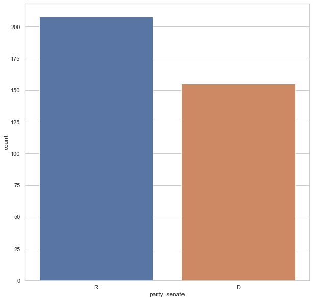

```python
# visualize the label variable
plt.figure(figsize=(10, 10))
g = sns.countplot(section_e_finale_df['party_senate'])
g.set_xticklabels(['R','D'])
plt.show()
```

```python
print("The ration in the dataset is:    ", len(section_e_finale_df.loc[ (section_e_finale_df['party_senate']=='R')]) /
      len(section_e_finale_df.loc[(section_e_finale_df['party_senate']=='D')]))
```

```
The ration in the dataset is:     1.3419354838709678
```

The Data is a bit imbalanced, there are 34% more samples which is a label is R. This is not a drastic imbalanced therfor we wont oversampeling the minorty class.

```python
#X Y separation
sec_e_X = section_e_finale_df.drop(['party_senate'],axis=1,inplace=False)
sec_e_Y = section_e_finale_df['party_senate']
sec_e_2022X = merged_states_df_2022.drop(['party_senate'],axis=1,inplace=False)
sec_e_2022Y = merged_states_df_2022['party_senate']
```

We will split the samples from 2000-2020 to train test datasets, after testing the model and achieving  
safetying results we will use it to predict our estimated 2022 samples, to see how well the model handle them  
In the future when the data for our X features will be available, it will be possible to predict again the 2022  
outcome.

```python
# split dataset into training set and test set
X_train_e, X_test_e, y_train_e, y_test_e = train_test_split(sec_e_X, sec_e_Y, test_size=0.2, random_state=RSEED)
```

### Section B - Dimensionality Reduction and Clustering

Dimensioning algorithm - We will now perform a dimension reduction algorithm so that we can perform  
clustering  
and visualize the results.  
The data we want to display consists of 9 features, ie it is represented in 9 dimensions.  
In order to make data virtualization we must reduce the dimensions to a maximum of 3.

#### T-SNE Algorithm

```python
from sklearn.manifold import TSNE

tsne = TSNE()
X_embedded = tsne.fit_transform(X_scaled)
```

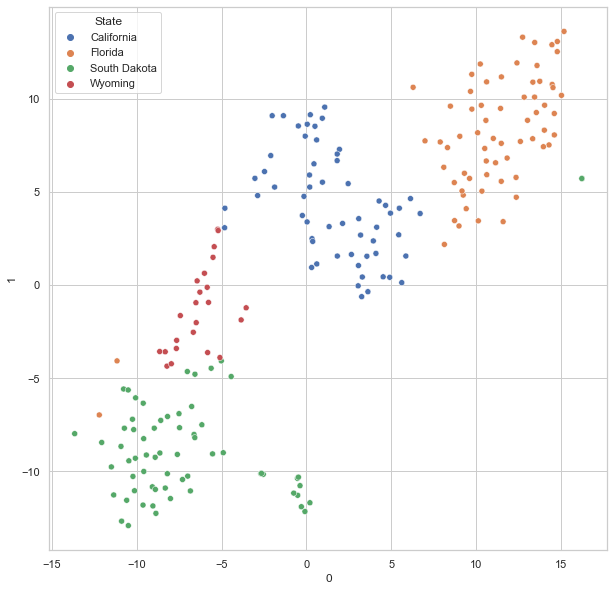

```python
X_embedded = pd.DataFrame(X_embedded)
X_embedded['State'] = state['State'].to_numpy()
plt.figure(figsize=(10, 10))
sns.scatterplot(data=X_embedded, x=0, y=1, hue='State')
```

As we can see we got a nice separation between the states, we can see that Wyoming and South Dakota relative close to each other, so they have similar values in the features we chose. Florida and California are relative close to each other.

#### PCA Algorithm

We chose to perform a PCA in order to lower the dimensions.  
We will select the 2 PCs that take up most of the overall variance of the data.  
Our goal is to represent the data in 2 dimensions and see how it is divided into clusters.

```python
from sklearn.decomposition import PCA
components = None
pca = PCA(n_components = components)
# perform PCA on the scaled data
pca.fit(X_scaled)
```

```
PCA()
```

```python
# print the explained variances
print("Variances (Percentage):")
print(pca.explained_variance_ratio_ * 100)
print()
```

```
Variances (Percentage):
[2.96320355e+01 2.20947160e+01 1.83010142e+01 1.39170221e+01
 6.49728282e+00 4.53841563e+00 4.06604507e+00 9.53372781e-01
 9.59157459e-05]
```

```python
print("Cumulative Variances (Percentage):")
print(pca.explained_variance_ratio_.cumsum() * 100)
print()
```

```
Cumulative Variances (Percentage):
[ 29.63203551  51.72675152  70.02776572  83.94478779  90.44207061
  94.98048623  99.0465313   99.99990408 100.        ]
```

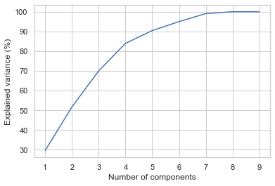

```python
# plot a scree plot
components = len(pca.explained_variance_ratio_) \
    if components is None else components
plt.plot(range(1,components+1),
         np.cumsum(pca.explained_variance_ratio_ * 100))
plt.xlabel("Number of components")
plt.ylabel("Explained variance (%)")
```

```
Cumulative Variances (Percentage):
[29.63203551 51.72675152 70.02776572 83.94478779 90.44207061 94.98048623
 99.0465313  99.99990408]
Number of components: 8
```

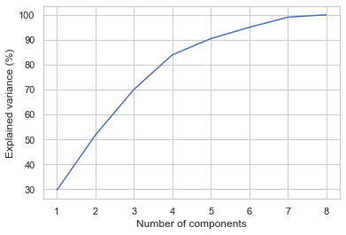

```python
from sklearn.decomposition import PCA
pca = PCA(n_components=8)
pca.fit(X_scaled)
print("Cumulative Variances (Percentage):")
print(np.cumsum(pca.explained_variance_ratio_ * 100))
components = len(pca.explained_variance_ratio_)
print(f'Number of components: {components}')
# Make the scree plot
plt.plot(range(1, components + 1), np.cumsum(pca.explained_variance_ratio_ * 100))
plt.xlabel("Number of components")
plt.ylabel("Explained variance (%)")
```

```python
pca_components = abs(pca.components_)
print(pca_components)
```

```
[[0.44776148 0.02620253 0.40952555 0.40212955 0.44774452 0.07245132
  0.46367873 0.1972356  0.0988915 ]
 [0.30903769 0.20381035 0.4757497  0.15250463 0.30927881 0.4784017
  0.31151803 0.3409489  0.27486433]
 [0.26734149 0.45171876 0.02912516 0.01438636 0.26695698 0.06080879
  0.13909774 0.51441191 0.60373165]
 [0.35030067 0.57682362 0.16572013 0.40874341 0.35048788 0.45476074
  0.08611889 0.079895   0.08112253]
 [0.05754592 0.10987303 0.14805129 0.63709416 0.05717446 0.51496568
  0.49505609 0.01149204 0.20769463]
 [0.02612209 0.37779144 0.0555855  0.18172851 0.02639746 0.41112904
  0.13616815 0.6869758  0.40034339]
 [0.06681569 0.51580426 0.13836422 0.39693105 0.06592764 0.33404766
  0.16357876 0.26498735 0.58298552]
 [0.03906457 0.0121096  0.73039925 0.22646692 0.03599774 0.09784145
  0.60894329 0.17765977 0.01769954]]
```

```python
print('Top 4 most important features in each component')
print('===============================================')
for row in range(pca_components.shape[0]):
    # get the indices of the top 4 values in each row
    temp = np.argpartition(-(pca_components[row]), 4)

    # sort the indices in descending order
    indices = temp[np.argsort((-pca_components[row])[temp])][:4]

    # print the top 4 feature names
    print(f'Component {row}: {section_b_df_for_scaling.columns[indices].to_list()}')
```

```
Top 4 most important features in each component
===============================================
Component 0: ['unemployment_rate_2016', 'Land Area', 'area_2010', 'unemployment_rate_2010']
Component 1: ['black_2010', 'unemployment_rate_2010', 'age_over_18_2019', 'unemployment_rate_2016']
Component 2: ['native_2010', 'age_over_18_2019', 'Male life expectancy (years)', 'Land Area']
Component 3: ['Male life expectancy (years)', 'black_2010', 'two_plus_races_2010', 'area_2010']
Component 4: ['two_plus_races_2010', 'black_2010', 'unemployment_rate_2016', 'native_2010']
Component 5: ['age_over_18_2019', 'black_2010', 'native_2010', 'Male life expectancy (years)']
Component 6: ['native_2010', 'Male life expectancy (years)', 'two_plus_races_2010', 'black_2010']
Component 7: ['unemployment_rate_2010', 'unemployment_rate_2016', 'two_plus_races_2010', 'age_over_18_2019']
```

```python
X_pca = pca.transform(X_scaled)
print(X_pca.shape)
print(X_pca)
```

```
(212, 8)
[[ 0.28566749 -1.06324012 -0.63827035 ...  0.25927638 -0.17847526
   0.24144431]
 [ 0.11694046 -0.25712307  0.28626529 ... -0.73220637  1.25150676
  -0.16518035]
 [ 0.07859517 -1.36100427 -0.803985   ... -0.98722387  0.30778883
  -0.14161981]
 ...
 [ 0.14839455  1.11724404  0.38832344 ...  1.1254512  -0.47774153
   0.14352073]
 [-0.17452185  0.98954419 -0.07144654 ...  0.21899417 -0.57951204
   0.29074367]
 [-0.51655373  1.02141919 -0.67174669 ... -0.04697759  0.02927651
   0.56884448]]
```

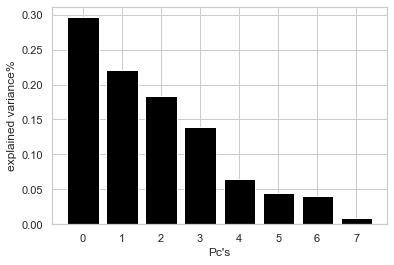

```python
#plot the explained variances
features = range(pca.n_components_)
plt.bar(features,pca.explained_variance_ratio_, color='black')
plt.xlabel("Pc's")
plt.ylabel("explained variance%")
```

```python
X_pca = pd.DataFrame(X_pca)
X_pca['State'] = state['State'].to_numpy()
```

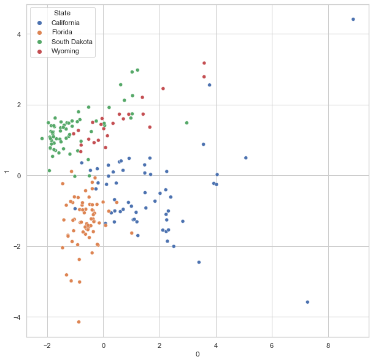

```python
plt.figure(figsize=(10, 10))
sns.scatterplot(data=X_pca, x=0, y=1, hue='State')
```